# 2-D VR racing task

Raphael Q. Gastrock

2026-01-07

# Overview

This document discusses detailed results for the 2D VR racing tablet experiments presented in the manuscript, with both Bayesian and frequentist analyses. We also show additional figures and statistical tests that support our findings.

# Set up the R enviornment

Our scripts require the use of certain packages. If some packages are not available in your own system, run the command:

```r
# Remove comment below
#install.packages(c('Reach', 'svglite', 'scales', 'lsr', 'BayesFactor', 'ez', 'emmeans', 'afex', 'bayestestR'))
```

We have written code that pre-processes the data, plots figures, and runs statistical tests. Import the sources below:

```r
source('ana/shared.R')
source('ana/downloadData.R')
source('ana/lapTime.R')
source('ana/Run2_lapTime.R')
source('ana/percentOnTrack.R')
source('ana/Run2_percentOnTrack.R')
source('ana/pathLength.R')
source('ana/Run2_pathLength.R')
source('ana/SpeedAccuracy.R')
source('ana/Run2_SpeedAccuracy.R')
source('ana/demeritPoints.R')
source('ana/Run2_demeritPoints.R')

#manuscript plots
source('ana/manuscriptPlots.R')
```

Then, we ensure that the data is available locally.

```r
# Remove comment below if data is not available locally.
#getBehaviorData()
```

# Study 1

Participants used a stylus on a digitizing tablet to control a race car through a track as quickly and accurately as possible. They received lap time and accuracy feedback. Lap times are measured by the time it takes to move from the start line to the finish line. Leaving the track limits affects accuracy, where the car turns red and participants hear a buzzing sound. In between trials, participants can rest at a pit stop (area between finish and start lines where the car is yellow).

It is unclear whether continued improvements in motor execution have the same underlying mechanisms as other types of motor learning. Therefore, we investigated retention and generalization patterns after lengthened practice with the racing task. Participants returned for a second session the next day, and we assessed for any further improvements in speed and accuracy. We expect to observe offline gains (performance improvement upon re-experiencing the task), which suggests robust retention patterns for motor execution. For generalization, we also tested performance on altered track orientation and reversed movement direction.

## Track orientations

We counterbalanced track orientation across participants, where the trained track orientation during session 1 was displayed on the monitor at either 0, 90, 180, or 270 degrees in polar coordinates. Participants practiced the task on their assigned orientation for 300 laps during session 1. In session 2, participants performed 30 laps with the same trained orientation (trained track), followed by 30 laps where the trained track was rotated by 180 degrees (rotated track), followed by 30 laps where the track was rotated by another 90 degrees and participants had to move through the track in reverse (reverse track), before ending the session with 30 laps on the trained track again (trained track).

Below we plot speed (lap times), accuracy (percent on track), and path length (trajectory) measures, according to track orientations.

### Speed: Session 1 and 2

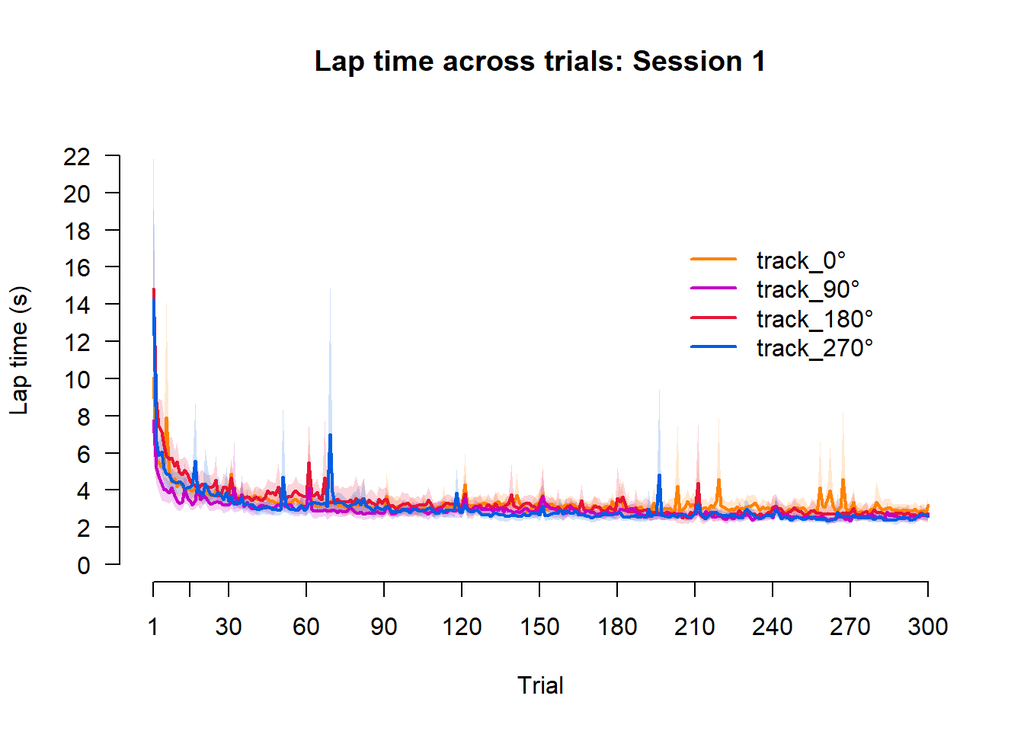

```r
plotLapTime()
```

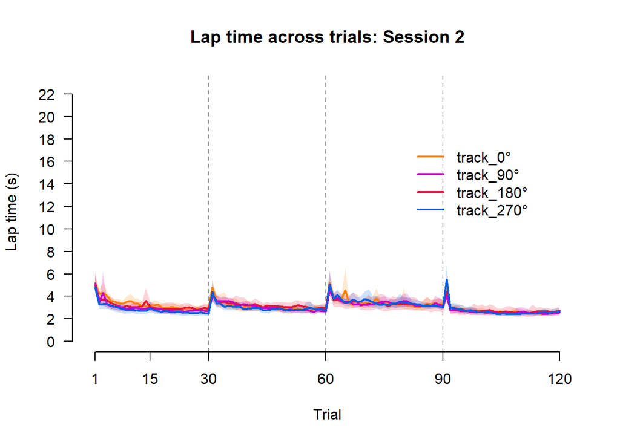

```r
plotS2LapTime()
```

### Accuracy: Session 1 and 2

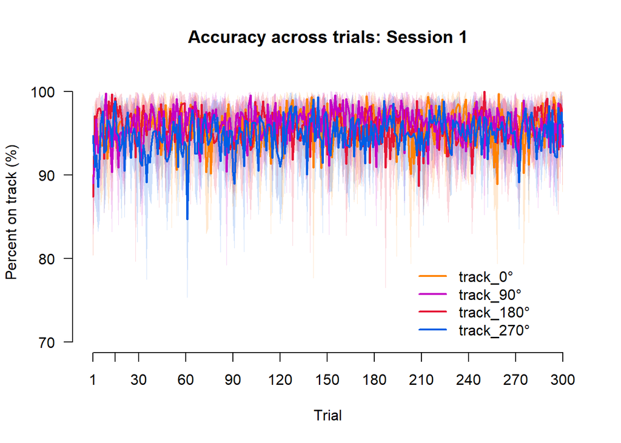

```r
plotAccuracy()
```

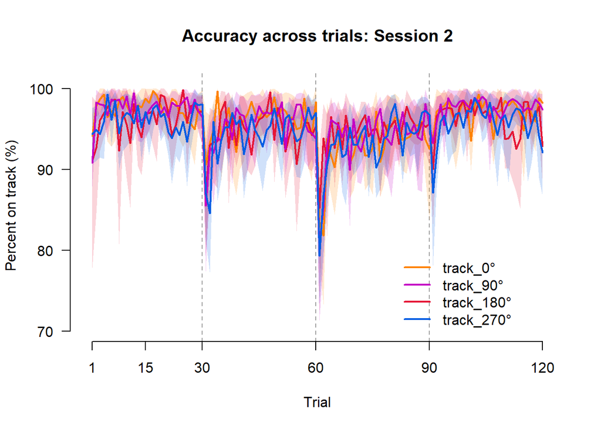

```r
plotS2Accuracy()
```

### Path Length: Session 1 and 2

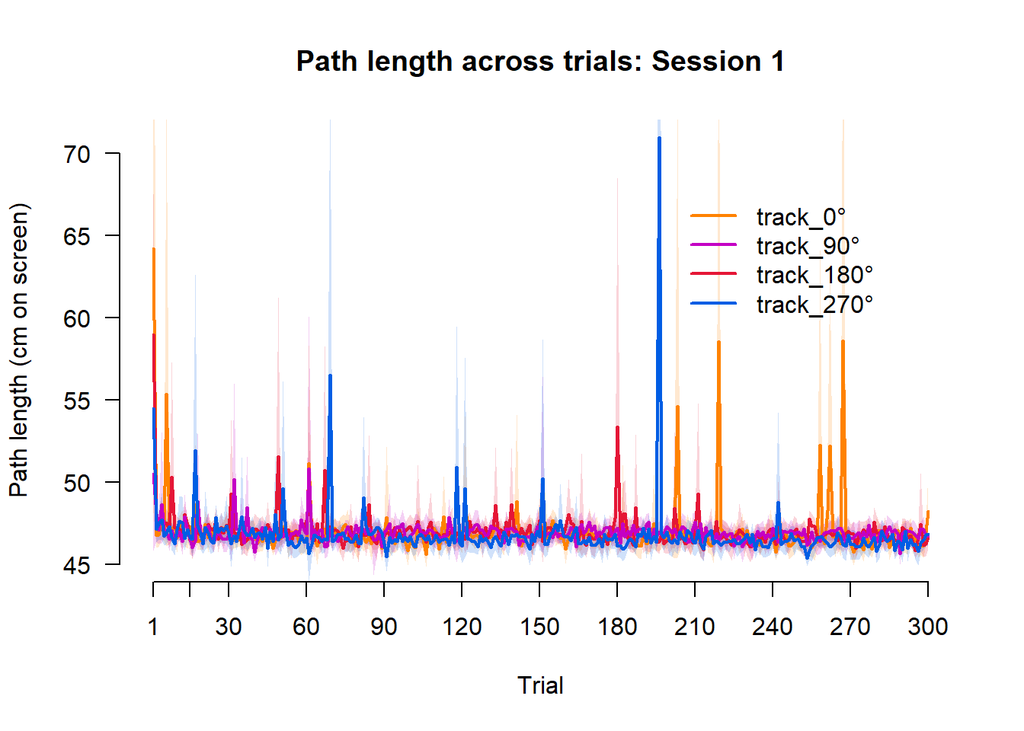

```r
plotPathLength()
```

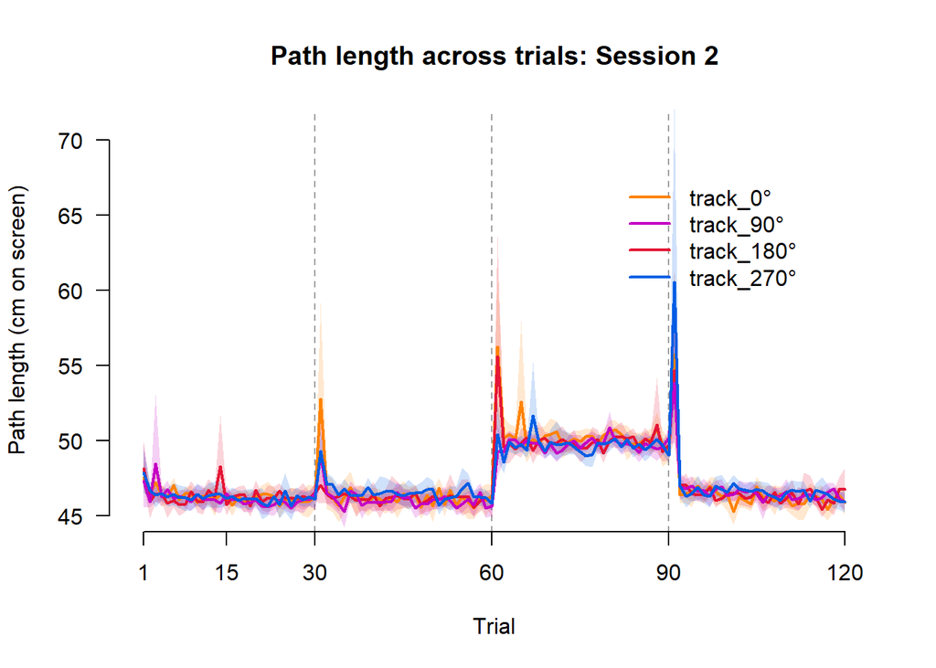

```r
plotS2PathLength()
```

Overall, we do not observe much differences for speed, accuracy, and path length when comparing performance across track orientations. Thus, we combine data from all orientations and analyze the data further.

## Speed (Lap times)

We first show lap times across both sessions.

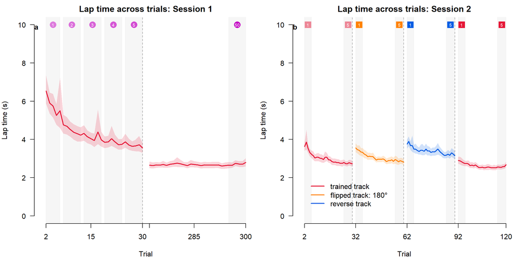

```r
plotFirstLastAllTrackAcrossSessionLapTime()
```

The plot below adds individual data to the previous plot.

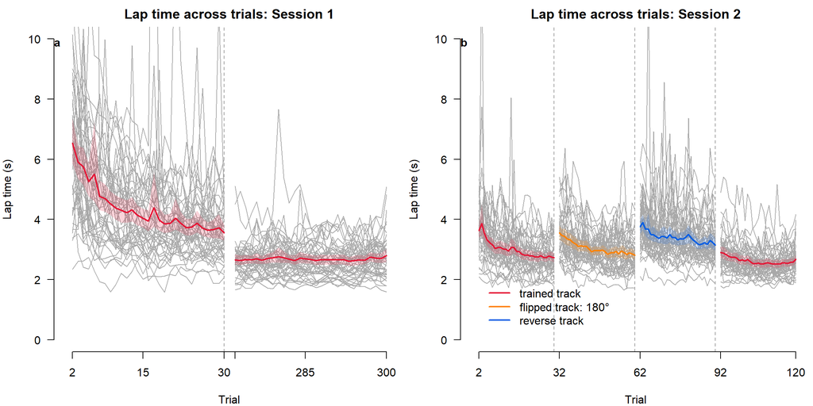

```r
plotIndFirstLastAllTrackAcrossSessionLapTime()
```

For all analyses we present, we compare performance across different blocks of trials across the two sessions. Each block consists of 30 trials. For session 1, participants encounter the same track orientation for 10 blocks of 30 trials (300 trials in total). In session 2, participants encounter different track orientations every block (4 blocks for 120 trials in total).

Given that improvements seem to occur quickly within each block (see figures above), we further subdivided each block into five sets of six trials, and compare these sets. Visual inspection of the data revealed substantial variability in the very first trial of session 1, as well as in the first trial of each block in session 2. These trials likely reflect participants’ initial engagement with the task in session 1 or how the start line changes across blocks in session 2. To minimize potential confounds arising from this variability, we exclude these first trials and instead include only the remaining five trials from the first set of each block.

For all statistical tests presented below, we include a frequentist and Bayesian version of the test.

### Retention (Lap times)

As speed improvements plateau toward the end of session 1, we examine performance retention when participants re-encounter the trained track in session 2. Specifically, we test for offline gains, defined as performance at the start of session 2 that is comparable to or better than performance at the end of session 1. Accordingly, we analyze the first and final sets from session 1, and the first set from session 2.

Session 1: first block, first set and last block, last set Session 2: first block, first set

#### Frequentist test

We perform a repeated measures one-way ANOVA to test for an effect across trial sets.

```r
retentionLapTimeANOVA()
```

```
## Lap times during first and last set in session 1 and first set in session 2:
## $ANOVA
##   Effect DFn DFd        F            p p<.05       ges
## 2    set   2  84 85.80604 5.027039e-21     * 0.5029433
##
## $`Mauchly's Test for Sphericity`
##   Effect         W            p p<.05
## 2    set 0.2748581 3.174861e-12     *
##
## $`Sphericity Corrections`
##   Effect       GGe       p[GG] p[GG]<.05       HFe        p[HF] p[HF]<.05
## 2    set 0.5796625 3.39678e-13         * 0.5858249 2.605937e-13         *
```

```r
retentionLapTimeComparisonMeans()
```

```
##  set      emmean     SE df lower.CL upper.CL
##  S1_first   5.72 0.3145 42     5.08     6.35
##  S1_last    2.68 0.0725 42     2.53     2.82
##  S2_1       3.52 0.1083 42     3.30     3.74
##  S2_2       2.75 0.0705 42     2.61     2.90
##
## Confidence level used: 0.95
```

```r
retentionLapTimeComparisonsEffSize()
```

```
##  contrast                              estimate     SE df t.ratio p.value
##  Session 1 Set 1 vs Session 1 Set Last   -3.039 0.2985 42 -10.182  <.0001
##  Session 1 Set 1 vs Session 2 Set 1      -2.196 0.2715 42  -8.089  <.0001
##  Session 1 Set Last vs Session 2 Set 1    0.843 0.0966 42   8.726  <.0001
##
## P value adjustment: bonferroni method for 3 tests
##                                contrast etasquared
## 1 Session 1 Set 1 vs Session 1 Set Last  0.7116752
## 2    Session 1 Set 1 vs Session 2 Set 1  0.6090762
## 3 Session 1 Set Last vs Session 2 Set 1  0.6444913
```

We observe a main effect of set. Follow-up comparisons indicate that this effect is driven by a difference between the first and last sets in session 1, consistent with within-session improvements. The first set in session 2 is lower than the first set in session 1, but not as low as the final set in session 1, suggesting partial retention of performance.

#### Bayesian test

```r
retentionLapTimeBayesANOVA()
```

```
## Lap times during first and last set in session 1 and first and set in session 2:
## Bayes factor analysis
## --------------
## [1] set + participant : 1.447016e+20 ±0.64%
##
## Against denominator:
##   dv ~ participant
## ---
## Bayes factor type: BFlinearModel, JZS
##
## Inclusion Bayes Factors (Model Averaged)
##
##             P(prior) P(posterior) Inclusion BF
## participant     1.00            1
## set             0.50            1     1.45e+20
##
## * Compared among: all models
## *    Priors odds: uniform-equal
```

```r
retentionLapTimeComparisonsBayesfollowup()
```

```
## Bayesian t-test - Session 1 Set 1 vs Session 1 Set Last:
## Bayes factor analysis
## --------------
## [1] Alt., r=0.707 : 12502604243 ±0%
##
## Against denominator:
##   Null, mu = 0
## ---
## Bayes factor type: BFoneSample, JZS
##
## Bayesian t-test - Session 1 Set 1 vs Session 2 Set 1:
## Bayes factor analysis
## --------------
## [1] Alt., r=0.707 : 25874810 ±0%
##
## Against denominator:
##   Null, mu = 0
## ---
## Bayes factor type: BFoneSample, JZS
##
## Bayesian t-test - Session 1 Set Last vs Session 2 Set 1:
## Bayes factor analysis
## --------------
## [1] Alt., r=0.707 : 177504833 ±0%
##
## Against denominator:
##   Null, mu = 0
## ---
## Bayes factor type: BFoneSample, JZS
##
## Bayesian t-test - Session 1 Set Last vs Session 2 Set 2:
## Bayes factor analysis
## --------------
## [1] Alt., r=0.707 : 0.2654867 ±0.05%
##
## Against denominator:
##   Null, mu = 0
## ---
## Bayes factor type: BFoneSample, JZS
```

Bayesian tests show the same findings as in the frequentist test.

### Generalization (Lap times)

Next, we compare performance between the novel track conditions and the original trained track. We analyze the first and final sets from session 1, and the first set of the rotated track from session 2.

trained track, Session 1: block 1, first set and block last, last set rotated track, Session 2: block 2, first set

#### Frequentist test

```r
genLapTimeANOVA()
```

```
## Lap times during first and last set in session 1 and first set of rotated track in session 2:
## $ANOVA
##   Effect DFn DFd        F            p p<.05       ges
## 2    set   2  84 78.31803 6.347172e-20     * 0.5085261
##
## $`Mauchly's Test for Sphericity`
##   Effect         W            p p<.05
## 2    set 0.3251791 9.965813e-11     *
##
## $`Sphericity Corrections`
##   Effect       GGe        p[GG] p[GG]<.05       HFe        p[HF] p[HF]<.05
## 2    set 0.5970788 7.386714e-13         * 0.6046778 5.430436e-13         *
```

```r
genLapTimeComparisonMeans()
```

```
##  set      emmean     SE df lower.CL upper.CL
##  S1_first   5.72 0.3145 42     5.08     6.35
##  S1_last    2.68 0.0725 42     2.53     2.82
##  S2_3       3.43 0.1057 42     3.22     3.64
##
## Confidence level used: 0.95
```

```r
genLapTimeComparisonsEffSize()
```

```
##  contrast                           estimate    SE df t.ratio p.value
##  Session 1 Set 1 vs Session 2 Set 3   -2.287 0.302 42  -7.563  <.0001
##  Session 1 Set 2 vs Session 2 Set 3    0.753 0.107 42   7.040  <.0001
##
## P value adjustment: bonferroni method for 2 tests
##                             contrast etasquared
## 1 Session 1 Set 1 vs Session 2 Set 3  0.5766121
## 2 Session 1 Set 2 vs Session 2 Set 3  0.5413016
```

We observe a main effect of set. Follow-up comparisons indicate that this effect is driven by a difference between both the first and last sets of Session 1, when each is compared with the first set of the rotated track.

#### Bayesian test

```r
genLapTimeBayesANOVA()
```

```
## Lap times during first and last set in session 1 and first set of rotated track in session 2:
## Bayes factor analysis
## --------------
## [1] set + participant : 4.754934e+19 ±0.59%
##
## Against denominator:
##   dv ~ participant
## ---
## Bayes factor type: BFlinearModel, JZS
##
## Inclusion Bayes Factors (Model Averaged)
##
##             P(prior) P(posterior) Inclusion BF
## participant     1.00            1
## set             0.50            1     4.75e+19
##
## * Compared among: all models
## *    Priors odds: uniform-equal
```

```r
genLapTimeComparisonsBayesfollowup()
```

```
## Bayesian t-test - Session 1 Set 1 vs Session 2 Set 3:
## Bayes factor analysis
## --------------
## [1] Alt., r=0.707 : 5141210 ±0%
##
## Against denominator:
##   Null, mu = 0
## ---
## Bayes factor type: BFoneSample, JZS
##
## Bayesian t-test - Session 1 Set 2 vs Session 2 Set 3:
## Bayes factor analysis
## --------------
## [1] Alt., r=0.707 : 1016611 ±0%
##
## Against denominator:
##   Null, mu = 0
## ---
## Bayes factor type: BFoneSample, JZS
```

Bayesian tests show the same findings as in the frequentist test.

### Generalization (Lap times): with Top up training as reference

We may also compare perfromance within Session 2. For these analyses, we use the first trained track block from Session 2 as the reference with which we compare the novel track conditions.

Next, we compare performance across blocks in session 2. We use the first block of trials with the trained track during session 2 as a baseline for comparing the other blocks. First, we compare how performance is affected when participants encounter the 180 degree rotated track orientation:

trained track, Session 2: block 1, first set and block 1, last set rotated track, Session 2: block 2, first set and block 2, last set

#### Frequentist test

```r
genTopUpLapTimeANOVA()
```

```
## Lap times during first block in session 2 and second block in session 2:
## $ANOVA
##   Effect DFn DFd        F            p p<.05       ges
## 2    set   3 126 39.99201 3.158042e-18     * 0.2338786
##
## $`Mauchly's Test for Sphericity`
##   Effect         W           p p<.05
## 2    set 0.6407081 0.002798051     *
##
## $`Sphericity Corrections`
##   Effect       GGe        p[GG] p[GG]<.05       HFe        p[HF] p[HF]<.05
## 2    set 0.8119553 3.058912e-15         * 0.8656176 4.292571e-16         *
```

```r
genTopUpLapTimeComparisonMeans()
```

```
##  set  emmean     SE df lower.CL upper.CL
##  S2_1   3.52 0.1083 42     3.30     3.74
##  S2_2   2.75 0.0705 42     2.61     2.90
##  S2_3   3.43 0.1057 42     3.22     3.64
##  S2_4   2.87 0.0850 42     2.70     3.05
##
## Confidence level used: 0.95
```

```r
genTopUpLapTimeComparisonsEffSize()
```

[output not shown]

We observe a main effect of set. Follow-up comparisons indicate that this effect is driven by a difference between the last set in the trained track and first set in the rotated track. However, this difference is not significant by the last set in the rotated track.

#### Bayesian test

```r
genTopUpLapTimeBayesANOVA()
```

```
## Lap times during first block in session 2 and second block in session 2:
## Bayes factor analysis
## --------------
## [1] set + participant : 1.61307e+15 ±0.64%
##
## Against denominator:
##   dv ~ participant
## ---
## Bayes factor type: BFlinearModel, JZS
##
## Inclusion Bayes Factors (Model Averaged)
##
##             P(prior) P(posterior) Inclusion BF
## participant     1.00         1.00
## set             0.50         1.00     1.61e+15
##
## * Compared among: all models
## *    Priors odds: uniform-equal
```

```r
genTopUpLapTimeComparisonsBayesfollowup()
```

```
## Bayesian t-test - Session 2 Set 1 vs Set 3:
## Bayes factor analysis
## --------------
## [1] Alt., r=0.707 : 0.2301454 ±0.05%
##
## Against denominator:
##   Null, mu = 0
## ---
## Bayes factor type: BFoneSample, JZS
##
## Bayesian t-test - Session 2 Set 2 vs Set 3:
## Bayes factor analysis
## --------------
## [1] Alt., r=0.707 : 855792867 ±0%
##
## Against denominator:
##   Null, mu = 0
## ---
## Bayes factor type: BFoneSample, JZS
##
## Bayesian t-test - Session 2 Set 2 vs Set 4:
## Bayes factor analysis
## --------------
## [1] Alt., r=0.707 : 0.6439544 ±0.03%
##
## Against denominator:
##   Null, mu = 0
## ---
## Bayes factor type: BFoneSample, JZS
```

Bayesian tests show the same findings as in the frequentist test.

### Reverse track (Lap times)

We analyze the first and final sets from session 1, and the first set of the reverse track from session 2.

trained track, Session 1: block 1, first set and block last, last set reverse track, Session 2: block 3, first set

#### Frequentist test

```r
revLapTimeANOVA()
```

```
## Lap times during first and last set in session 1 and first set of reverse track in session 2:
## $ANOVA
##   Effect DFn DFd        F            p p<.05       ges
## 2    set   2  84 83.12319 1.225412e-20     * 0.4947199
##
## $`Mauchly's Test for Sphericity`
##   Effect         W            p p<.05
## 2    set 0.2730765 2.778619e-12     *
##
## $`Sphericity Corrections`
##   Effect       GGe        p[GG] p[GG]<.05       HFe        p[HF] p[HF]<.05
## 2    set 0.5790644 5.863243e-13         * 0.5851782 4.531941e-13         *
```

```r
revLapTimeComparisonMeans()
```

```
##  set      emmean     SE df lower.CL upper.CL
##  S1_first   5.72 0.3145 42     5.08     6.35
##  S1_last    2.68 0.0725 42     2.53     2.82
##  S2_5       3.71 0.1098 42     3.49     3.93
##
## Confidence level used: 0.95
```

```r
revLapTimeComparisonsEffSize()
```

```
##  contrast                           estimate     SE df t.ratio p.value
##  Session 1 Set 1 vs Session 2 Set 5    -2.01 0.2722 42  -7.379  <.0001
##  Session 1 Set 2 vs Session 2 Set 5     1.03 0.0962 42  10.718  <.0001
##
## P value adjustment: bonferroni method for 2 tests
##                             contrast etasquared
## 1 Session 1 Set 1 vs Session 2 Set 5  0.5645584
## 2 Session 1 Set 2 vs Session 2 Set 5  0.7322888
```

We observe a main effect of set. Follow-up comparisons indicate that this effect is driven by a difference between both the first and last sets of Session 1, when each is compared with the first set of the reverse track.

#### Bayesian test

```r
revLapTimeBayesANOVA()
```

```
## Lap times during first and last set in session 1 and first set of reverse track in session 2:
## Bayes factor analysis
## --------------
## [1] set + participant : 4.962336e+19 ±0.82%
##
## Against denominator:
##   dv ~ participant
## ---
## Bayes factor type: BFlinearModel, JZS
##
## Inclusion Bayes Factors (Model Averaged)
##
##             P(prior) P(posterior) Inclusion BF
## participant     1.00            1
## set             0.50            1     4.96e+19
##
## * Compared among: all models
## *    Priors odds: uniform-equal
```

```r
revLapTimeComparisonsBayesfollowup()
```

```
## Bayesian t-test - Session 1 Set 1 vs Session 2 Set 5:
## Bayes factor analysis
## --------------
## [1] Alt., r=0.707 : 2912685 ±0%
##
## Against denominator:
##   Null, mu = 0
## ---
## Bayes factor type: BFoneSample, JZS
##
## Bayesian t-test - Session 1 Set 2 vs Session 2 Set 5:
## Bayes factor analysis
## --------------
## [1] Alt., r=0.707 : 56526077358 ±0%
##
## Against denominator:
##   Null, mu = 0
## ---
## Bayes factor type: BFoneSample, JZS
```

Bayesian tests show the same findings as in the frequentist test.

### Reverse track (Lap times): with Top Up training as reference

Next, we compare how performance is affected when participants move through the track in reverse:

#### Frequentist test

```r
revTopUpLapTimeANOVA()
```

```
## Lap times during first block in session 2 and third block in session 2:
## $ANOVA
##   Effect DFn DFd        F          p p<.05       ges
## 2    set   3 126 47.83438 1.0438e-20     * 0.2459975
##
## $`Mauchly's Test for Sphericity`
##   Effect         W          p p<.05
## 2    set 0.7385148 0.03041932     *
##
## $`Sphericity Corrections`
##   Effect       GGe        p[GG] p[GG]<.05       HFe       p[HF] p[HF]<.05
## 2    set 0.8332009 1.187457e-17         * 0.8901422 1.07344e-18         *
```

```r
revTopUpLapTimeComparisonMeans()
```

```
##  set  emmean     SE df lower.CL upper.CL
##  S2_1   3.52 0.1083 42     3.30     3.74
##  S2_2   2.75 0.0705 42     2.61     2.90
##  S2_5   3.71 0.1098 42     3.49     3.93
##  S2_6   3.22 0.0963 42     3.02     3.41
##
## Confidence level used: 0.95
```

```r
revTopUpLapTimeComparisonsEffSize()
```

[output not shown]

We observe a main effect of set. Follow-up comparisons indicate that this effect is driven by a difference between the last set in the trained track and first set in the reverse track. This difference remains up to the last set in the reverse track.

#### Bayesian test

```r
revTopUpLapTimeBayesANOVA()
```

```
## Lap times during first block in session 2 and third block in session 2:
## Bayes factor analysis
## --------------
## [1] set + participant : 3.913128e+17 ±1.1%
##
## Against denominator:
##   dv ~ participant
## ---
## Bayes factor type: BFlinearModel, JZS
##
## Inclusion Bayes Factors (Model Averaged)
##
##             P(prior) P(posterior) Inclusion BF
## participant     1.00            1
## set             0.50            1     3.91e+17
##
## * Compared among: all models
## *    Priors odds: uniform-equal
```

```r
revTopUpLapTimeComparisonsBayesfollowup()
```

```
## Bayesian t-test - Session 2 Set 1 vs Set 5:
## Bayes factor analysis
## --------------
## [1] Alt., r=0.707 : 0.8557826 ±0.03%
##
## Against denominator:
##   Null, mu = 0
## ---
## Bayes factor type: BFoneSample, JZS
##
## Bayesian t-test - Session 2 Set 2 vs Set 5:
## Bayes factor analysis
## --------------
## [1] Alt., r=0.707 : 205686256383 ±0%
##
## Against denominator:
##   Null, mu = 0
## ---
## Bayes factor type: BFoneSample, JZS
##
## Bayesian t-test - Session 2 Set 2 vs Set 6:
## Bayes factor analysis
## --------------
## [1] Alt., r=0.707 : 76504.86 ±0%
##
## Against denominator:
##   Null, mu = 0
## ---
## Bayes factor type: BFoneSample, JZS
```

Bayesian tests show the same findings as in the frequentist test.

### Trained track (Lap times)

#### T-test

We may simply compare the first set in the last trained track block with the last set of the first trained track block in session 2.

```r
trainLapTimeTtest()
```

```
## Session 2 Set 2 vs. Session 2 Set 7:
##
##  Paired t-test
##
## data:  subdat1$dv and subdat2$dv
## t = -0.90604, df = 42, p-value = 0.3701
## alternative hypothesis: true mean difference is not equal to 0
## 95 percent confidence interval:
##  -0.23719372  0.09020468
## sample estimates:
## mean difference
##     -0.07349452
##
## Effect Size - Cohen d:
## [1] 0.1427153
```

We find no evidence of a difference between the two trial sets.

Next, we compare performance between the first and last blocks in session 2, to assess whether the other track conditions has interfered with learning in the trained track.

trained track, Session 2: block 1, first set and block 1, last set trained track, Session 2: block 4, first set and block 4, last set

#### Frequentist test

```r
trainLapTimeANOVA()
```

```
## Lap times during first block in session 2 and last block in session 2:
## $ANOVA
##   Effect DFn DFd        F            p p<.05       ges
## 2    set   3 126 56.92978 2.490497e-23     * 0.3059848
##
## $`Mauchly's Test for Sphericity`
##   Effect         W            p p<.05
## 2    set 0.4470618 4.194549e-06     *
##
## $`Sphericity Corrections`
##   Effect       GGe        p[GG] p[GG]<.05       HFe       p[HF] p[HF]<.05
## 2    set 0.7157491 2.206887e-17         * 0.7555449 3.23602e-18         *
```

```r
trainLapTimeComparisonMeans()
```

```
##  set  emmean     SE df lower.CL upper.CL
##  S2_1   3.52 0.1083 42     3.30     3.74
##  S2_2   2.75 0.0705 42     2.61     2.90
##  S2_7   2.83 0.0858 42     2.65     3.00
##  S2_8   2.58 0.0595 42     2.46     2.70
##
## Confidence level used: 0.95
```

```r
trainLapTimeComparisonsEffSize()
```

```
##  contrast                           estimate     SE df t.ratio p.value
##  Session 2 Set 1 vs Session 2 Set 7  -0.6940 0.0887 42  -7.823  <.0001
##  Session 2 Set 2 vs Session 2 Set 7   0.0735 0.0811 42   0.906  1.0000
##  Session 2 Set 2 vs Session 2 Set 8  -0.1705 0.0667 42  -2.556  0.0429
##
## P value adjustment: bonferroni method for 3 tests
##                             contrast etasquared
## 1 Session 2 Set 1 vs Session 2 Set 7 0.59299503
## 2 Session 2 Set 2 vs Session 2 Set 7 0.01917072
## 3 Session 2 Set 2 vs Session 2 Set 8 0.13463383
```

We observe a main effect of set. Follow-up comparisons indicate that this effect is driven by a difference between the first set in each block, where the first set in the last block shows decreased lap times. Interestingly, performance seems to continue to improve, as the last set in the last block also shows a significant difference compared to the last set in the first block.

#### Bayesian test

```r
trainLapTimeBayesANOVA()
```

```
## Lap times during first block in session 2 and last block in session 2:
## Bayes factor analysis
## --------------
## [1] set + participant : 1.623759e+20 ±0.63%
##
## Against denominator:
##   dv ~ participant
## ---
## Bayes factor type: BFlinearModel, JZS
##
## Inclusion Bayes Factors (Model Averaged)
##
##             P(prior) P(posterior) Inclusion BF
## participant     1.00            1
## set             0.50            1     1.62e+20
##
## * Compared among: all models
## *    Priors odds: uniform-equal
```

```r
trainLapTimeComparisonsBayesfollowup()
```

```
## Bayesian t-test - Session 2 Set 1 vs Set 7:
## Bayes factor analysis
## --------------
## [1] Alt., r=0.707 : 11432528 ±0%
##
## Against denominator:
##   Null, mu = 0
## ---
## Bayes factor type: BFoneSample, JZS
##
## Bayesian t-test - Session 2 Set 2 vs Set 7:
## Bayes factor analysis
## --------------
## [1] Alt., r=0.707 : 0.2423259 ±0.05%
##
## Against denominator:
##   Null, mu = 0
## ---
## Bayes factor type: BFoneSample, JZS
##
## Bayesian t-test - Session 2 Set 2 vs Set 8:
## Bayes factor analysis
## --------------
## [1] Alt., r=0.707 : 2.931116 ±0%
##
## Against denominator:
##   Null, mu = 0
## ---
## Bayes factor type: BFoneSample, JZS
```

Bayesian tests show the same findings as in the frequentist test, except when comparing the last sets in each block where the effect is small.

## Accuracy (Percent on Track)

### Demerit Points

One measure of accuracy will be to check for changes in the amount of demerit points that participants received throughout the task. Demerit points inform us of the number of times that participants leave the track boundaries, but not for how long within a given lap. Thus, we share means and standard deviations of demerit points across blocks and sessions here, but use percentage on track for the other analyses below as it is a more informative measure of accuracy.

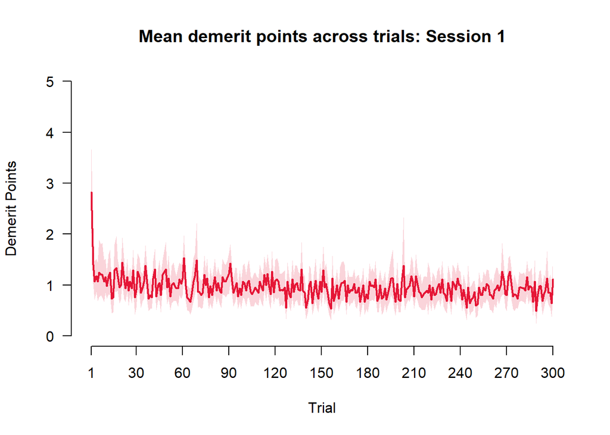

```r
plotAllTrackPts()
```

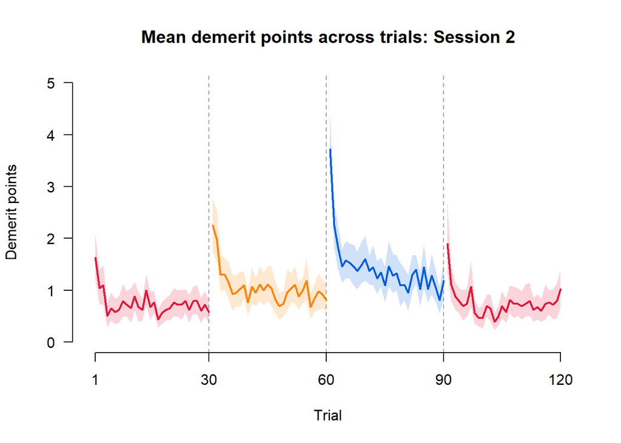

```r
plotS2AllTrackPts()
```

Demerit points do not change that much after the first couple of trials (note that trial 1 is shown here but not included in the mean and SD values below).

```r
getDemPtsSession1()
```

```
## Mean for trial set 1:
## [1] 1.204444
## SD for trial set 1:
## [1] 0.8805875
## Mean for trial set 50:
## [1] 0.9148148
## SD for trial set 50:
## [1] 0.5920584
```

```r
getDemPtsSession2()
```

```
## Mean for trial set 1:
## [1] 0.7767442
## SD for trial set 1:
## [1] 0.6034966
## Mean for trial set 2:
## [1] 0.6899225
## SD for trial set 2:
## [1] 0.4403303
## Mean for trial set 3:
## [1] 1.348837
## SD for trial set 3:
## [1] 0.7685398
## Mean for trial set 4:
## [1] 0.9069767
## SD for trial set 4:
## [1] 0.5879099
## Mean for trial set 5:
## [1] 1.734884
## SD for trial set 5:
## [1] 0.7655946
## Mean for trial set 6:
## [1] 1.143411
## SD for trial set 6:
## [1] 0.5202022
## Mean for trial set 7:
## [1] 0.8465116
## SD for trial set 7:
## [1] 0.5360121
## Mean for trial set 8:
## [1] 0.7751938
## SD for trial set 8:
## [1] 0.4407841
```

Next, we repeat the same analyses steps as in the previous section, but now use Percentage on Track (Accuracy) as the dependent variable.

### Retention (Accuracy)

Session 1: first block, first set and last block, last set Session 2: first block, first set

#### Frequentist test

We perform a repeated measures one-way ANOVA to test for an effect across trial sets.

```r
retentionAccuracyANOVA()
```

```
## Accuracy during first and last set in session 1 and first set in session 2:
## $ANOVA
##   Effect DFn DFd        F           p p<.05        ges
## 2    set   2  84 4.990904 0.008951391     * 0.06336293
##
## $`Mauchly's Test for Sphericity`
##   Effect         W           p p<.05
## 2    set 0.7944224 0.008934191     *
##
## $`Sphericity Corrections`
##   Effect       GGe      p[GG] p[GG]<.05       HFe      p[HF] p[HF]<.05
## 2    set 0.8294779 0.01364243         * 0.8593617 0.01266922         *
```

```r
retentionAccuracyComparisonMeans()
```

```
##  set      emmean    SE df lower.CL upper.CL
##  S1_first   94.4 0.763 42     92.9     96.0
##  S1_last    95.4 0.527 42     94.4     96.5
##  S2_1       96.9 0.494 42     95.9     97.9
##  S2_2       97.0 0.393 42     96.2     97.8
##
## Confidence level used: 0.95
```

```r
retentionAccuracyComparisonsEffSize()
```

```
##  contrast                              estimate    SE df t.ratio p.value
##  Session 1 Set 1 vs Session 1 Set Last     1.00 0.937 42   1.071  0.8710
##  Session 1 Set 1 vs Session 2 Set 1        2.49 0.789 42   3.156  0.0089
##  Session 1 Set Last vs Session 2 Set 1     1.49 0.620 42   2.394  0.0636
##
## P value adjustment: bonferroni method for 3 tests
##                                contrast etasquared
## 1 Session 1 Set 1 vs Session 1 Set Last 0.02657938
## 2    Session 1 Set 1 vs Session 2 Set 1 0.19165454
## 3 Session 1 Set Last vs Session 2 Set 1 0.12011524
```

We observe a main effect of set. Follow-up comparisons reveal that this effect is driven by a difference between the first set in session 1 and the first set in session 2. Notably, there is no difference between the last set in session 1 and the first set in session 2, indicating that accuracy at the start of session 2 is comparable to that achieved at the end of the previous training day.

#### Bayesian test

```r
retentionAccuracyBayesANOVA()
```

```
## Accuracy during first and last set in session 1 and first set in session 2:
## Bayes factor analysis
## --------------
## [1] set + participant : 5.826874 ±1.2%
##
## Against denominator:
##   dv ~ participant
## ---
## Bayes factor type: BFlinearModel, JZS
##
## Inclusion Bayes Factors (Model Averaged)
##
##             P(prior) P(posterior) Inclusion BF
## participant     1.00         1.00
## set             0.50         0.85         5.83
##
## * Compared among: all models
## *    Priors odds: uniform-equal
```

```r
retentionAccuracyComparisonsBayesfollowup()
```

```
## Bayesian t-test - Session 1 Set 1 vs Session 1 Set Last:
## Bayes factor analysis
## --------------
## [1] Alt., r=0.707 : 0.2817213 ±0.05%
##
## Against denominator:
##   Null, mu = 0
## ---
## Bayes factor type: BFoneSample, JZS
##
## Bayesian t-test - Session 1 Set 1 vs Session 2 Set 1:
## Bayes factor analysis
## --------------
## [1] Alt., r=0.707 : 11.42739 ±0%
##
## Against denominator:
##   Null, mu = 0
## ---
## Bayes factor type: BFoneSample, JZS
##
## Bayesian t-test - Session 1 Set Last vs Session 2 Set 1:
## Bayes factor analysis
## --------------
## [1] Alt., r=0.707 : 2.103644 ±0.01%
##
## Against denominator:
##   Null, mu = 0
## ---
## Bayes factor type: BFoneSample, JZS
##
## Bayesian t-test - Session 1 Set Last vs Session 2 Set 2:
## Bayes factor analysis
## --------------
## [1] Alt., r=0.707 : 3.263278 ±0%
##
## Against denominator:
##   Null, mu = 0
## ---
## Bayes factor type: BFoneSample, JZS
```

Bayesian tests show the same findings as in the frequentist test.

### Generalization (Accuracy)

Next, we compare performance between the novel track conditions and the original trained track. We analyze the first and final sets from session 1, and the first set of the rotated track from session 2.

trained track, Session 1: block 1, first set and block last, last set rotated track, Session 2: block 2, first set

#### Frequentist test

```r
genAccuracyANOVA()
```

```
## Accuracy during first and last set in session 1 and first set of rotated track in session 2:
## $ANOVA
##   Effect DFn DFd        F         p p<.05        ges
## 2    set   2  84 1.904015 0.1553432       0.02364817
##
## $`Mauchly's Test for Sphericity`
##   Effect         W         p p<.05
## 2    set 0.9390139 0.2752812
##
## $`Sphericity Corrections`
##   Effect       GGe     p[GG] p[GG]<.05       HFe     p[HF] p[HF]<.05
## 2    set 0.9425194 0.1580445           0.9853764 0.1560325
```

```r
genAccuracyComparisonMeans()
```

```
##  set      emmean    SE df lower.CL upper.CL
##  S1_first   94.4 0.763 42     92.9     96.0
##  S1_last    95.4 0.527 42     94.4     96.5
##  S2_3       93.8 0.716 42     92.3     95.2
##
## Confidence level used: 0.95
```

We do not observe a main effect of set.

#### Bayesian test

```r
genAccuracyBayesANOVA()
```

```
## Accuracy during first and last set in session 1 and first set of rotated track in session 2:
## Bayes factor analysis
## --------------
## [1] set + participant : 0.3822117 ±0.64%
##
## Against denominator:
##   dv ~ participant
## ---
## Bayes factor type: BFlinearModel, JZS
##
## Inclusion Bayes Factors (Model Averaged)
##
##             P(prior) P(posterior) Inclusion BF
## participant     1.00         1.00
## set             0.50         0.28        0.382
##
## * Compared among: all models
## *    Priors odds: uniform-equal
```

```r
genAccuracyComparisonsBayesfollowup()
```

```
## Bayesian t-test - Session 1 Set 1 vs Session 2 Set 3:
## Bayes factor analysis
## --------------
## [1] Alt., r=0.707 : 0.2155163 ±0.05%
##
## Against denominator:
##   Null, mu = 0
## ---
## Bayes factor type: BFoneSample, JZS
##
## Bayesian t-test - Session 1 Set 2 vs Session 2 Set 3:
## Bayes factor analysis
## --------------
## [1] Alt., r=0.707 : 1.454772 ±0.02%
##
## Against denominator:
##   Null, mu = 0
## ---
## Bayes factor type: BFoneSample, JZS
```

Bayesian tests show the same findings as in the frequentist test.

### Generalization (Accuracy): with Top Up training as reference

Next, we compare how performance is affected when participants encounter the track rotated by 180 degrees:

trained track, Session 2: block 1, first set and block 1, last set rotated track, Session 2: block 2, first set and block 2, last set

#### Frequentist test

```r
genTopUpAccuracyANOVA()
```

```
## Accuracy during first block in session 2 and second block in session 2:
## $ANOVA
##   Effect DFn DFd        F            p p<.05       ges
## 2    set   3 126 12.29443 4.153907e-07     * 0.1214395
##
## $`Mauchly's Test for Sphericity`
##   Effect        W           p p<.05
## 2    set 0.646555 0.003274217     *
##
## $`Sphericity Corrections`
##   Effect       GGe       p[GG] p[GG]<.05      HFe        p[HF] p[HF]<.05
## 2    set 0.7819346 5.33701e-06         * 0.831098 2.996753e-06         *
```

```r
genTopUpAccuracyComparisonMeans()
```

```
##  set  emmean    SE df lower.CL upper.CL
##  S2_1   96.9 0.494 42     95.9     97.9
##  S2_2   97.0 0.393 42     96.2     97.8
##  S2_3   93.8 0.716 42     92.3     95.2
##  S2_4   95.3 0.535 42     94.3     96.4
##
## Confidence level used: 0.95
```

```r
genTopUpAccuracyComparisonsEffSize()
```

[output not shown]

We observe a main effect of set. Follow-up comparisons indicate that this effect is driven by a difference between the first and last sets in the trained track and first set in the rotated track. Furthermore, the last set in the rotated track also differs from the last set in the trained track.

#### Bayesian test

```r
genTopUpAccuracyBayesANOVA()
```

```
## Accuracy during first block in session 2 and second block in session 2:
## Bayes factor analysis
## --------------
## [1] set + participant : 41592.49 ±0.53%
##
## Against denominator:
##   dv ~ participant
## ---
## Bayes factor type: BFlinearModel, JZS
##
## Inclusion Bayes Factors (Model Averaged)
##
##             P(prior) P(posterior) Inclusion BF
## participant     1.00         1.00
## set             0.50         1.00     4.16e+04
##
## * Compared among: all models
## *    Priors odds: uniform-equal
```

```r
genTopUpAccuracyComparisonsBayesfollowup()
```

```
## Bayesian t-test - Session 2 Set 1 vs Set 3:
## Bayes factor analysis
## --------------
## [1] Alt., r=0.707 : 61697.06 ±0%
##
## Against denominator:
##   Null, mu = 0
## ---
## Bayes factor type: BFoneSample, JZS
##
## Bayesian t-test - Session 2 Set 2 vs Set 3:
## Bayes factor analysis
## --------------
## [1] Alt., r=0.707 : 398.6899 ±0%
##
## Against denominator:
##   Null, mu = 0
## ---
## Bayes factor type: BFoneSample, JZS
##
## Bayesian t-test - Session 2 Set 2 vs Set 4:
## Bayes factor analysis
## --------------
## [1] Alt., r=0.707 : 8.305633 ±0%
##
## Against denominator:
##   Null, mu = 0
## ---
## Bayes factor type: BFoneSample, JZS
```

Bayesian tests show the same findings as in the frequentist test.

### Reverse track (Accuracy)

We analyze the first and final sets from session 1, and the first set of the reverse track from session 2.

trained track, Session 1: block 1, first set and block last, last set reverse track, Session 2: block 3, first set

#### Frequentist test

```r
revAccuracyANOVA()
```

```
## Accuracy during first and last set in session 1 and first set of reverse track in session 2:
## $ANOVA
##   Effect DFn DFd        F          p p<.05        ges
## 2    set   2  84 7.805927 0.00077744     * 0.09069141
##
## $`Mauchly's Test for Sphericity`
##   Effect         W         p p<.05
## 2    set 0.9443095 0.3089185
##
## $`Sphericity Corrections`
##   Effect       GGe        p[GG] p[GG]<.05       HFe        p[HF] p[HF]<.05
## 2    set 0.9472473 0.0009897964         * 0.9906778 0.0008113083         *
```

```r
revAccuracyComparisonMeans()
```

```
##  set      emmean    SE df lower.CL upper.CL
##  S1_first   94.4 0.763 42     92.9     96.0
##  S1_last    95.4 0.527 42     94.4     96.5
##  S2_5       92.2 0.688 42     90.8     93.6
##
## Confidence level used: 0.95
```

```r
revAccuracyComparisonsEffSize()
```

```
##  contrast                           estimate    SE df t.ratio p.value
##  Session 1 Set 1 vs Session 2 Set 5    -2.26 0.771 42  -2.929  0.0109
##  Session 1 Set 2 vs Session 2 Set 5    -3.26 0.821 42  -3.976  0.0005
##
## P value adjustment: bonferroni method for 2 tests
##                             contrast etasquared
## 1 Session 1 Set 1 vs Session 2 Set 5  0.1696166
## 2 Session 1 Set 2 vs Session 2 Set 5  0.2734297
```

We observe a main effect of set. Follow-up comparisons indicate that this effect is driven by a difference between both the first and last sets of Session 1, when each is compared with the first set of the reverse track.

#### Bayesian test

```r
revAccuracyBayesANOVA()
```

```
## Accuracy during first and last set in session 1 and first set of reverse track in session 2:
## Bayes factor analysis
## --------------
## [1] set + participant : 54.10737 ±0.75%
##
## Against denominator:
##   dv ~ participant
## ---
## Bayes factor type: BFlinearModel, JZS
##
## Inclusion Bayes Factors (Model Averaged)
##
##             P(prior) P(posterior) Inclusion BF
## participant     1.00         1.00
## set             0.50         0.98        54.11
##
## * Compared among: all models
## *    Priors odds: uniform-equal
```

```r
revAccuracyComparisonsBayesfollowup()
```

```
## Bayesian t-test - Session 1 Set 1 vs Session 2 Set 5:
## Bayes factor analysis
## --------------
## [1] Alt., r=0.707 : 6.677724 ±0%
##
## Against denominator:
##   Null, mu = 0
## ---
## Bayes factor type: BFoneSample, JZS
##
## Bayesian t-test - Session 1 Set 2 vs Session 2 Set 5:
## Bayes factor analysis
## --------------
## [1] Alt., r=0.707 : 96.55368 ±0%
##
## Against denominator:
##   Null, mu = 0
## ---
## Bayes factor type: BFoneSample, JZS
```

Bayesian tests show the same findings as in the frequentist test.

### Reverse track (Accuracy): with Top Up training as reference

Next, we compare how performance is affected when participants move through the track in reverse:

#### Frequentist test

```r
revTopUpAccuracyANOVA()
```

```
## Accuracy during first block in session 2 and third block in session 2:
## $ANOVA
##   Effect DFn DFd        F            p p<.05       ges
## 2    set   3 126 26.39426 2.580542e-13     * 0.2468057
##
## $`Mauchly's Test for Sphericity`
##   Effect         W         p p<.05
## 2    set 0.8574413 0.2815687
##
## $`Sphericity Corrections`
##   Effect       GGe        p[GG] p[GG]<.05       HFe        p[HF] p[HF]<.05
## 2    set 0.9123152 2.406095e-12         * 0.9821673 4.062574e-13         *
```

```r
revTopUpAccuracyComparisonMeans()
```

```
##  set  emmean    SE df lower.CL upper.CL
##  S2_1   96.9 0.494 42     95.9     97.9
##  S2_2   97.0 0.393 42     96.2     97.8
##  S2_5   92.2 0.688 42     90.8     93.6
##  S2_6   95.2 0.485 42     94.2     96.2
##
## Confidence level used: 0.95
```

```r
revTopUpAccuracyComparisonsEffSize()
```

[output not shown]

We observe a main effect of set. Follow-up comparisons indicate that accuracy in the reverse track is lower than in the trained track.

#### Bayesian test

```r
revTopUpAccuracyBayesANOVA()
```

```
## Accuracy during first block in session 2 and third block in session 2:
## Bayes factor analysis
## --------------
## [1] set + participant : 59917522230 ±1.09%
##
## Against denominator:
##   dv ~ participant
## ---
## Bayes factor type: BFlinearModel, JZS
##
## Inclusion Bayes Factors (Model Averaged)
##
##             P(prior) P(posterior) Inclusion BF
## participant     1.00         1.00
## set             0.50         1.00     5.99e+10
##
## * Compared among: all models
## *    Priors odds: uniform-equal
```

```r
revTopUpAccuracyComparisonsBayesfollowup()
```

```
## Bayesian t-test - Session 2 Set 1 vs Set 5:
## Bayes factor analysis
## --------------
## [1] Alt., r=0.707 : 344038.9 ±0%
##
## Against denominator:
##   Null, mu = 0
## ---
## Bayes factor type: BFoneSample, JZS
##
## Bayesian t-test - Session 2 Set 2 vs Set 5:
## Bayes factor analysis
## --------------
## [1] Alt., r=0.707 : 4963320 ±0%
##
## Against denominator:
##   Null, mu = 0
## ---
## Bayes factor type: BFoneSample, JZS
##
## Bayesian t-test - Session 2 Set 2 vs Set 6:
## Bayes factor analysis
## --------------
## [1] Alt., r=0.707 : 8.79806 ±0%
##
## Against denominator:
##   Null, mu = 0
## ---
## Bayes factor type: BFoneSample, JZS
```

Bayesian tests show the same findings as in the frequentist test.

### Trained track (Accuracy)

#### T-test

We may simply compare the first set in the last trained track block with the last set of the first trained track block in session 2.

```r
trainAccuracyTtest()
```

```
## Session 2 Set 2 vs. Session 2 Set 7:
##
##  Paired t-test
##
## data:  subdat1$dv and subdat2$dv
## t = 0.9307, df = 42, p-value = 0.3573
## alternative hypothesis: true mean difference is not equal to 0
## 95 percent confidence interval:
##  -0.5639731  1.5293869
## sample estimates:
## mean difference
##       0.4827069
##
## Effect Size - Cohen d:
## [1] 0.1689368
```

We find no evidence of a difference between the two trial sets.

Next, we compare performance between the first and last blocks in session 2, to assess whether the other track conditions has interfered with learning in the trained track.

trained track, Session 2: block 1, first set and block 1, last set trained track, Session 2: block 4, first set and block 4, last set

#### Frequentist test

```r
trainAccuracyANOVA()
```

```
## Accuracy during first block in session 2 and last block in session 2:
## $ANOVA
##   Effect DFn DFd         F         p p<.05         ges
## 2    set   3 126 0.6503013 0.5841944       0.008173978
##
## $`Mauchly's Test for Sphericity`
##   Effect         W        p p<.05
## 2    set 0.9550382 0.866409
##
## $`Sphericity Corrections`
##   Effect       GGe     p[GG] p[GG]<.05      HFe     p[HF] p[HF]<.05
## 2    set 0.9689435 0.5795023           1.048723 0.5841944
```

```r
trainAccuracyComparisonMeans()
```

```
##  set  emmean    SE df lower.CL upper.CL
##  S2_1   96.9 0.494 42     95.9     97.9
##  S2_2   97.0 0.393 42     96.2     97.8
##  S2_7   96.5 0.474 42     95.5     97.5
##  S2_8   96.4 0.406 42     95.6     97.2
##
## Confidence level used: 0.95
```

We do not observe an effect of set, suggesting no accuracy differences between the first and last blocks in session 2.

#### Bayesian test

```r
trainAccuracyBayesANOVA()
```

```
## Accuracy during first block in session 2 and last block in session 2:
## Bayes factor analysis
## --------------
## [1] set + participant : 0.0647305 ±0.54%
##
## Against denominator:
##   dv ~ participant
## ---
## Bayes factor type: BFlinearModel, JZS
##
## Inclusion Bayes Factors (Model Averaged)
##
##             P(prior) P(posterior) Inclusion BF
## participant     1.00         1.00
## set             0.50         0.06        0.065
##
## * Compared among: all models
## *    Priors odds: uniform-equal
```

```r
trainAccuracyComparisonsBayesfollowup()
```

```
## Bayesian t-test - Session 2 Set 1 vs Set 7:
## Bayes factor analysis
## --------------
## [1] Alt., r=0.707 : 0.2104165 ±0.05%
##
## Against denominator:
##   Null, mu = 0
## ---
## Bayes factor type: BFoneSample, JZS
##
## Bayesian t-test - Session 2 Set 2 vs Set 7:
## Bayes factor analysis
## --------------
## [1] Alt., r=0.707 : 0.2474683 ±0.05%
##
## Against denominator:
##   Null, mu = 0
## ---
## Bayes factor type: BFoneSample, JZS
##
## Bayesian t-test - Session 2 Set 2 vs Set 8:
## Bayes factor analysis
## --------------
## [1] Alt., r=0.707 : 0.3232233 ±0.04%
##
## Against denominator:
##   Null, mu = 0
## ---
## Bayes factor type: BFoneSample, JZS
```

Bayesian tests show the same findings as in the frequentist test.

## Speed and Accuracy

We plot speed and accuracy functions below. Note that both speed and accuracy measures improve with training within blocks and across sessions.

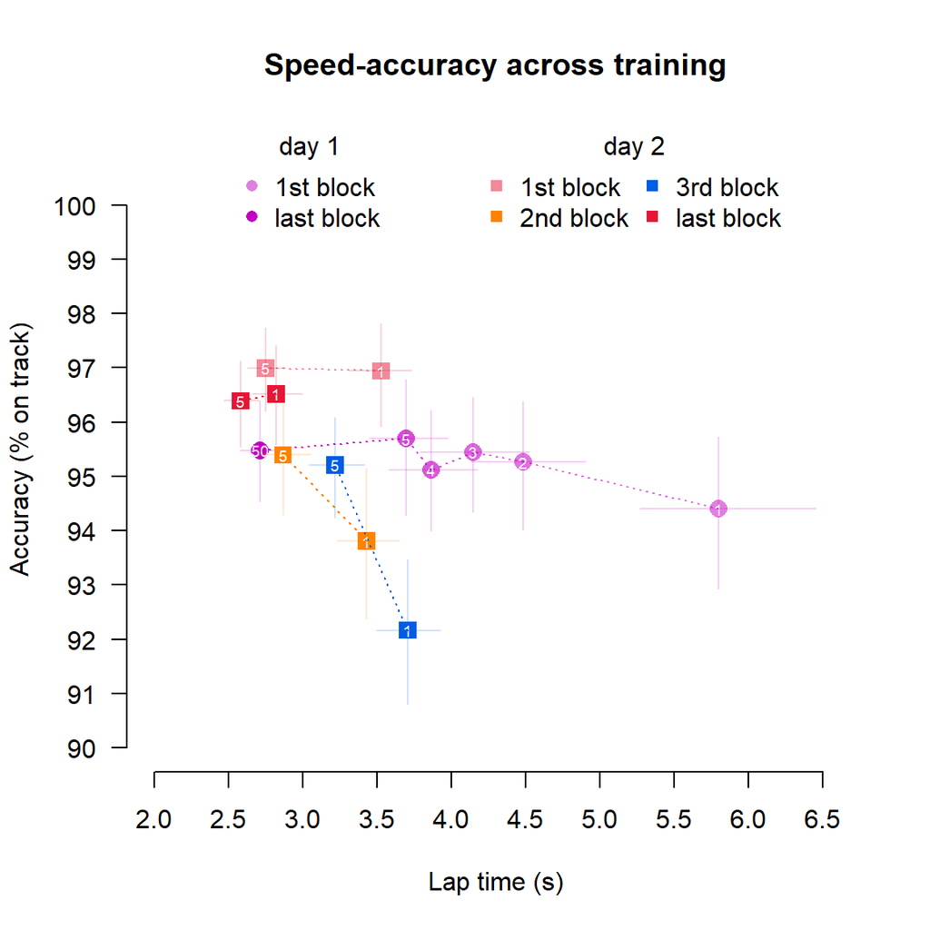

```r
plotSAF()
```

We also explored whether within session improvements in session 1 are associated with the amount of offline gains observed with the accuracy measure.

To calculate for within session improvements: First, we take the accuracy differences between the first and last sets in session 1 across participants. We then normalize these values to range from -1 to 1 using the equation:

Xnorm = 2 * ((X - Xmin)/(Xmax - Xmin)) - 1

To calculate for Offline gains: We take the accuracy differences between the last set of session 1 and the first set of session 2 across participants, before normalizing values using the same equation above.

Finally, we assess the relationship of the values using a Pearson’s correlation test.

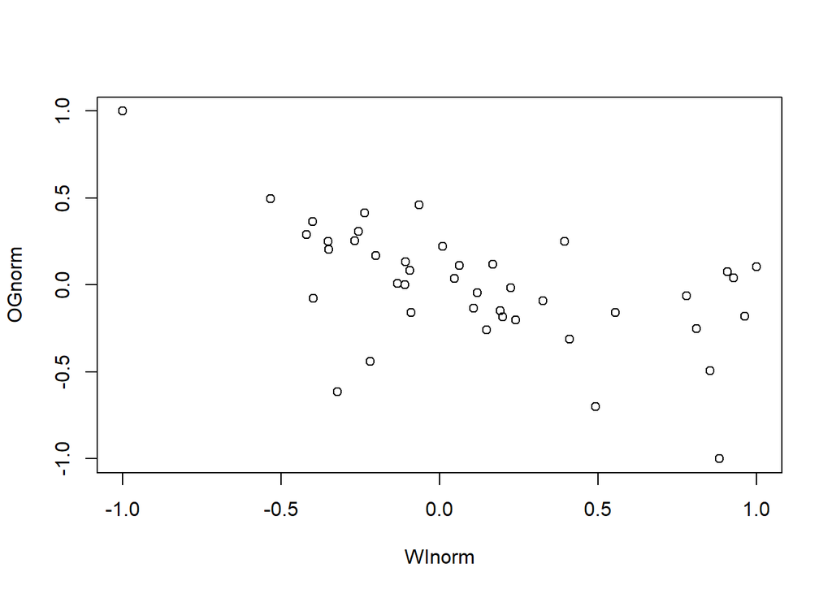

```
##
##  Pearson's product-moment correlation
##
## data:  WInorm and OGnorm
## t = -4.2304, df = 41, p-value = 0.0001277
## alternative hypothesis: true correlation is not equal to 0
## 95 percent confidence interval:
##  -0.7306206 -0.3006757
## sample estimates:
##        cor
## -0.5512393
```

```r
getWithinImprovementOfflineGainsAcc()
```

We find that within session improvements are negatively correlated with offline gains (r = - 0.5512393, p = 0.0001277).

## Movement Efficiency (Path Length)

Next, we repeat the same analyses steps as with the speed and accuracy measures, but now use Path length as the dependent variable.

### Retention (Path Length)

Session 1: first block, first set and last block, last set Session 2: first block, first set

#### Frequentist test

We perform a repeated measures one-way ANOVA to test for an effect across trial sets.

```r
retentionPLANOVA()
```

```
## Path Length during first and last set in session 1 and first set in session 2:
## $ANOVA
##   Effect DFn DFd        F           p p<.05       ges
## 2    set   2  84 5.180832 0.007556403     * 0.0726049
##
## $`Mauchly's Test for Sphericity`
##   Effect         W            p p<.05
## 2    set 0.4944334 5.360561e-07     *
##
## $`Sphericity Corrections`
##   Effect       GGe      p[GG] p[GG]<.05       HFe      p[HF] p[HF]<.05
## 2    set 0.6642018 0.01820798         * 0.6776394 0.01757638         *
```

```r
retentionPLComparisonMeans()
```

```
##  set      emmean     SE df lower.CL upper.CL
##  S1_first  47.75 0.4515 42    46.84    48.66
##  S1_last   46.59 0.1089 42    46.37    46.80
##  S2_1      46.73 0.1753 42    46.37    47.08
##  S2_2      46.37 0.1053 42    46.16    46.58
##
## Confidence level used: 0.95
```

```r
retentionPLComparisonsEffSize()
```

```
##  contrast                              estimate    SE df t.ratio p.value
##  Session 1 Set 1 vs Session 1 Set Last   -1.167 0.474 42  -2.462  0.0540
##  Session 1 Set 1 vs Session 2 Set 1      -1.024 0.445 42  -2.300  0.0795
##  Session 1 Set Last vs Session 2 Set 1    0.143 0.215 42   0.663  1.0000
##
## P value adjustment: bonferroni method for 3 tests
##                                contrast etasquared
## 1 Session 1 Set 1 vs Session 1 Set Last 0.12612925
## 2    Session 1 Set 1 vs Session 2 Set 1 0.11182779
## 3 Session 1 Set Last vs Session 2 Set 1 0.01035236
```

We observe a main effect of set. Follow-up comparisons do not reveal any significant differences.

#### Bayesian test

```r
retentionPLBayesANOVA()
```

```
## Path Length during first and last set in session 1 and first set in session 2:
## Bayes factor analysis
## --------------
## [1] set + participant : 8.466701 ±0.61%
##
## Against denominator:
##   dv ~ participant
## ---
## Bayes factor type: BFlinearModel, JZS
##
## Inclusion Bayes Factors (Model Averaged)
##
##             P(prior) P(posterior) Inclusion BF
## participant     1.00         1.00
## set             0.50         0.89         8.47
##
## * Compared among: all models
## *    Priors odds: uniform-equal
```

```r
retentionPLComparisonsBayesfollowup()
```

```
## Bayesian t-test - Session 1 Set 1 vs Session 1 Set Last:
## Bayes factor analysis
## --------------
## [1] Alt., r=0.707 : 2.411832 ±0%
##
## Against denominator:
##   Null, mu = 0
## ---
## Bayes factor type: BFoneSample, JZS
##
## Bayesian t-test - Session 1 Set 1 vs Session 2 Set 1:
## Bayes factor analysis
## --------------
## [1] Alt., r=0.707 : 1.745153 ±0.02%
##
## Against denominator:
##   Null, mu = 0
## ---
## Bayes factor type: BFoneSample, JZS
##
## Bayesian t-test - Session 1 Set Last vs Session 2 Set 1:
## Bayes factor analysis
## --------------
## [1] Alt., r=0.707 : 0.2028588 ±0.05%
##
## Against denominator:
##   Null, mu = 0
## ---
## Bayes factor type: BFoneSample, JZS
##
## Bayesian t-test - Session 1 Set Last vs Session 2 Set 2:
## Bayes factor analysis
## --------------
## [1] Alt., r=0.707 : 0.5071976 ±0.03%
##
## Against denominator:
##   Null, mu = 0
## ---
## Bayes factor type: BFoneSample, JZS
```

Bayesian tests show the same findings as in the frequentist test.

### Generalization (Path Length)

Next, we compare performance between the novel track conditions and the original trained track. We analyze the first and final sets from session 1, and the first set of the rotated track from session 2.

trained track, Session 1: block 1, first set and block last, last set rotated track, Session 2: block 2, first set

#### Frequentist test

```r
genPLANOVA()
```

```
## Path length during first and last set in session 1 and first set of rotated track in session 2:
## $ANOVA
##   Effect DFn DFd        F          p p<.05        ges
## 2    set   2  84 5.652289 0.00497682     * 0.08212979
##
## $`Mauchly's Test for Sphericity`
##   Effect         W            p p<.05
## 2    set 0.3084474 3.374529e-11     *
##
## $`Sphericity Corrections`
##   Effect       GGe      p[GG] p[GG]<.05       HFe      p[HF] p[HF]<.05
## 2    set 0.5911729 0.01680977         * 0.5982812 0.01645659         *
```

```r
genPLComparisonMeans()
```

```
##  set      emmean     SE df lower.CL upper.CL
##  S1_first  47.75 0.4515 42    46.84    48.66
##  S1_last   46.59 0.1089 42    46.37    46.80
##  S2_3      46.63 0.1299 42    46.37    46.89
##
## Confidence level used: 0.95
```

```r
genPLComparisonsEffSize()
```

```
##  contrast                           estimate    SE df t.ratio p.value
##  Session 1 Set 1 vs Session 2 Set 3  -1.1219 0.462 42  -2.430  0.0389
##  Session 1 Set 2 vs Session 2 Set 3   0.0449 0.162 42   0.277  1.0000
##
## P value adjustment: bonferroni method for 2 tests
##                             contrast  etasquared
## 1 Session 1 Set 1 vs Session 2 Set 3 0.123287522
## 2 Session 1 Set 2 vs Session 2 Set 3 0.001829043
```

We observe a main effect of set. Follow-up comparisons show that this is driven by the difference between the first set in session 1 and the first rotated track set.

#### Bayesian test

```r
genPLBayesANOVA()
```

```
## Path length during first and last set in session 1 and first set of rotated track in session 2:
## Bayes factor analysis
## --------------
## [1] set + participant : 14.49133 ±0.73%
##
## Against denominator:
##   dv ~ participant
## ---
## Bayes factor type: BFlinearModel, JZS
##
## Inclusion Bayes Factors (Model Averaged)
##
##             P(prior) P(posterior) Inclusion BF
## participant     1.00         1.00
## set             0.50         0.94        14.49
##
## * Compared among: all models
## *    Priors odds: uniform-equal
```

```r
genPLComparisonsBayesfollowup()
```

```
## Bayesian t-test - Session 1 Set 1 vs Session 2 Set 3:
## Bayes factor analysis
## --------------
## [1] Alt., r=0.707 : 2.26068 ±0%
##
## Against denominator:
##   Null, mu = 0
## ---
## Bayes factor type: BFoneSample, JZS
##
## Bayesian t-test - Session 1 Set 2 vs Session 2 Set 3:
## Bayes factor analysis
## --------------
## [1] Alt., r=0.707 : 0.1710972 ±0.06%
##
## Against denominator:
##   Null, mu = 0
## ---
## Bayes factor type: BFoneSample, JZS
```

Bayesian tests show that the effect between the first sets is small.

### Generalization (Path Length): with Top Up training as reference

Next, we compare how performance is affected when participants encounter the track rotated by 180 degrees:

trained track, Session 2: block 1, first set and block 1, last set rotated track, Session 2: block 2, first set and block 2, last set

#### Frequentist test

```r
genTopUpPLANOVA()
```

```
## Path length during first block in session 2 and second block in session 2:
## $ANOVA
##   Effect DFn DFd        F          p p<.05       ges
## 2    set   3 126 2.243903 0.08641302       0.0300308
##
## $`Mauchly's Test for Sphericity`
##   Effect         W          p p<.05
## 2    set 0.6909114 0.01014494     *
##
## $`Sphericity Corrections`
##   Effect       GGe     p[GG] p[GG]<.05       HFe      p[HF] p[HF]<.05
## 2    set 0.7917782 0.1018983           0.8423995 0.09790745
```

```r
genTopUpPLComparisonMeans()
```

```
##  set  emmean     SE df lower.CL upper.CL
##  S2_1  46.73 0.1753 42    46.37    47.08
##  S2_2  46.37 0.1053 42    46.16    46.58
##  S2_3  46.63 0.1299 42    46.37    46.89
##  S2_4  46.38 0.1291 42    46.12    46.64
##
## Confidence level used: 0.95
```

We do not observe a main effect of set.

#### Bayesian test

```r
genTopUpPLBayesANOVA()
```

```
## Path length during first block in session 2 and second block in session 2:
## Bayes factor analysis
## --------------
## [1] set + participant : 0.4607838 ±0.54%
##
## Against denominator:
##   dv ~ participant
## ---
## Bayes factor type: BFlinearModel, JZS
##
## Inclusion Bayes Factors (Model Averaged)
##
##             P(prior) P(posterior) Inclusion BF
## participant     1.00         1.00
## set             0.50         0.32        0.461
##
## * Compared among: all models
## *    Priors odds: uniform-equal
```

```r
genTopUpPLComparisonsBayesfollowup()
```

```
## Bayesian t-test - Session 2 Set 1 vs Set 3:
## Bayes factor analysis
## --------------
## [1] Alt., r=0.707 : 0.1858191 ±0.05%
##
## Against denominator:
##   Null, mu = 0
## ---
## Bayes factor type: BFoneSample, JZS
##
## Bayesian t-test - Session 2 Set 2 vs Set 3:
## Bayes factor analysis
## --------------
## [1] Alt., r=0.707 : 0.8964058 ±0.02%
##
## Against denominator:
##   Null, mu = 0
## ---
## Bayes factor type: BFoneSample, JZS
##
## Bayesian t-test - Session 2 Set 2 vs Set 4:
## Bayes factor analysis
## --------------
## [1] Alt., r=0.707 : 0.165095 ±0.06%
##
## Against denominator:
##   Null, mu = 0
## ---
## Bayes factor type: BFoneSample, JZS
```

Bayesian tests show the same findings as in the frequentist test.

### Reverse track (Path Length)

We analyze the first and final sets from session 1, and the first set of the reverse track from session 2.

trained track, Session 1: block 1, first set and block last, last set reverse track, Session 2: block 3, first set

#### Frequentist test

```r
revPLANOVA()
```

```
## Path length during first and last set in session 1 and first set of reverse track in session 2:
## $ANOVA
##   Effect DFn DFd        F            p p<.05       ges
## 2    set   2  84 50.35922 4.229596e-15     * 0.3708423
##
## $`Mauchly's Test for Sphericity`
##   Effect         W            p p<.05
## 2    set 0.3140341 4.875551e-11     *
##
## $`Sphericity Corrections`
##   Effect       GGe        p[GG] p[GG]<.05       HFe        p[HF] p[HF]<.05
## 2    set 0.5931318 6.735111e-10         * 0.6004024 5.433254e-10         *
```

```r
revPLComparisonMeans()
```

```
##  set      emmean     SE df lower.CL upper.CL
##  S1_first  47.75 0.4515 42    46.84    48.66
##  S1_last   46.59 0.1089 42    46.37    46.80
##  S2_5      50.08 0.1990 42    49.68    50.48
##
## Confidence level used: 0.95
```

```r
revPLComparisonsEffSize()
```

```
##  contrast                           estimate    SE df t.ratio p.value
##  Session 1 Set 1 vs Session 2 Set 5     2.32 0.321 42   7.241  <.0001
##  Session 1 Set 2 vs Session 2 Set 5     3.49 0.221 42  15.808  <.0001
##
## P value adjustment: bonferroni method for 2 tests
##                             contrast etasquared
## 1 Session 1 Set 1 vs Session 2 Set 5  0.5552074
## 2 Session 1 Set 2 vs Session 2 Set 5  0.8561178
```

We observe a main effect of set. Follow-up comparisons indicate that this effect is driven by a difference between both the first and last sets of Session 1, when each is compared with the first set of the reverse track.

#### Bayesian test

```r
revPLBayesANOVA()
```

```
## Path length during first and last set in session 1 and first set of reverse track in session 2:
## Bayes factor analysis
## --------------
## [1] set + participant : 1.970245e+13 ±0.95%
##
## Against denominator:
##   dv ~ participant
## ---
## Bayes factor type: BFlinearModel, JZS
##
## Inclusion Bayes Factors (Model Averaged)
##
##             P(prior) P(posterior) Inclusion BF
## participant     1.00         1.00
## set             0.50         1.00     1.97e+13
##
## * Compared among: all models
## *    Priors odds: uniform-equal
```

```r
revPLComparisonsBayesfollowup()
```

```
## Bayesian t-test - Session 1 Set 1 vs Session 2 Set 5:
## Bayes factor analysis
## --------------
## [1] Alt., r=0.707 : 1894861 ±0%
##
## Against denominator:
##   Null, mu = 0
## ---
## Bayes factor type: BFoneSample, JZS
##
## Bayesian t-test - Session 1 Set 2 vs Session 2 Set 5:
```

```
## t is large; approximation invoked.
```

```
## Bayes factor analysis
## --------------
## [1] Alt., r=0.707 : 1.777994e+16 ±0%
##
## Against denominator:
##   Null, mu = 0
## ---
## Bayes factor type: BFoneSample, JZS
```

Bayesian tests show the same findings as in the frequentist test.

### Reverse track (Path Length): with Top Up training as reference

Next, we compare how performance is affected when participants move through the track in reverse:

#### Frequentist test

```r
revTopUpPLANOVA()
```

```
## Path length during first block in session 2 and third block in session 2:
## $ANOVA
##   Effect DFn DFd        F            p p<.05       ges
## 2    set   3 126 214.8918 2.328248e-49     * 0.7544419
##
## $`Mauchly's Test for Sphericity`
##   Effect         W           p p<.05
## 2    set 0.6483589 0.003435549     *
##
## $`Sphericity Corrections`
##   Effect       GGe       p[GG] p[GG]<.05       HFe        p[HF] p[HF]<.05
## 2    set 0.8235242 4.19538e-41         * 0.8789622 1.068149e-43         *
```

```r
revTopUpPLComparisonMeans()
```

```
##  set  emmean     SE df lower.CL upper.CL
##  S2_1  46.73 0.1753 42    46.37    47.08
##  S2_2  46.37 0.1053 42    46.16    46.58
##  S2_5  50.08 0.1990 42    49.68    50.48
##  S2_6  50.04 0.1201 42    49.79    50.28
##
## Confidence level used: 0.95
```

```r
revTopUpPLComparisonsEffSize()
```

[output not shown]

We observe a main effect of set. Follow-up comparisons indicate that path length in the reverse track is increased compared to those in the trained track.

#### Bayesian test

```r
revTopUpPLBayesANOVA()
```

```
## Path length during first block in session 2 and third block in session 2:
## Bayes factor analysis
## --------------
## [1] set + participant : 2.715251e+52 ±1.09%
##
## Against denominator:
##   dv ~ participant
## ---
## Bayes factor type: BFlinearModel, JZS
##
## Inclusion Bayes Factors (Model Averaged)
##
##             P(prior) P(posterior) Inclusion BF
## participant     1.00            1
## set             0.50            1     2.72e+52
##
## * Compared among: all models
## *    Priors odds: uniform-equal
```

```r
revTopUpPLComparisonsBayesfollowup()
```

```
## Bayesian t-test - Session 2 Set 1 vs Set 5:
```

```
## t is large; approximation invoked.
```

```
## Bayes factor analysis
## --------------
## [1] Alt., r=0.707 : 4.552743e+15 ±0%
##
## Against denominator:
##   Null, mu = 0
## ---
## Bayes factor type: BFoneSample, JZS
##
## Bayesian t-test - Session 2 Set 2 vs Set 5:
```

```
## t is large; approximation invoked.
```

```
## Bayes factor analysis
## --------------
## [1] Alt., r=0.707 : 2.223708e+16 ±0%
##
## Against denominator:
##   Null, mu = 0
## ---
## Bayes factor type: BFoneSample, JZS
##
## Bayesian t-test - Session 2 Set 2 vs Set 6:
```

```
## t is large; approximation invoked.
```

```
## Bayes factor analysis
## --------------
## [1] Alt., r=0.707 : 2.059503e+25 ±0%
##
## Against denominator:
##   Null, mu = 0
## ---
## Bayes factor type: BFoneSample, JZS
```

Bayesian tests show the same findings as in the frequentist test.

### Trained track (Path Length)

#### T-test

We may simply compare the first set in the last trained track block with the last set of the first trained track block in session 2.

```r
trainPLTtest()
```

```
## Session 2 Set 2 vs. Session 2 Set 7:
##
##  Paired t-test
##
## data:  subdat1$dv and subdat2$dv
## t = -4.0863, df = 42, p-value = 0.0001931
## alternative hypothesis: true mean difference is not equal to 0
## 95 percent confidence interval:
##  -0.8371374 -0.2836251
## sample estimates:
## mean difference
##      -0.5603813
##
## Effect Size - Cohen d:
## [1] 0.7841078
```

We find a difference between the two trial sets.

Next, we compare performance between the first and last blocks in session 2, to assess whether the other track conditions has interfered with learning in the trained track.

trained track, Session 2: block 1, first set and block 1, last set trained track, Session 2: block 4, first set and block 4, last set

#### Frequentist test

```r
trainPLANOVA()
```

```
## Path Length during first block in session 2 and last block in session 2:
## $ANOVA
##   Effect DFn DFd        F           p p<.05        ges
## 2    set   3 126 4.594194 0.004361951     * 0.06507845
##
## $`Mauchly's Test for Sphericity`
##   Effect       W            p p<.05
## 2    set 0.59264 0.0007124701     *
##
## $`Sphericity Corrections`
##   Effect       GGe      p[GG] p[GG]<.05       HFe       p[HF] p[HF]<.05
## 2    set 0.7330375 0.01030122         * 0.7752075 0.008985989         *
```

```r
trainPLComparisonMeans()
```

```
##  set  emmean      SE df lower.CL upper.CL
##  S2_1  46.73 0.17532 42    46.37    47.08
##  S2_2  46.37 0.10530 42    46.16    46.58
##  S2_7  46.93 0.11256 42    46.70    47.16
##  S2_8  46.49 0.09641 42    46.30    46.69
##
## Confidence level used: 0.95
```

```r
trainPLComparisonsEffSize()
```

```
##  contrast                           estimate    SE df t.ratio p.value
##  Session 2 Set 1 vs Session 2 Set 7    0.204 0.204 42   0.997  0.9736
##  Session 2 Set 2 vs Session 2 Set 7    0.560 0.137 42   4.086  0.0006
##  Session 2 Set 2 vs Session 2 Set 8    0.121 0.116 42   1.046  0.9049
##
## P value adjustment: bonferroni method for 3 tests
##                             contrast etasquared
## 1 Session 2 Set 1 vs Session 2 Set 7 0.02311404
## 2 Session 2 Set 2 vs Session 2 Set 7 0.28446635
## 3 Session 2 Set 2 vs Session 2 Set 8 0.02538022
```

We observe a main effect of set. Follow up comparisons show that this effect is driven by a difference between the last set of block 1 and the first set of the last block.

#### Bayesian test

```r
trainPLBayesANOVA()
```

```
## Path Length during first block in session 2 and last block in session 2:
## Bayes factor analysis
## --------------
## [1] set + participant : 8.962943 ±0.47%
##
## Against denominator:
##   dv ~ participant
## ---
## Bayes factor type: BFlinearModel, JZS
##
## Inclusion Bayes Factors (Model Averaged)
##
##             P(prior) P(posterior) Inclusion BF
## participant     1.00         1.00
## set             0.50         0.90         8.96
##
## * Compared among: all models
## *    Priors odds: uniform-equal
```

```r
trainPLComparisonsBayesfollowup()
```

```
## Bayesian t-test - Session 2 Set 1 vs Set 7:
## Bayes factor analysis
## --------------
## [1] Alt., r=0.707 : 0.2625164 ±0.05%
##
## Against denominator:
##   Null, mu = 0
## ---
## Bayes factor type: BFoneSample, JZS
##
## Bayesian t-test - Session 2 Set 2 vs Set 7:
## Bayes factor analysis
## --------------
## [1] Alt., r=0.707 : 131.218 ±0%
##
## Against denominator:
##   Null, mu = 0
## ---
## Bayes factor type: BFoneSample, JZS
##
## Bayesian t-test - Session 2 Set 2 vs Set 8:
## Bayes factor analysis
## --------------
## [1] Alt., r=0.707 : 0.2749135 ±0.05%
##
## Against denominator:
##   Null, mu = 0
## ---
## Bayes factor type: BFoneSample, JZS
```

Bayesian tests show the same findings as in the frequentist test.

## Movement Efficiency INSIDE track (Path Length inside)

Next, we repeat the same analyses steps as in the previous section, but now use Path length inside the track as the dependent variable.

### Retention (Path Length inside)

Session 1: first block, first set and last block, last set Session 2: first block, first set

#### Frequentist test

We perform a repeated measures one-way ANOVA to test for an effect across trial sets.

```r
retentionPLINANOVA()
```

```
## Path Length in during first and last set in session 1 and first set in session 2:
## $ANOVA
##   Effect DFn DFd        F         p p<.05        ges
## 2    set   2  84 1.382352 0.2566375       0.01729355
##
## $`Mauchly's Test for Sphericity`
##   Effect         W           p p<.05
## 2    set 0.7932634 0.008670763     *
##
## $`Sphericity Corrections`
##   Effect       GGe    p[GG] p[GG]<.05       HFe     p[HF] p[HF]<.05
## 2    set 0.8286813 0.256212           0.8584787 0.2564312
```

```r
retentionPLINComparisonMeans()
```

```
##  set      emmean    SE df lower.CL upper.CL
##  S1_first   44.9 0.433 42     44.1     45.8
##  S1_last    44.5 0.288 42     43.9     45.1
##  S2_1       45.2 0.289 42     44.6     45.8
##  S2_2       45.0 0.224 42     44.6     45.5
##
## Confidence level used: 0.95
```

We do not observe a main effect of set.

#### Bayesian test

```r
retentionPLINBayesANOVA()
```

```
## Path Length in during first and last set in session 1 and first set in session 2:
## Bayes factor analysis
## --------------
## [1] set + participant : 0.2497222 ±1.06%
##
## Against denominator:
##   dv ~ participant
## ---
## Bayes factor type: BFlinearModel, JZS
##
## Inclusion Bayes Factors (Model Averaged)
##
##             P(prior) P(posterior) Inclusion BF
## participant     1.00         1.00
## set             0.50         0.20        0.250
##
## * Compared among: all models
## *    Priors odds: uniform-equal
```

```r
retentionPLINComparisonsBayesfollowup()
```

```
## Bayesian t-test - Session 1 Set 1 vs Session 1 Set Last:
## Bayes factor analysis
## --------------
## [1] Alt., r=0.707 : 0.2354571 ±0.05%
##
## Against denominator:
##   Null, mu = 0
## ---
## Bayes factor type: BFoneSample, JZS
##
## Bayesian t-test - Session 1 Set 1 vs Session 2 Set 1:
## Bayes factor analysis
## --------------
## [1] Alt., r=0.707 : 0.1976401 ±0.05%
##
## Against denominator:
##   Null, mu = 0
## ---
## Bayes factor type: BFoneSample, JZS
##
## Bayesian t-test - Session 1 Set Last vs Session 2 Set 1:
## Bayes factor analysis
## --------------
## [1] Alt., r=0.707 : 1.186777 ±0.02%
##
## Against denominator:
##   Null, mu = 0
## ---
## Bayes factor type: BFoneSample, JZS
##
## Bayesian t-test - Session 1 Set Last vs Session 2 Set 2:
## Bayes factor analysis
## --------------
## [1] Alt., r=0.707 : 0.6832078 ±0.03%
##
## Against denominator:
##   Null, mu = 0
## ---
## Bayes factor type: BFoneSample, JZS
```

Bayesian tests show the same findings as in the frequentist test.

### Generalization (Path Length inside)

Next, we compare performance between the novel track conditions and the original trained track. We analyze the first and final sets from session 1, and the first set of the rotated track from session 2.

trained track, Session 1: block 1, first set and block last, last set rotated track, Session 2: block 2, first set

#### Frequentist test

```r
genPLINANOVA()
```

```
## Path length IN during first and last set in session 1 and first set of rotated track in session 2:
## $ANOVA
##   Effect DFn DFd        F          p p<.05       ges
## 2    set   2  84 3.507881 0.03442171     * 0.0390005
##
## $`Mauchly's Test for Sphericity`
##   Effect         W         p p<.05
## 2    set 0.9306146 0.2289719
##
## $`Sphericity Corrections`
##   Effect       GGe      p[GG] p[GG]<.05       HFe     p[HF] p[HF]<.05
## 2    set 0.9351166 0.03764383         * 0.9770805 0.0355269         *
```

```r
genPLINComparisonMeans()
```

```
##  set      emmean    SE df lower.CL upper.CL
##  S1_first   44.9 0.433 42     44.1     45.8
##  S1_last    44.5 0.288 42     43.9     45.1
##  S2_3       43.7 0.406 42     42.9     44.6
##
## Confidence level used: 0.95
```

```r
genPLINComparisonsEffSize()
```

```
##  contrast                           estimate    SE df t.ratio p.value
##  Session 1 Set 1 vs Session 2 Set 3   -1.205 0.443 42  -2.719  0.0190
##  Session 1 Set 2 vs Session 2 Set 3   -0.756 0.415 42  -1.821  0.1516
##
## P value adjustment: bonferroni method for 2 tests
##                             contrast etasquared
## 1 Session 1 Set 1 vs Session 2 Set 3 0.14966919
## 2 Session 1 Set 2 vs Session 2 Set 3 0.07313979
```

We observe a main effect of set. Follow-up comparisons show that this is driven by the difference between the first set in session 1 and the first rotated track set.

#### Bayesian test

```r
genPLINBayesANOVA()
```

```
## Path length IN during first and last set in session 1 and first set of rotated track in session 2:
## Bayes factor analysis
## --------------
## [1] set + participant : 1.435123 ±0.78%
##
## Against denominator:
##   dv ~ participant
## ---
## Bayes factor type: BFlinearModel, JZS
##
## Inclusion Bayes Factors (Model Averaged)
##
##             P(prior) P(posterior) Inclusion BF
## participant     1.00         1.00
## set             0.50         0.59         1.44
##
## * Compared among: all models
## *    Priors odds: uniform-equal
```

```r
genPLINComparisonsBayesfollowup()
```

```
## Bayesian t-test - Session 1 Set 1 vs Session 2 Set 3:
## Bayes factor analysis
## --------------
## [1] Alt., r=0.707 : 4.157843 ±0%
##
## Against denominator:
##   Null, mu = 0
## ---
## Bayes factor type: BFoneSample, JZS
##
## Bayesian t-test - Session 1 Set 2 vs Session 2 Set 3:
## Bayes factor analysis
## --------------
## [1] Alt., r=0.707 : 0.7466156 ±0.03%
##
## Against denominator:
##   Null, mu = 0
## ---
## Bayes factor type: BFoneSample, JZS
```

### Generalization (Path Length inside): with Top Up training as reference

Next, we compare how performance is affected when participants encounter the track rotated by 180 degrees:

trained track, Session 2: block 1, first set and block 1, last set rotated track, Session 2: block 2, first set and block 2, last set

#### Frequentist test

```r
genTopUpPLINANOVA()
```

```
## Path length IN during first block in session 2 and second block in session 2:
## $ANOVA
##   Effect DFn DFd        F            p p<.05        ges
## 2    set   3 126 8.473319 3.588742e-05     * 0.07907562
##
## $`Mauchly's Test for Sphericity`
##   Effect         W         p p<.05
## 2    set 0.8131409 0.1344936
##
## $`Sphericity Corrections`
##   Effect       GGe        p[GG] p[GG]<.05       HFe        p[HF] p[HF]<.05
## 2    set 0.8887066 8.282315e-05         * 0.9545897 5.046144e-05         *
```

```r
genTopUpPLINComparisonMeans()
```

```
##  set  emmean    SE df lower.CL upper.CL
##  S2_1   45.2 0.289 42     44.6     45.8
##  S2_2   45.0 0.224 42     44.6     45.5
##  S2_3   43.7 0.406 42     42.9     44.6
##  S2_4   44.2 0.311 42     43.6     44.8
##
## Confidence level used: 0.95
```

```r
genTopUpPLINComparisonsEffSize()
```

```
##  contrast                           estimate    SE df t.ratio p.value
##  Session 1 Set 1 vs Session 2 Set 3   -1.205 0.443 42  -2.719  0.0190
##  Session 1 Set 2 vs Session 2 Set 3   -0.756 0.415 42  -1.821  0.1516
##
## P value adjustment: bonferroni method for 2 tests
##                             contrast etasquared
## 1 Session 1 Set 1 vs Session 2 Set 3 0.14966919
## 2 Session 1 Set 2 vs Session 2 Set 3 0.07313979
```

We observe a main effect of set. Follow-up comparisons show that path length within the track is shorter during rotated-track trials than during trained-track trials, suggesting more frequent departures beyond the track limits in the rotated condition.

#### Bayesian test

```r
genTopUpPLINBayesANOVA()
```

```
## Path length IN during first block in session 2 and second block in session 2:
## Bayes factor analysis
## --------------
## [1] set + participant : 588.0314 ±0.46%
##
## Against denominator:
##   dv ~ participant
## ---
## Bayes factor type: BFlinearModel, JZS
##
## Inclusion Bayes Factors (Model Averaged)
##
##             P(prior) P(posterior) Inclusion BF
## participant     1.00         1.00
## set             0.50         1.00       588.03
##
## * Compared among: all models
## *    Priors odds: uniform-equal
```

```r
genTopUpPLINComparisonsBayesfollowup()
```

```
## Bayesian t-test - Session 2 Set 1 vs Set 3:
## Bayes factor analysis
## --------------
## [1] Alt., r=0.707 : 1485.677 ±0%
##
## Against denominator:
##   Null, mu = 0
## ---
## Bayes factor type: BFoneSample, JZS
##
## Bayesian t-test - Session 2 Set 2 vs Set 3:
## Bayes factor analysis
## --------------
## [1] Alt., r=0.707 : 15.14606 ±0%
##
## Against denominator:
##   Null, mu = 0
## ---
## Bayes factor type: BFoneSample, JZS
##
## Bayesian t-test - Session 2 Set 2 vs Set 4:
## Bayes factor analysis
## --------------
## [1] Alt., r=0.707 : 3.036689 ±0%
##
## Against denominator:
##   Null, mu = 0
## ---
## Bayes factor type: BFoneSample, JZS
```

Bayesian tests show the same findings as in the frequentist test.

### Reverse track (Path Length inside)

We analyze the first and final sets from session 1, and the first set of the reverse track from session 2.

trained track, Session 1: block 1, first set and block last, last set reverse track, Session 2: block 3, first set

#### Frequentist test

```r
revPLINANOVA()
```

```
## Path length IN during first and last set in session 1 and first set of reverse track in session 2:
## $ANOVA
##   Effect DFn DFd        F           p p<.05        ges
## 2    set   2  84 6.848453 0.001756855     * 0.07778388
##
## $`Mauchly's Test for Sphericity`
##   Effect         W         p p<.05
## 2    set 0.9214638 0.1869842
##
## $`Sphericity Corrections`
##   Effect       GGe       p[GG] p[GG]<.05       HFe       p[HF] p[HF]<.05
## 2    set 0.9271826 0.002327184         * 0.9681962 0.001986189         *
```

```r
revPLINComparisonMeans()
```

```
##  set      emmean    SE df lower.CL upper.CL
##  S1_first   44.9 0.433 42     44.1     45.8
##  S1_last    44.5 0.288 42     43.9     45.1
##  S2_5       46.1 0.364 42     45.4     46.9
##
## Confidence level used: 0.95
```

```r
revPLINComparisonsEffSize()
```

```
##  contrast                           estimate    SE df t.ratio p.value
##  Session 1 Set 1 vs Session 2 Set 5     1.19 0.437 42   2.714  0.0192
##  Session 1 Set 2 vs Session 2 Set 5     1.64 0.411 42   3.980  0.0005
##
## P value adjustment: bonferroni method for 2 tests
##                             contrast etasquared
## 1 Session 1 Set 1 vs Session 2 Set 5  0.1492079
## 2 Session 1 Set 2 vs Session 2 Set 5  0.2738164
```

We observe a main effect of set. Follow-up comparisons indicate that this effect is driven by a difference between both the first and last sets of Session 1, when each is compared with the first set of the reverse track.

#### Bayesian test

```r
revPLINBayesANOVA()
```

```
## Path length IN during first and last set in session 1 and first set of reverse track in session 2:
## Bayes factor analysis
## --------------
## [1] set + participant : 23.89053 ±2.25%
##
## Against denominator:
##   dv ~ participant
## ---
## Bayes factor type: BFlinearModel, JZS
##
## Inclusion Bayes Factors (Model Averaged)
##
##             P(prior) P(posterior) Inclusion BF
## participant     1.00         1.00
## set             0.50         0.96        23.89
##
## * Compared among: all models
## *    Priors odds: uniform-equal
```

```r
revPLINComparisonsBayesfollowup()
```

```
## Bayesian t-test - Session 1 Set 1 vs Session 2 Set 5:
## Bayes factor analysis
## --------------
## [1] Alt., r=0.707 : 4.113091 ±0%
##
## Against denominator:
##   Null, mu = 0
## ---
## Bayes factor type: BFoneSample, JZS
##
## Bayesian t-test - Session 1 Set 2 vs Session 2 Set 5:
## Bayes factor analysis
## --------------
## [1] Alt., r=0.707 : 97.58926 ±0%
##
## Against denominator:
##   Null, mu = 0
## ---
## Bayes factor type: BFoneSample, JZS
```

Bayesian tests show the same findings as in the frequentist test.

### Reverse track (Path Length inside): with Top Up training as reference

Next, we compare how performance is affected when participants move through the track in reverse:

trained track, Session 2: block 1, first set and block 1, last set reverse track, Session 2: block 2, first set and block 2, last set

#### Frequentist test

```r
revTopUpPLINANOVA()
```

```
## Path length IN during first block in session 2 and third block in session 2:
## $ANOVA
##   Effect DFn DFd        F            p p<.05       ges
## 2    set   3 126 25.98054 3.764347e-13     * 0.2301514
##
## $`Mauchly's Test for Sphericity`
##   Effect        W         p p<.05
## 2    set 0.933915 0.7332854
##
## $`Sphericity Corrections`
##   Effect      GGe        p[GG] p[GG]<.05      HFe        p[HF] p[HF]<.05
## 2    set 0.961053 9.999497e-13         * 1.039415 3.764347e-13         *
```

```r
revTopUpPLINComparisonMeans()
```

```
##  set  emmean    SE df lower.CL upper.CL
##  S2_1   45.2 0.289 42     44.6     45.8
##  S2_2   45.0 0.224 42     44.6     45.5
##  S2_5   46.1 0.364 42     45.4     46.9
##  S2_6   47.7 0.293 42     47.1     48.3
##
## Confidence level used: 0.95
```

```r
revTopUpPLINComparisonsEffSize()
```

```
##  contrast                           estimate    SE df t.ratio p.value
##  Session 1 Set 1 vs Session 2 Set 5     1.19 0.437 42   2.714  0.0192
##  Session 1 Set 2 vs Session 2 Set 5     1.64 0.411 42   3.980  0.0005
##
## P value adjustment: bonferroni method for 2 tests
##                             contrast etasquared
## 1 Session 1 Set 1 vs Session 2 Set 5  0.1492079
## 2 Session 1 Set 2 vs Session 2 Set 5  0.2738164
```

We observe a main effect of set. Follow-up comparisons show that path length within the track is longer during reverse-track trials than during trained-track trials, suggesting less efficient movement within the track for reverse movements.

#### Bayesian test

```r
revTopUpPLINBayesANOVA()
```

```
## Path length IN during first block in session 2 and third block in session 2:
## Bayes factor analysis
## --------------
## [1] set + participant : 31602041710 ±1.06%
##
## Against denominator:
##   dv ~ participant
## ---
## Bayes factor type: BFlinearModel, JZS
##
## Inclusion Bayes Factors (Model Averaged)
##
##             P(prior) P(posterior) Inclusion BF
## participant     1.00         1.00
## set             0.50         1.00     3.16e+10
##
## * Compared among: all models
## *    Priors odds: uniform-equal
```

```r
revTopUpPLINComparisonsBayesfollowup()
```

```
## Bayesian t-test - Session 2 Set 1 vs Set 5:
## Bayes factor analysis
## --------------
## [1] Alt., r=0.707 : 4.838902 ±0%
##
## Against denominator:
##   Null, mu = 0
## ---
## Bayes factor type: BFoneSample, JZS
##
## Bayesian t-test - Session 2 Set 2 vs Set 5:
## Bayes factor analysis
## --------------
## [1] Alt., r=0.707 : 10.37174 ±0%
##
## Against denominator:
##   Null, mu = 0
## ---
## Bayes factor type: BFoneSample, JZS
##
## Bayesian t-test - Session 2 Set 2 vs Set 6:
## Bayes factor analysis
## --------------
## [1] Alt., r=0.707 : 44720837 ±0%
##
## Against denominator:
##   Null, mu = 0
## ---
## Bayes factor type: BFoneSample, JZS
```

Bayesian tests show the same findings as in the frequentist test.

### Trained track (Path Length inside)

#### T-test

We may simply compare the first set in the last trained track block with the last set of the first trained track block in session 2.

```r
trainPLINTtest()
```

```
## Session 2 Set 2 vs. Session 2 Set 7:
##
##  Paired t-test
##
## data:  subdat1$dv and subdat2$dv
## t = -0.81426, df = 42, p-value = 0.4201
## alternative hypothesis: true mean difference is not equal to 0
## 95 percent confidence interval:
##  -0.8598644  0.3654669
## sample estimates:
## mean difference
##      -0.2471988
##
## Effect Size - Cohen d:
## [1] 0.1569719
```

We do not find a difference between the two trial sets.

Next, we compare performance between the first and last blocks in session 2, to assess whether the other track conditions has interfered with learning in the trained track.

trained track, Session 2: block 1, first set and block 1, last set trained track, Session 2: block 4, first set and block 4, last set

#### Frequentist test

```r
trainPLINANOVA()
```

```
## Path Length in during first block in session 2 and last block in session 2:
## $ANOVA
##   Effect DFn DFd         F         p p<.05        ges
## 2    set   3 126 0.8711765 0.4580145       0.01177537
##
## $`Mauchly's Test for Sphericity`
##   Effect         W         p p<.05
## 2    set 0.8968632 0.4890504
##
## $`Sphericity Corrections`
##   Effect       GGe     p[GG] p[GG]<.05       HFe     p[HF] p[HF]<.05
## 2    set 0.9271744 0.4514682           0.9995756 0.4579779
```

```r
trainPLINComparisonMeans()
```

```
##  set  emmean    SE df lower.CL upper.CL
##  S2_1   45.2 0.289 42     44.6     45.8
##  S2_2   45.0 0.224 42     44.6     45.5
##  S2_7   45.3 0.255 42     44.8     45.8
##  S2_8   44.8 0.216 42     44.4     45.3
##
## Confidence level used: 0.95
```

We do not observe a main effect of set.

#### Bayesian test

```r
trainPLINBayesANOVA()
```

```
## Path Length in during first block in session 2 and last block in session 2:
## Bayes factor analysis
## --------------
## [1] set + participant : 0.08604924 ±0.71%
##
## Against denominator:
##   dv ~ participant
## ---
## Bayes factor type: BFlinearModel, JZS
##
## Inclusion Bayes Factors (Model Averaged)
##
##             P(prior) P(posterior) Inclusion BF
## participant     1.00         1.00
## set             0.50         0.08        0.086
##
## * Compared among: all models
## *    Priors odds: uniform-equal
```

```r
trainPLINComparisonsBayesfollowup()
```

```
## Bayesian t-test - Session 2 Set 1 vs Set 7:
## Bayes factor analysis
## --------------
## [1] Alt., r=0.707 : 0.1669724 ±0.06%
##
## Against denominator:
##   Null, mu = 0
## ---
## Bayes factor type: BFoneSample, JZS
##
## Bayesian t-test - Session 2 Set 2 vs Set 7:
## Bayes factor analysis
## --------------
## [1] Alt., r=0.707 : 0.2251813 ±0.05%
##
## Against denominator:
##   Null, mu = 0
## ---
## Bayes factor type: BFoneSample, JZS
##
## Bayesian t-test - Session 2 Set 2 vs Set 8:
## Bayes factor analysis
## --------------
## [1] Alt., r=0.707 : 0.2120018 ±0.05%
##
## Against denominator:
##   Null, mu = 0
## ---
## Bayes factor type: BFoneSample, JZS
```

Bayesian tests show the same findings as in the frequentist test.

# Study 2

Given that in Study 1, we found that moving through the track in reverse revealed a movement direction effect (across all measures), we conducted a second study to investigate this further. The movement direction effect can be due to either interference in learning from the previous track conditions, or due to a bias in right-handed movements (all participants were right handed and used their right hand for moving). Thus, in study 2, we repeated the same experiment procedure and analyses as in study 1, but the only difference is that participants now moved in the reverse (counterclockwise) direction during the trained track trials, and moved in the clockwise direction during reverse track trials.

## Track orientations

As in the previous study, track orientations were counterbalanced across participants.

Below we plot speed (lap times), accuracy (percent on track), and path length (trajectory) measures, according to track orientations.

### Speed: Session 1 and 2

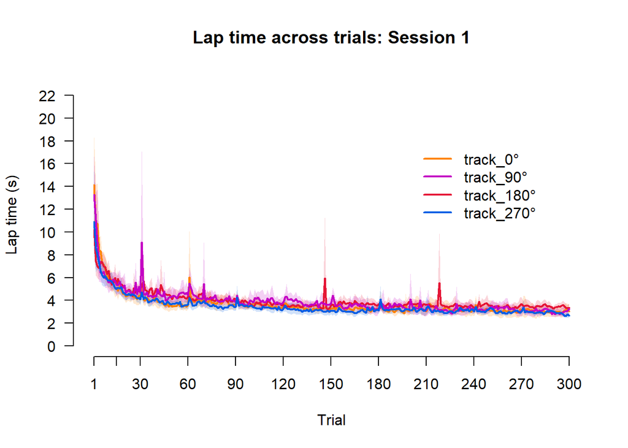

```r
plotR2LapTime()
```

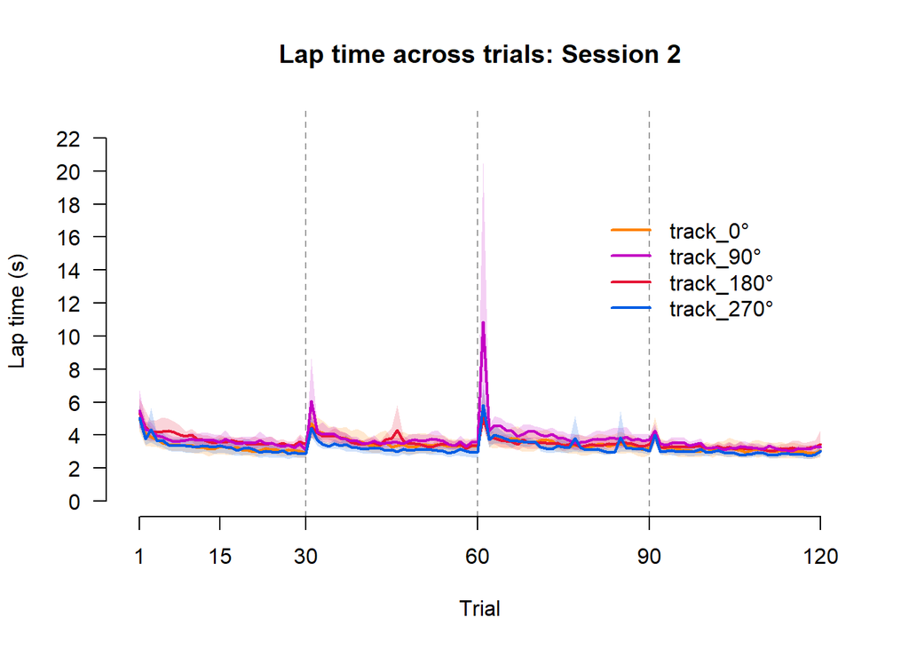

```r
plotR2S2LapTime()
```

### Accuracy: Session 1 and 2

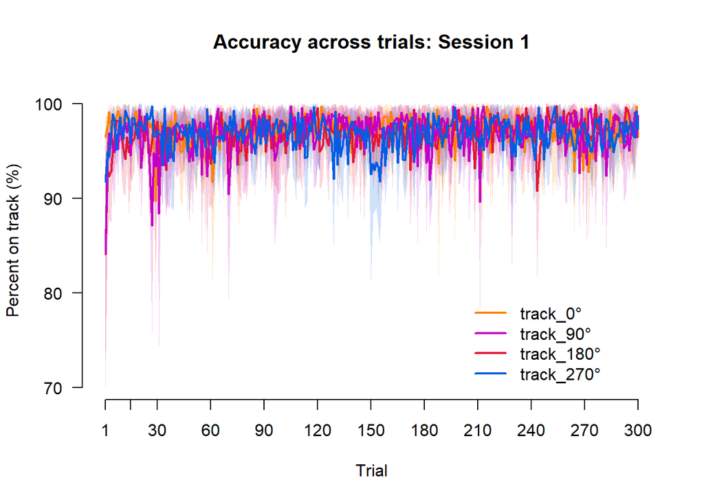

```r
plotR2Accuracy()
```

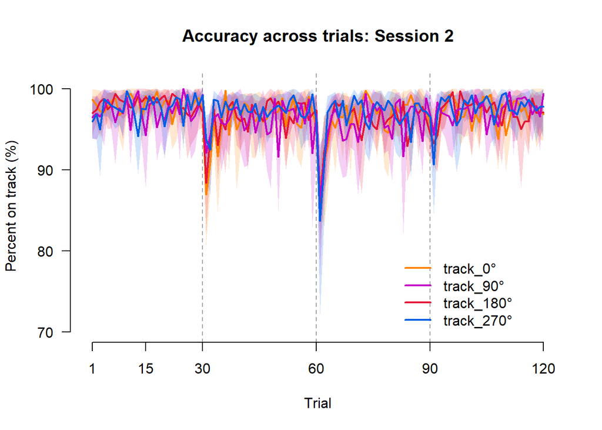

```r
plotR2S2Accuracy()
```

### Path Length: Session 1 and 2

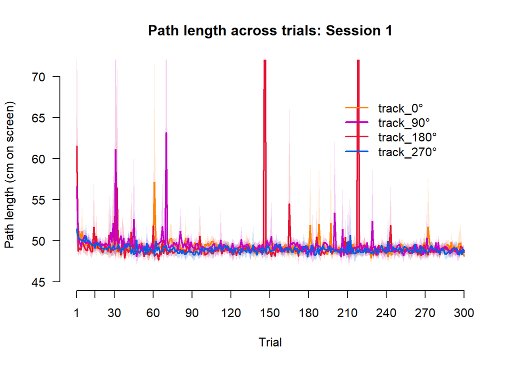

```r
plotR2PathLength()
```

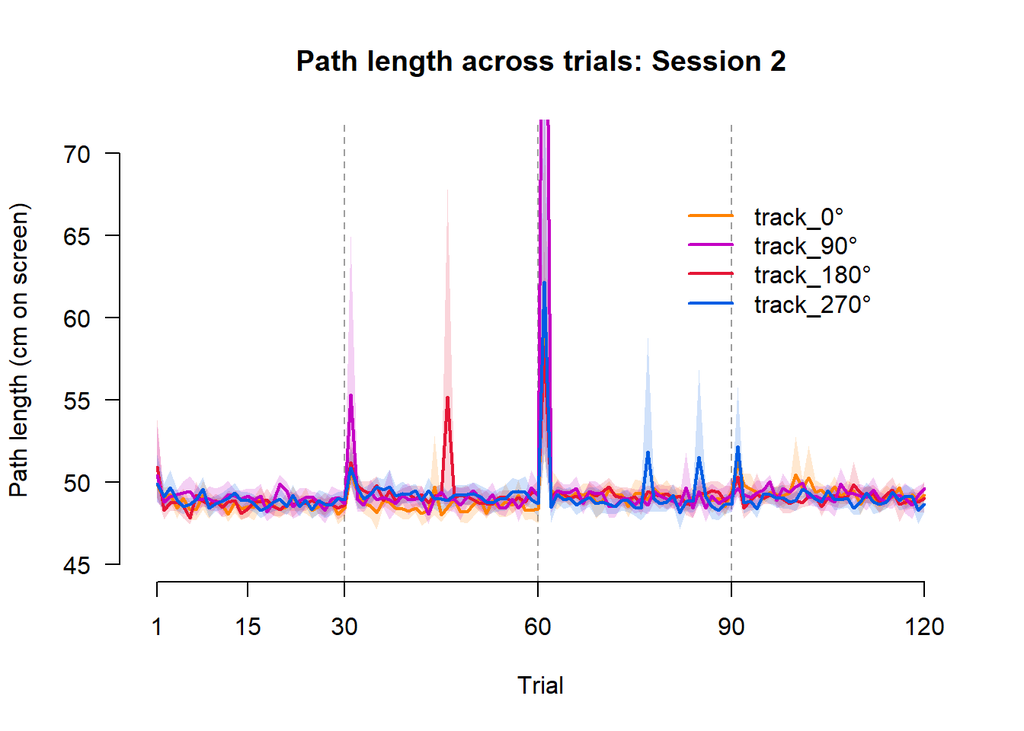

```r
plotR2S2PathLength()
```

Much like in study 1, we do not observe differences for speed, accuracy, and path length when comparing performance across track orientations. Thus, we combine data from all orientations and analyze the data further.

## Speed (Lap times)

We first show lap times across both sessions.

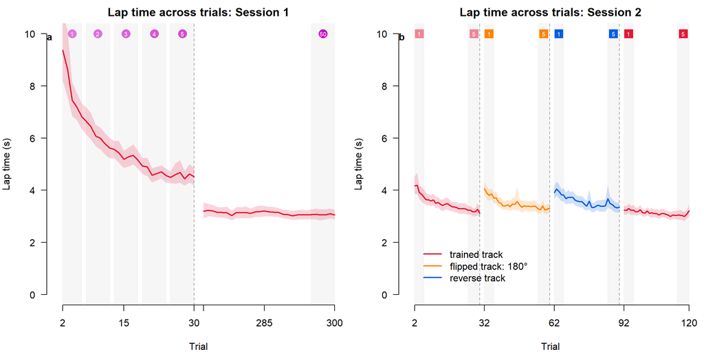

```r
plotR2FirstLastAllTrackAcrossSessionLapTime()
```

The plot below adds individual data to the previous plot.

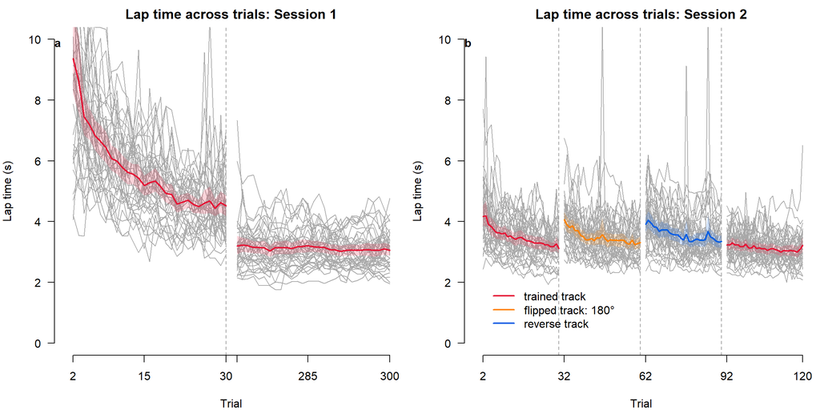

```r
plotR2IndFirstLastAllTrackAcrossSessionLapTime()
```

Results presented below follow the same analyses steps conducted in Study 1.

### Retention (Lap times)

Session 1: first block, first set and last block, last set Session 2: first block, first set

#### Frequentist test

We perform a repeated measures one-way ANOVA to test for an effect across trial sets.

```r
retentionR2LapTimeANOVA()
```

```
## Lap times during first and last set in session 1 and first and set in session 2:
## $ANOVA
##   Effect DFn DFd        F            p p<.05      ges
## 2    set   2  70 124.0331 9.779573e-24     * 0.665476
##
## $`Mauchly's Test for Sphericity`
##   Effect         W            p p<.05
## 2    set 0.2977016 1.133132e-09     *
##
## $`Sphericity Corrections`
##   Effect       GGe       p[GG] p[GG]<.05       HFe        p[HF] p[HF]<.05
## 2    set 0.5874411 6.30456e-15         * 0.5956484 4.207157e-15         *
```

```r
retentionR2LapTimeComparisonMeans()
```

```
##  set      emmean     SE df lower.CL upper.CL
##  S1_first   7.83 0.3925 35     7.03     8.63
##  S1_last    3.09 0.0953 35     2.90     3.29
##  S2_1       3.98 0.1376 35     3.70     4.26
##  S2_2       3.20 0.0818 35     3.03     3.36
##
## Confidence level used: 0.95
```

```r
retentionR2LapTimeComparisonsEffSize()
```

```
##  contrast                              estimate    SE df t.ratio p.value
##  Session 1 Set 1 vs Session 1 Set Last   -4.735 0.385 35 -12.307  <.0001
##  Session 1 Set 1 vs Session 2 Set 1      -3.851 0.377 35 -10.220  <.0001
##  Session 1 Set Last vs Session 2 Set 1    0.884 0.129 35   6.858  <.0001
##
## P value adjustment: bonferroni method for 3 tests
##                                contrast etasquared
## 1 Session 1 Set 1 vs Session 1 Set Last  0.8122887
## 2    Session 1 Set 1 vs Session 2 Set 1  0.7490223
## 3 Session 1 Set Last vs Session 2 Set 1  0.5733335
```

We observe a main effect of set. Follow-up comparisons indicate that this effect is driven by a difference between the first and last sets in session 1, consistent with within-session improvements. The first set in session 2 is lower than the first set in session 1, but not as low as the final set in session 1, suggesting partial retention of performance.

#### Bayesian test

```r
retentionR2LapTimeBayesANOVA()
```

```
## Lap times during first and last set in session 1 and first set in session 2:
## Bayes factor analysis
## --------------
## [1] set + participant : 1.492019e+25 ±0.9%
##
## Against denominator:
##   dv ~ participant
## ---
## Bayes factor type: BFlinearModel, JZS
##
## Inclusion Bayes Factors (Model Averaged)
##
##             P(prior) P(posterior) Inclusion BF
## participant     1.00            1
## set             0.50            1     1.49e+25
##
## * Compared among: all models
## *    Priors odds: uniform-equal
```

```r
retentionR2LapTimeComparisonsBayesfollowup()
```

```
## Bayesian t-test - Session 1 Set 1 vs Session 1 Set Last:
## Bayes factor analysis
## --------------
## [1] Alt., r=0.707 : 247376262277 ±0%
##
## Against denominator:
##   Null, mu = 0
## ---
## Bayes factor type: BFoneSample, JZS
##
## Bayesian t-test - Session 1 Set 1 vs Session 2 Set 1:
## Bayes factor analysis
## --------------
## [1] Alt., r=0.707 : 1838534869 ±0%
##
## Against denominator:
##   Null, mu = 0
## ---
## Bayes factor type: BFoneSample, JZS
##
## Bayesian t-test - Session 1 Set Last vs Session 2 Set 1:
## Bayes factor analysis
## --------------
## [1] Alt., r=0.707 : 246154.1 ±0%
##
## Against denominator:
##   Null, mu = 0
## ---
## Bayes factor type: BFoneSample, JZS
##
## Bayesian t-test - Session 1 Set Last vs Session 2 Set 2:
## Bayes factor analysis
## --------------
## [1] Alt., r=0.707 : 0.3536077 ±0.04%
##
## Against denominator:
##   Null, mu = 0
## ---
## Bayes factor type: BFoneSample, JZS
```

Bayesian tests show the same findings as in the frequentist test.

### Generalization (Lap times)

Next, we compare performance between the novel track conditions and the original trained track. We analyze the first and final sets from session 1, and the first set of the rotated track from session 2.

trained track, Session 1: block 1, first set and block last, last set rotated track, Session 2: block 2, first set

#### Frequentist test

```r
genR2LapTimeANOVA()
```

```
## Lap times during first and last set in session 1 and first set of rotated track in session 2:
## $ANOVA
##   Effect DFn DFd        F            p p<.05       ges
## 2    set   2  70 140.1175 3.356229e-25     * 0.6787807
##
## $`Mauchly's Test for Sphericity`
##   Effect         W            p p<.05
## 2    set 0.1608607 3.233324e-14     *
##
## $`Sphericity Corrections`
##   Effect       GGe        p[GG] p[GG]<.05       HFe        p[HF] p[HF]<.05
## 2    set 0.5437326 8.600384e-15         * 0.5477141 6.973406e-15         *
```

```r
genR2LapTimeComparisonMeans()
```

```
##  set      emmean     SE df lower.CL upper.CL
##  S1_first   7.83 0.3925 35     7.03     8.63
##  S1_last    3.09 0.0953 35     2.90     3.29
##  S2_3       3.87 0.1067 35     3.65     4.08
##
## Confidence level used: 0.95
```

```r
genR2LapTimeComparisonsEffSize()
```

```
##  contrast                           estimate     SE df t.ratio p.value
##  Session 1 Set 1 vs Session 2 Set 3   -3.963 0.3448 35 -11.494  <.0001
##  Session 1 Set 2 vs Session 2 Set 3    0.772 0.0971 35   7.947  <.0001
##
## P value adjustment: bonferroni method for 2 tests
##                             contrast etasquared
## 1 Session 1 Set 1 vs Session 2 Set 3  0.7905473
## 2 Session 1 Set 2 vs Session 2 Set 3  0.6434205
```

We observe a main effect of set. Follow-up comparisons indicate that this effect is driven by a difference between both the first and last sets of Session 1, when each is compared with the first set of the rotated track.

#### Bayesian test

```r
genR2LapTimeBayesANOVA()
```

```
## Lap times during first and last set in session 1 and first set of rotated track in session 2:
## Bayes factor analysis
## --------------
## [1] set + participant : 3.314089e+26 ±0.64%
##
## Against denominator:
##   dv ~ participant
## ---
## Bayes factor type: BFlinearModel, JZS
##
## Inclusion Bayes Factors (Model Averaged)
##
##             P(prior) P(posterior) Inclusion BF
## participant     1.00            1
## set             0.50            1     3.31e+26
##
## * Compared among: all models
## *    Priors odds: uniform-equal
```

```r
genR2LapTimeComparisonsBayesfollowup()
```

```
## Bayesian t-test - Session 1 Set 1 vs Session 2 Set 3:
## Bayes factor analysis
## --------------
## [1] Alt., r=0.707 : 38864814313 ±0%
##
## Against denominator:
##   Null, mu = 0
## ---
## Bayes factor type: BFoneSample, JZS
##
## Bayesian t-test - Session 1 Set 2 vs Session 2 Set 3:
## Bayes factor analysis
## --------------
## [1] Alt., r=0.707 : 4990399 ±0%
##
## Against denominator:
##   Null, mu = 0
## ---
## Bayes factor type: BFoneSample, JZS
```

Bayesian tests show the same findings as in the frequentist test.

### Generalization (Lap times): with Top Up training as reference

Next, we compare how performance is affected when participants encounter the 180 degree rotated track orientation:

trained track, Session 2: block 1, first set and block 1, last set rotated track, Session 2: block 2, first set and block 2, last set

#### Frequentist test

```r
genR2TopUpLapTimeANOVA()
```

```
## Lap times during first block in session 2 and second block in session 2:
## $ANOVA
##   Effect DFn DFd        F            p p<.05       ges
## 2    set   3 105 31.75966 1.084644e-14     * 0.2313808
##
## $`Mauchly's Test for Sphericity`
##   Effect         W            p p<.05
## 2    set 0.4519082 6.342194e-05     *
##
## $`Sphericity Corrections`
##   Effect       GGe        p[GG] p[GG]<.05       HFe       p[HF] p[HF]<.05
## 2    set 0.6600091 1.851506e-10         * 0.6993846 5.97042e-11         *
```

```r
genR2TopUpLapTimeComparisonMeans()
```

```
##  set  emmean     SE df lower.CL upper.CL
##  S2_1   3.98 0.1376 35     3.70     4.26
##  S2_2   3.20 0.0818 35     3.03     3.36
##  S2_3   3.87 0.1067 35     3.65     4.08
##  S2_4   3.29 0.0863 35     3.12     3.47
##
## Confidence level used: 0.95
```

```r
genR2TopUpLapTimeComparisonsEffSize()
```

```
##  contrast                           estimate     SE df t.ratio p.value
##  Session 1 Set 1 vs Session 2 Set 3   -3.963 0.3448 35 -11.494  <.0001
##  Session 1 Set 2 vs Session 2 Set 3    0.772 0.0971 35   7.947  <.0001
##
## P value adjustment: bonferroni method for 2 tests
##                             contrast etasquared
## 1 Session 1 Set 1 vs Session 2 Set 3  0.7905473
## 2 Session 1 Set 2 vs Session 2 Set 3  0.6434205
```

We observe a main effect of set. Follow-up comparisons indicate that this effect is driven by a difference between the last set in the trained track and first set in the rotated track. However, this difference is not significant by the last set in the rotated track.

#### Bayesian test

```r
genR2TopUpLapTimeBayesANOVA()
```

```
## Lap times during first block in session 2 and second block in session 2:
## Bayes factor analysis
## --------------
## [1] set + participant : 601116871606 ±0.65%
##
## Against denominator:
##   dv ~ participant
## ---
## Bayes factor type: BFlinearModel, JZS
##
## Inclusion Bayes Factors (Model Averaged)
##
##             P(prior) P(posterior) Inclusion BF
## participant     1.00         1.00
## set             0.50         1.00     6.01e+11
##
## * Compared among: all models
## *    Priors odds: uniform-equal
```

```r
genR2TopUpLapTimeComparisonsBayesfollowup()
```

```
## Bayesian t-test - Session 2 Set 1 vs Set 3:
## Bayes factor analysis
## --------------
## [1] Alt., r=0.707 : 0.258185 ±0.04%
##
## Against denominator:
##   Null, mu = 0
## ---
## Bayes factor type: BFoneSample, JZS
##
## Bayesian t-test - Session 2 Set 2 vs Set 3:
## Bayes factor analysis
## --------------
## [1] Alt., r=0.707 : 102155157 ±0%
##
## Against denominator:
##   Null, mu = 0
## ---
## Bayes factor type: BFoneSample, JZS
##
## Bayesian t-test - Session 2 Set 2 vs Set 4:
## Bayes factor analysis
## --------------
## [1] Alt., r=0.707 : 0.4658733 ±0.03%
##
## Against denominator:
##   Null, mu = 0
## ---
## Bayes factor type: BFoneSample, JZS
```

Bayesian tests show the same findings as in the frequentist test.

### Reverse track (Lap times)

We analyze the first and final sets from session 1, and the first set of the reverse track from session 2.

trained track, Session 1: block 1, first set and block last, last set reverse track, Session 2: block 3, first set

#### Frequentist test

```r
revR2LapTimeANOVA()
```

```
## Lap times during first and last set in session 1 and first set of reverse track in session 2:
## $ANOVA
##   Effect DFn DFd        F           p p<.05       ges
## 2    set   2  70 126.9417 5.18589e-24     * 0.6736969
##
## $`Mauchly's Test for Sphericity`
##   Effect         W           p p<.05
## 2    set 0.2909026 7.65085e-10     *
##
## $`Sphericity Corrections`
##   Effect       GGe        p[GG] p[GG]<.05       HFe        p[HF] p[HF]<.05
## 2    set 0.5851042 4.871072e-15         * 0.5930793 3.271454e-15         *
```

```r
revR2LapTimeComparisonMeans()
```

```
##  set      emmean     SE df lower.CL upper.CL
##  S1_first   7.83 0.3925 35     7.03     8.63
##  S1_last    3.09 0.0953 35     2.90     3.29
##  S2_5       3.92 0.1185 35     3.67     4.16
##
## Confidence level used: 0.95
```

```r
revR2LapTimeComparisonsEffSize()
```

```
##  contrast                           estimate    SE df t.ratio p.value
##  Session 1 Set 1 vs Session 2 Set 5   -3.914 0.372 35 -10.518  <.0001
##  Session 1 Set 2 vs Session 2 Set 5    0.821 0.127 35   6.469  <.0001
##
## P value adjustment: bonferroni method for 2 tests
##                             contrast etasquared
## 1 Session 1 Set 1 vs Session 2 Set 5  0.7596715
## 2 Session 1 Set 2 vs Session 2 Set 5  0.5445304
```

We observe a main effect of set. Follow-up comparisons indicate that this effect is driven by a difference between both the first and last sets of Session 1, when each is compared with the first set of the reverse track.

#### Bayesian test

```r
revR2LapTimeBayesANOVA()
```

```
## Lap times during first and last set in session 1 and first set of reverse track in session 2:
## Bayes factor analysis
## --------------
## [1] set + participant : 4.55552e+25 ±0.62%
##
## Against denominator:
##   dv ~ participant
## ---
## Bayes factor type: BFlinearModel, JZS
##
## Inclusion Bayes Factors (Model Averaged)
##
##             P(prior) P(posterior) Inclusion BF
## participant     1.00            1
## set             0.50            1     4.56e+25
##
## * Compared among: all models
## *    Priors odds: uniform-equal
```

```r
revR2LapTimeComparisonsBayesfollowup()
```

```
## Bayesian t-test - Session 1 Set 1 vs Session 2 Set 5:
## Bayes factor analysis
## --------------
## [1] Alt., r=0.707 : 3818909760 ±0%
##
## Against denominator:
##   Null, mu = 0
## ---
## Bayes factor type: BFoneSample, JZS
##
## Bayesian t-test - Session 1 Set 2 vs Session 2 Set 5:
## Bayes factor analysis
## --------------
## [1] Alt., r=0.707 : 82476.03 ±0%
##
## Against denominator:
##   Null, mu = 0
## ---
## Bayes factor type: BFoneSample, JZS
```

Bayesian tests show the same findings as in the frequentist test.

### Reverse track (Lap times): with Top Up training as reference

Next, we compare how performance is affected when participants move through the track in reverse:

trained track, Session 2: block 1, first set and block 1, last set reverse track, Session 2: block 2, first set and block 2, last set

#### Frequentist test

```r
revR2TopUpLapTimeANOVA()
```

```
## Lap times during first block in session 2 and third block in session 2:
## $ANOVA
##   Effect DFn DFd        F            p p<.05       ges
## 2    set   3 105 19.94609 2.626781e-10     * 0.1914117
##
## $`Mauchly's Test for Sphericity`
##   Effect         W           p p<.05
## 2    set 0.5926167 0.003442665     *
##
## $`Sphericity Corrections`
##   Effect       GGe        p[GG] p[GG]<.05       HFe        p[HF] p[HF]<.05
## 2    set 0.7551619 2.623565e-08         * 0.8101285 9.311866e-09         *
```

```r
revR2TopUpLapTimeComparisonMeans()
```

```
##  set  emmean     SE df lower.CL upper.CL
##  S2_1   3.98 0.1376 35     3.70     4.26
##  S2_2   3.20 0.0818 35     3.03     3.36
##  S2_5   3.92 0.1185 35     3.67     4.16
##  S2_6   3.45 0.1064 35     3.23     3.67
##
## Confidence level used: 0.95
```

```r
revR2TopUpLapTimeComparisonsEffSize()
```

```
##  contrast                           estimate    SE df t.ratio p.value
##  Session 1 Set 1 vs Session 2 Set 5   -3.914 0.372 35 -10.518  <.0001
##  Session 1 Set 2 vs Session 2 Set 5    0.821 0.127 35   6.469  <.0001
##
## P value adjustment: bonferroni method for 2 tests
##                             contrast etasquared
## 1 Session 1 Set 1 vs Session 2 Set 5  0.7596715
## 2 Session 1 Set 2 vs Session 2 Set 5  0.5445304
```

We observe a main effect of set. Follow-up comparisons indicate that this effect is driven by a difference between the last set in the trained track and first set in the reverse track. This difference remains up to the last set in the reverse track.

#### Bayesian test

```r
revR2TopUpLapTimeBayesANOVA()
```

```
## Lap times during first block in session 2 and third block in session 2:
## Bayes factor analysis
## --------------
## [1] set + participant : 43544376 ±0.52%
##
## Against denominator:
##   dv ~ participant
## ---
## Bayes factor type: BFlinearModel, JZS
##
## Inclusion Bayes Factors (Model Averaged)
##
##             P(prior) P(posterior) Inclusion BF
## participant     1.00         1.00
## set             0.50         1.00     4.35e+07
##
## * Compared among: all models
## *    Priors odds: uniform-equal
```

```r
revR2TopUpLapTimeComparisonsBayesfollowup()
```

```
## Bayesian t-test - Session 2 Set 1 vs Set 5:
## Bayes factor analysis
## --------------
## [1] Alt., r=0.707 : 0.1958707 ±0.04%
##
## Against denominator:
##   Null, mu = 0
## ---
## Bayes factor type: BFoneSample, JZS
##
## Bayesian t-test - Session 2 Set 2 vs Set 5:
## Bayes factor analysis
## --------------
## [1] Alt., r=0.707 : 30356.14 ±0%
##
## Against denominator:
##   Null, mu = 0
## ---
## Bayes factor type: BFoneSample, JZS
##
## Bayesian t-test - Session 2 Set 2 vs Set 6:
## Bayes factor analysis
## --------------
## [1] Alt., r=0.707 : 3.489525 ±0%
##
## Against denominator:
##   Null, mu = 0
## ---
## Bayes factor type: BFoneSample, JZS
```

Bayesian tests show the same findings as in the frequentist test.

### Trained track (Lap times)

#### T-test

We may simply compare the first set in the last trained track block with the last set of the first trained track block in session 2.

```r
trainR2LapTimeTtest()
```

```
## Session 2 Set 2 vs. Session 2 Set 7:
##
##  Paired t-test
##
## data:  subdat1$dv and subdat2$dv
## t = -0.67662, df = 35, p-value = 0.5031
## alternative hypothesis: true mean difference is not equal to 0
## 95 percent confidence interval:
##  -0.2054285  0.1027242
## sample estimates:
## mean difference
##     -0.05135218
##
## Effect Size - Cohen d:
## [1] 0.1048462
```

We do not find a difference between the two trial sets.

Next, we compare performance between the first and last blocks in session 2, to assess whether the other track conditions has interfered with learning in the trained track.

trained track, Session 2: block 1, first set and block 1, last set trained track, Session 2: block 4, first set and block 4, last set

#### Frequentist test

```r
trainR2LapTimeANOVA()
```

```
## Lap times during first block in session 2 and last block in session 2:
## $ANOVA
##   Effect DFn DFd        F            p p<.05       ges
## 2    set   3 105 36.12721 4.018765e-16     * 0.2638985
##
## $`Mauchly's Test for Sphericity`
##   Effect         W            p p<.05
## 2    set 0.4828836 0.0001716104     *
##
## $`Sphericity Corrections`
##   Effect       GGe        p[GG] p[GG]<.05       HFe        p[HF] p[HF]<.05
## 2    set 0.6605829 2.021374e-11         * 0.7000466 5.722781e-12         *
```

```r
trainR2LapTimeComparisonMeans()
```

```
##  set  emmean     SE df lower.CL upper.CL
##  S2_1   3.98 0.1376 35     3.70     4.26
##  S2_2   3.20 0.0818 35     3.03     3.36
##  S2_7   3.25 0.0814 35     3.08     3.41
##  S2_8   3.07 0.0881 35     2.90     3.25
##
## Confidence level used: 0.95
```

```r
trainR2LapTimeComparisonsEffSize()
```

```
##  contrast                           estimate     SE df t.ratio p.value
##  Session 2 Set 1 vs Session 2 Set 7  -0.7304 0.1240 35  -5.888  <.0001
##  Session 2 Set 2 vs Session 2 Set 7   0.0514 0.0759 35   0.677  1.0000
##  Session 2 Set 2 vs Session 2 Set 8  -0.1219 0.0684 35  -1.783  0.2496
##
## P value adjustment: bonferroni method for 3 tests
##                             contrast etasquared
## 1 Session 2 Set 1 vs Session 2 Set 7 0.49761701
## 2 Session 2 Set 2 vs Session 2 Set 7 0.01291137
## 3 Session 2 Set 2 vs Session 2 Set 8 0.08330253
```

We observe a main effect of set. Follow-up comparisons indicate that this effect is driven by a difference between the first set in each block, where the first set in the last block shows decreased lap times.

#### Bayesian test

```r
trainR2LapTimeBayesANOVA()
```

```
## Lap times during first block in session 2 and last block in session 2:
## Bayes factor analysis
## --------------
## [1] set + participant : 1.540981e+13 ±0.54%
##
## Against denominator:
##   dv ~ participant
## ---
## Bayes factor type: BFlinearModel, JZS
##
## Inclusion Bayes Factors (Model Averaged)
##
##             P(prior) P(posterior) Inclusion BF
## participant     1.00         1.00
## set             0.50         1.00     1.54e+13
##
## * Compared among: all models
## *    Priors odds: uniform-equal
```

```r
trainR2LapTimeComparisonsBayesfollowup()
```

```
## Bayesian t-test - Session 2 Set 1 vs Set 7:
## Bayes factor analysis
## --------------
## [1] Alt., r=0.707 : 16021.53 ±0%
##
## Against denominator:
##   Null, mu = 0
## ---
## Bayes factor type: BFoneSample, JZS
##
## Bayesian t-test - Session 2 Set 2 vs Set 7:
## Bayes factor analysis
## --------------
## [1] Alt., r=0.707 : 0.2215386 ±0.04%
##
## Against denominator:
##   Null, mu = 0
## ---
## Bayes factor type: BFoneSample, JZS
##
## Bayesian t-test - Session 2 Set 2 vs Set 8:
## Bayes factor analysis
## --------------
## [1] Alt., r=0.707 : 0.7469735 ±0.03%
##
## Against denominator:
##   Null, mu = 0
## ---
## Bayes factor type: BFoneSample, JZS
```

Bayesian tests show the same findings as in the frequentist test. ## Accuracy (Percent on Track)

Next, we repeat the same analyses steps as in the previous section, but now use Percentage on Track (Accuracy) as the dependent variable.

### Demerit Points

We share means and standard deviations of demerit points across blocks and sessions here, but use percentage on track for the other analyses below as it is a more informative measure of accuracy.

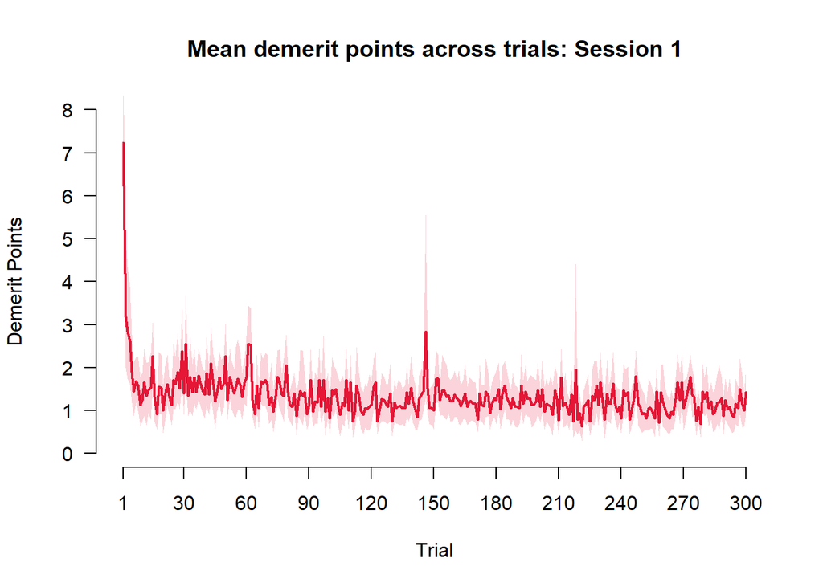

```r
plotR2AllTrackPts()
```

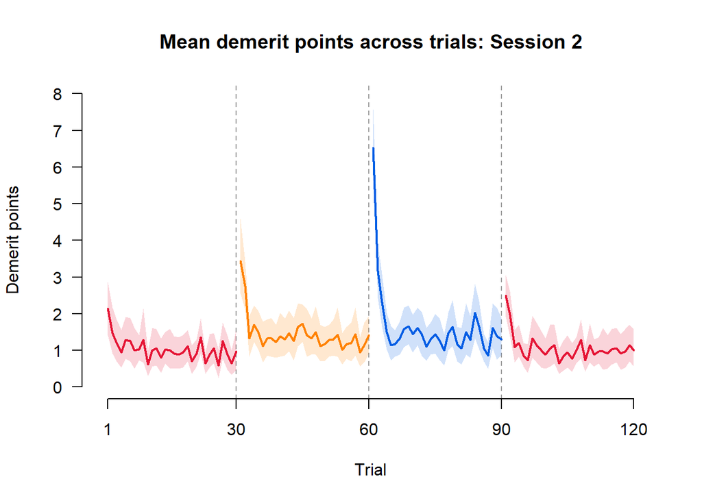

```r
plotR2S2AllTrackPts()
```

Demerit points do not change that much after the first couple of trials (note that trial 1 is shown here but not included in the mean and SD values below).

```r
getR2DemPtsSession1()
```

```
## Mean for trial set 1:
## [1] 2.415789
## SD for trial set 1:
## [1] 2.806703
## Mean for trial set 50:
## [1] 1.232456
## SD for trial set 50:
## [1] 0.8983965
```

```r
getR2DemPtsSession2()
```

```
## Mean for trial set 1:
## [1] 1.244444
## SD for trial set 1:
## [1] 0.7408275
## Mean for trial set 2:
## [1] 0.9074074
## SD for trial set 2:
## [1] 0.7053587
## Mean for trial set 3:
## [1] 1.688889
## SD for trial set 3:
## [1] 0.8437257
## Mean for trial set 4:
## [1] 1.236111
## SD for trial set 4:
## [1] 0.8659108
## Mean for trial set 5:
## [1] 1.861111
## SD for trial set 5:
## [1] 0.9068872
## Mean for trial set 6:
## [1] 1.319444
## SD for trial set 6:
## [1] 0.8293955
## Mean for trial set 7:
## [1] 1.177778
## SD for trial set 7:
## [1] 0.7881664
## Mean for trial set 8:
## [1] 1.041667
## SD for trial set 8:
## [1] 0.7677787
```

### Retention (Accuracy)

Session 1: first block, first set and last block, last set Session 2: first block, first set

#### Frequentist test

We perform a repeated measures one-way ANOVA to test for an effect across trial sets.

```r
retentionR2AccuracyANOVA()
```

```
## Accuracy during first and last set in session 1 and first set in session 2:
## $ANOVA
##   Effect DFn DFd        F          p p<.05        ges
## 2    set   2  70 5.869839 0.00439824     * 0.09459913
##
## $`Mauchly's Test for Sphericity`
##   Effect         W        p p<.05
## 2    set 0.8865486 0.129105
##
## $`Sphericity Corrections`
##   Effect       GGe       p[GG] p[GG]<.05       HFe       p[HF] p[HF]<.05
## 2    set 0.8981083 0.006020661         * 0.9436244 0.005231924         *
```

```r
retentionR2AccuracyComparisonMeans()
```

```
##  set      emmean    SE df lower.CL upper.CL
##  S1_first   95.8 0.597 35     94.6     97.0
##  S1_last    97.5 0.342 35     96.8     98.2
##  S2_1       97.6 0.300 35     97.0     98.2
##  S2_2       97.7 0.349 35     97.0     98.5
##
## Confidence level used: 0.95
```

```r
retentionR2AccuracyComparisonsEffSize()
```

```
##  contrast                              estimate    SE df t.ratio p.value
##  Session 1 Set 1 vs Session 1 Set Last   1.7213 0.608 35   2.832  0.0229
##  Session 1 Set 1 vs Session 2 Set 1      1.7910 0.665 35   2.693  0.0324
##  Session 1 Set Last vs Session 2 Set 1   0.0696 0.490 35   0.142  1.0000
##
## P value adjustment: bonferroni method for 3 tests
##                                contrast   etasquared
## 1 Session 1 Set 1 vs Session 1 Set Last 0.1864480554
## 2    Session 1 Set 1 vs Session 2 Set 1 0.1716258245
## 3 Session 1 Set Last vs Session 2 Set 1 0.0005761284
```

We observe a main effect of set. Follow-up comparisons reveal that this effect is driven by a difference between the first and last sets of session 1, suggesting within session improvements. Moreover, there is also a difference between the first set in session 1 and the first set in session 2.

#### Bayesian test

```r
retentionR2AccuracyBayesANOVA()
```

```
## Accuracy during first and last set in session 1 and first set in session 2:
## Bayes factor analysis
## --------------
## [1] set + participant : 15.94199 ±2.37%
##
## Against denominator:
##   dv ~ participant
## ---
## Bayes factor type: BFlinearModel, JZS
##
## Inclusion Bayes Factors (Model Averaged)
##
##             P(prior) P(posterior) Inclusion BF
## participant     1.00         1.00
## set             0.50         0.94        15.94
##
## * Compared among: all models
## *    Priors odds: uniform-equal
```

```r
retentionR2AccuracyComparisonsBayesfollowup()
```

```
## Bayesian t-test - Session 1 Set 1 vs Session 1 Set Last:
## Bayes factor analysis
## --------------
## [1] Alt., r=0.707 : 5.339631 ±0%
##
## Against denominator:
##   Null, mu = 0
## ---
## Bayes factor type: BFoneSample, JZS
##
## Bayesian t-test - Session 1 Set 1 vs Session 2 Set 1:
## Bayes factor analysis
## --------------
## [1] Alt., r=0.707 : 3.963802 ±0%
##
## Against denominator:
##   Null, mu = 0
## ---
## Bayes factor type: BFoneSample, JZS
##
## Bayesian t-test - Session 1 Set Last vs Session 2 Set 1:
## Bayes factor analysis
## --------------
## [1] Alt., r=0.707 : 0.1807012 ±0.04%
##
## Against denominator:
##   Null, mu = 0
## ---
## Bayes factor type: BFoneSample, JZS
##
## Bayesian t-test - Session 1 Set Last vs Session 2 Set 2:
## Bayes factor analysis
## --------------
## [1] Alt., r=0.707 : 0.208922 ±0.04%
##
## Against denominator:
##   Null, mu = 0
## ---
## Bayes factor type: BFoneSample, JZS
```

Bayesian tests show the same findings as in the frequentist test.

### Generalization (Accuracy)

Next, we compare performance between the novel track conditions and the original trained track. We analyze the first and final sets from session 1, and the first set of the rotated track from session 2.

trained track, Session 1: block 1, first set and block last, last set rotated track, Session 2: block 2, first set

#### Frequentist test

```r
genR2AccuracyANOVA()
```

```
## Accuracy during first and last set in session 1 and first set of rotated track in session 2:
## $ANOVA
##   Effect DFn DFd        F           p p<.05        ges
## 2    set   2  70 5.276617 0.007337143     * 0.07812856
##
## $`Mauchly's Test for Sphericity`
##   Effect         W           p p<.05
## 2    set 0.7594468 0.009299412     *
##
## $`Sphericity Corrections`
##   Effect      GGe      p[GG] p[GG]<.05       HFe      p[HF] p[HF]<.05
## 2    set 0.806092 0.01226765         * 0.8392077 0.01123394         *
```

```r
genR2AccuracyComparisonMeans()
```

```
##  set      emmean    SE df lower.CL upper.CL
##  S1_first   95.8 0.597 35     94.6     97.0
##  S1_last    97.5 0.342 35     96.8     98.2
##  S2_3       95.6 0.504 35     94.6     96.7
##
## Confidence level used: 0.95
```

```r
genR2AccuracyComparisonsEffSize()
```

```
##  contrast                           estimate    SE df t.ratio p.value
##  Session 1 Set 1 vs Session 2 Set 3   -0.145 0.774 35  -0.188  1.0000
##  Session 1 Set 2 vs Session 2 Set 3   -1.867 0.508 35  -3.675  0.0016
##
## P value adjustment: bonferroni method for 2 tests
##                             contrast  etasquared
## 1 Session 1 Set 1 vs Session 2 Set 3 0.001006812
## 2 Session 1 Set 2 vs Session 2 Set 3 0.278403692
```

We observe a main effect of set. Follow-up comparisons show this is driven by a difference between the last set of Session 1 and the first set of the rotated track.

#### Bayesian test

```r
genR2AccuracyBayesANOVA()
```

```
## Accuracy during first and last set in session 1 and first set of rotated track in session 2:
## Bayes factor analysis
## --------------
## [1] set + participant : 7.626963 ±0.62%
##
## Against denominator:
##   dv ~ participant
## ---
## Bayes factor type: BFlinearModel, JZS
##
## Inclusion Bayes Factors (Model Averaged)
##
##             P(prior) P(posterior) Inclusion BF
## participant     1.00         1.00
## set             0.50         0.88         7.63
##
## * Compared among: all models
## *    Priors odds: uniform-equal
```

```r
genR2AccuracyComparisonsBayesfollowup()
```

```
## Bayesian t-test - Session 1 Set 1 vs Session 2 Set 3:
## Bayes factor analysis
## --------------
## [1] Alt., r=0.707 : 0.1819834 ±0.04%
##
## Against denominator:
##   Null, mu = 0
## ---
## Bayes factor type: BFoneSample, JZS
##
## Bayesian t-test - Session 1 Set 2 vs Session 2 Set 3:
## Bayes factor analysis
## --------------
## [1] Alt., r=0.707 : 38.79867 ±0%
##
## Against denominator:
##   Null, mu = 0
## ---
## Bayes factor type: BFoneSample, JZS
```

Bayesian tests show the same findings as in the frequentist test.

### Generalization (Accuracy): with Top Up training as reference

Next, we compare how performance is affected when participants encounter the track rotated by 180 degrees:

trained track, Session 2: block 1, first set and block 1, last set rotated track, Session 2: block 2, first set and block 2, last set

#### Frequentist test

```r
genR2TopUpAccuracyANOVA()
```

```
## Accuracy during first block in session 2 and second block in session 2:
## $ANOVA
##   Effect DFn DFd        F            p p<.05       ges
## 2    set   3 105 7.138269 0.0002074042     * 0.1140982
##
## $`Mauchly's Test for Sphericity`
##   Effect         W         p p<.05
## 2    set 0.8427626 0.3295431
##
## $`Sphericity Corrections`
##   Effect       GGe        p[GG] p[GG]<.05       HFe       p[HF] p[HF]<.05
## 2    set 0.9042439 0.0003656052         * 0.9875755 0.000223206         *
```

```r
genR2TopUpAccuracyComparisonMeans()
```

```
##  set  emmean    SE df lower.CL upper.CL
##  S2_1   97.6 0.300 35     97.0     98.2
##  S2_2   97.7 0.349 35     97.0     98.5
##  S2_3   95.6 0.504 35     94.6     96.7
##  S2_4   96.9 0.387 35     96.1     97.6
##
## Confidence level used: 0.95
```

```r
genR2TopUpAccuracyComparisonsEffSize()
```

```
##  contrast                           estimate    SE df t.ratio p.value
##  Session 1 Set 1 vs Session 2 Set 3   -0.145 0.774 35  -0.188  1.0000
##  Session 1 Set 2 vs Session 2 Set 3   -1.867 0.508 35  -3.675  0.0016
##
## P value adjustment: bonferroni method for 2 tests
##                             contrast  etasquared
## 1 Session 1 Set 1 vs Session 2 Set 3 0.001006812
## 2 Session 1 Set 2 vs Session 2 Set 3 0.278403692
```

We observe a main effect of set. Follow-up comparisons indicate that this effect is driven by a difference between the first and last sets in the trained track and first set in the rotated track. #### Bayesian test

```r
genR2TopUpAccuracyBayesANOVA()
```

```
## Accuracy during first block in session 2 and second block in session 2:
## Bayes factor analysis
## --------------
## [1] set + participant : 194.4491 ±0.85%
##
## Against denominator:
##   dv ~ participant
## ---
## Bayes factor type: BFlinearModel, JZS
##
## Inclusion Bayes Factors (Model Averaged)
##
##             P(prior) P(posterior) Inclusion BF
## participant     1.00         1.00
## set             0.50         0.99       194.45
##
## * Compared among: all models
## *    Priors odds: uniform-equal
```

```r
genR2TopUpAccuracyComparisonsBayesfollowup()
```

```
## Bayesian t-test - Session 2 Set 1 vs Set 3:
## Bayes factor analysis
## --------------
## [1] Alt., r=0.707 : 14.09152 ±0%
##
## Against denominator:
##   Null, mu = 0
## ---
## Bayes factor type: BFoneSample, JZS
##
## Bayesian t-test - Session 2 Set 2 vs Set 3:
## Bayes factor analysis
## --------------
## [1] Alt., r=0.707 : 87.13476 ±0%
##
## Against denominator:
##   Null, mu = 0
## ---
## Bayes factor type: BFoneSample, JZS
##
## Bayesian t-test - Session 2 Set 2 vs Set 4:
## Bayes factor analysis
## --------------
## [1] Alt., r=0.707 : 0.7149042 ±0.03%
##
## Against denominator:
##   Null, mu = 0
## ---
## Bayes factor type: BFoneSample, JZS
```

Bayesian tests show the same findings as in the frequentist test.

### Reverse track (Accuracy)

We analyze the first and final sets from session 1, and the first set of the reverse track from session 2.

trained track, Session 1: block 1, first set and block last, last set reverse track, Session 2: block 3, first set

#### Frequentist test

```r
revR2AccuracyANOVA()
```

```
## Accuracy during first and last set in session 1 and first set of reverse track in session 2:
## $ANOVA
##   Effect DFn DFd        F           p p<.05        ges
## 2    set   2  70 5.335025 0.006974291     * 0.08394339
##
## $`Mauchly's Test for Sphericity`
##   Effect         W          p p<.05
## 2    set 0.7764025 0.01353561     *
##
## $`Sphericity Corrections`
##   Effect       GGe      p[GG] p[GG]<.05       HFe     p[HF] p[HF]<.05
## 2    set 0.8172622 0.01140879         * 0.8518218 0.0103923         *
```

```r
revR2AccuracyComparisonMeans()
```

```
##  set      emmean    SE df lower.CL upper.CL
##  S1_first   95.8 0.597 35     94.6     97.0
##  S1_last    97.5 0.342 35     96.8     98.2
##  S2_5       95.3 0.600 35     94.1     96.5
##
## Confidence level used: 0.95
```

```r
revR2AccuracyComparisonsEffSize()
```

```
##  contrast                           estimate    SE df t.ratio p.value
##  Session 1 Set 1 vs Session 2 Set 5   -0.475 0.858 35  -0.553  1.0000
##  Session 1 Set 2 vs Session 2 Set 5   -2.196 0.629 35  -3.492  0.0026
##
## P value adjustment: bonferroni method for 2 tests
##                             contrast  etasquared
## 1 Session 1 Set 1 vs Session 2 Set 5 0.008676605
## 2 Session 1 Set 2 vs Session 2 Set 5 0.258362029
```

We observe a main effect of set. Follow-up comparisons indicate that this effect is driven by a difference between the last set of Session 1 and the first set of the reverse track.

#### Bayesian test

```r
revR2AccuracyBayesANOVA()
```

```
## Accuracy during first and last set in session 1 and first set of reverse track in session 2:
## Bayes factor analysis
## --------------
## [1] set + participant : 9.781995 ±7.41%
##
## Against denominator:
##   dv ~ participant
## ---
## Bayes factor type: BFlinearModel, JZS
##
## Inclusion Bayes Factors (Model Averaged)
##
##             P(prior) P(posterior) Inclusion BF
## participant     1.00         1.00
## set             0.50         0.91         9.78
##
## * Compared among: all models
## *    Priors odds: uniform-equal
```

```r
revR2AccuracyComparisonsBayesfollowup()
```

```
## Bayesian t-test - Session 1 Set 1 vs Session 2 Set 5:
## Bayes factor analysis
## --------------
## [1] Alt., r=0.707 : 0.2065108 ±0.04%
##
## Against denominator:
##   Null, mu = 0
## ---
## Bayes factor type: BFoneSample, JZS
##
## Bayesian t-test - Session 1 Set 2 vs Session 2 Set 5:
## Bayes factor analysis
## --------------
## [1] Alt., r=0.707 : 24.65143 ±0%
##
## Against denominator:
##   Null, mu = 0
## ---
## Bayes factor type: BFoneSample, JZS
```

Bayesian tests show the same findings as in the frequentist test.

### Reverse track (Accuracy): with Top Up training as reference

Next, we compare how performance is affected when participants move through the track in reverse:

trained track, Session 2: block 1, first set and block 1, last set reverse track, Session 2: block 2, first set and block 2, last set

#### Frequentist test

```r
revR2TopUpAccuracyANOVA()
```

```
## Accuracy during first block in session 2 and third block in session 2:
## $ANOVA
##   Effect DFn DFd        F            p p<.05       ges
## 2    set   3 105 8.666577 3.433738e-05     * 0.1319439
##
## $`Mauchly's Test for Sphericity`
##   Effect         W          p p<.05
## 2    set 0.6478389 0.01205718     *
##
## $`Sphericity Corrections`
##   Effect       GGe        p[GG] p[GG]<.05       HFe        p[HF] p[HF]<.05
## 2    set 0.7623438 0.0002086151         * 0.8185655 0.0001359168         *
```

```r
revR2TopUpAccuracyComparisonMeans()
```

```
##  set  emmean    SE df lower.CL upper.CL
##  S2_1   97.6 0.300 35     97.0     98.2
##  S2_2   97.7 0.349 35     97.0     98.5
##  S2_5   95.3 0.600 35     94.1     96.5
##  S2_6   96.8 0.361 35     96.0     97.5
##
## Confidence level used: 0.95
```

```r
revR2TopUpAccuracyComparisonsEffSize()
```

```
##  contrast                           estimate    SE df t.ratio p.value
##  Session 1 Set 1 vs Session 2 Set 5   -0.475 0.858 35  -0.553  1.0000
##  Session 1 Set 2 vs Session 2 Set 5   -2.196 0.629 35  -3.492  0.0026
##
## P value adjustment: bonferroni method for 2 tests
##                             contrast  etasquared
## 1 Session 1 Set 1 vs Session 2 Set 5 0.008676605
## 2 Session 1 Set 2 vs Session 2 Set 5 0.258362029
```

We observe a main effect of set. Follow-up comparisons indicate that accuracy for the first set in the reverse track is lower than both first and last sets in the trained track.

#### Bayesian test

```r
revR2TopUpAccuracyBayesANOVA()
```

```
## Accuracy during first block in session 2 and third block in session 2:
## Bayes factor analysis
## --------------
## [1] set + participant : 1037.597 ±0.49%
##
## Against denominator:
##   dv ~ participant
## ---
## Bayes factor type: BFlinearModel, JZS
##
## Inclusion Bayes Factors (Model Averaged)
##
##             P(prior) P(posterior) Inclusion BF
## participant     1.00         1.00
## set             0.50         1.00     1.04e+03
##
## * Compared among: all models
## *    Priors odds: uniform-equal
```

```r
revR2TopUpAccuracyComparisonsBayesfollowup()
```

```
## Bayesian t-test - Session 2 Set 1 vs Set 5:
## Bayes factor analysis
## --------------
## [1] Alt., r=0.707 : 14.61706 ±0%
##
## Against denominator:
##   Null, mu = 0
## ---
## Bayes factor type: BFoneSample, JZS
##
## Bayesian t-test - Session 2 Set 2 vs Set 5:
## Bayes factor analysis
## --------------
## [1] Alt., r=0.707 : 313.4101 ±0%
##
## Against denominator:
##   Null, mu = 0
## ---
## Bayes factor type: BFoneSample, JZS
##
## Bayesian t-test - Session 2 Set 2 vs Set 6:
## Bayes factor analysis
## --------------
## [1] Alt., r=0.707 : 2.403719 ±0%
##
## Against denominator:
##   Null, mu = 0
## ---
## Bayes factor type: BFoneSample, JZS
```

Bayesian tests show the same findings as in the frequentist test.

### Trained track (Accuracy)

#### T-test

We may simply compare the first set in the last trained track block with the last set of the first trained track block in session 2.

```r
trainR2AccuracyTtest()
```

```
## Session 2 Set 2 vs. Session 2 Set 7:
##
##  Paired t-test
##
## data:  subdat1$dv and subdat2$dv
## t = 0.60794, df = 35, p-value = 0.5471
## alternative hypothesis: true mean difference is not equal to 0
## 95 percent confidence interval:
##  -0.5942685  1.1023416
## sample estimates:
## mean difference
##       0.2540366
##
## Effect Size - Cohen d:
## [1] 0.1210998
```

We do not find a difference between the two trial sets.

Next, we compare performance between the first and last blocks in session 2, to assess whether the other track conditions has interfered with learning in the trained track.

trained track, Session 2: block 1, first set and block 1, last set trained track, Session 2: block 4, first set and block 4, last set

#### Frequentist test

```r
trainR2AccuracyANOVA()
```

```
## Accuracy during first block in session 2 and last block in session 2:
## $ANOVA
##   Effect DFn DFd         F         p p<.05         ges
## 2    set   3 105 0.1831179 0.9076603       0.003193003
##
## $`Mauchly's Test for Sphericity`
##   Effect        W         p p<.05
## 2    set 0.921555 0.7378126
##
## $`Sphericity Corrections`
##   Effect       GGe    p[GG] p[GG]<.05      HFe     p[HF] p[HF]<.05
## 2    set 0.9500965 0.899417           1.043145 0.9076603
```

```r
trainR2AccuracyComparisonMeans()
```

```
##  set  emmean    SE df lower.CL upper.CL
##  S2_1   97.6 0.300 35     97.0     98.2
##  S2_2   97.7 0.349 35     97.0     98.5
##  S2_7   97.5 0.350 35     96.8     98.2
##  S2_8   97.5 0.313 35     96.8     98.1
##
## Confidence level used: 0.95
```

We do not observe an effect of set, suggesting no accuracy differences between the first and last blocks in session 2.

#### Bayesian test

```r
trainR2AccuracyBayesANOVA()
```

```
## Accuracy during first block in session 2 and last block in session 2:
## Bayes factor analysis
## --------------
## [1] set + participant : 0.0462962 ±2.02%
##
## Against denominator:
##   dv ~ participant
## ---
## Bayes factor type: BFlinearModel, JZS
##
## Inclusion Bayes Factors (Model Averaged)
##
##             P(prior) P(posterior) Inclusion BF
## participant     1.00         1.00
## set             0.50         0.04        0.046
##
## * Compared among: all models
## *    Priors odds: uniform-equal
```

```r
trainR2AccuracyComparisonsBayesfollowup()
```

```
## Bayesian t-test - Session 2 Set 1 vs Set 7:
## Bayes factor analysis
## --------------
## [1] Alt., r=0.707 : 0.1809275 ±0.04%
##
## Against denominator:
##   Null, mu = 0
## ---
## Bayes factor type: BFoneSample, JZS
##
## Bayesian t-test - Session 2 Set 2 vs Set 7:
## Bayes factor analysis
## --------------
## [1] Alt., r=0.707 : 0.2126661 ±0.04%
##
## Against denominator:
##   Null, mu = 0
## ---
## Bayes factor type: BFoneSample, JZS
##
## Bayesian t-test - Session 2 Set 2 vs Set 8:
## Bayes factor analysis
## --------------
## [1] Alt., r=0.707 : 0.2277476 ±0.04%
##
## Against denominator:
##   Null, mu = 0
## ---
## Bayes factor type: BFoneSample, JZS
```

Bayesian tests show the same findings as in the frequentist test.

## Speed and Accuracy

We plot speed and accuracy functions below. Note that both speed and accuracy measures improve with training within blocks and across sessions.

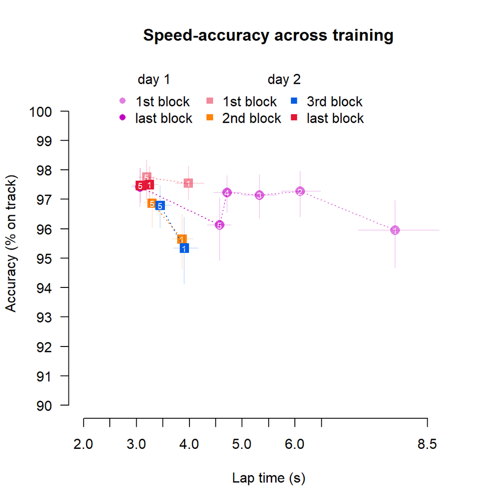

```r
plotR2SAF()
```

We also explored whether within session improvements in session 1 are associated with the amount of offline gains observed with the accuracy measure.

To calculate for within session improvements: First, we take the accuracy differences between the first and last sets in session 1 across participants. We then normalize these values to range from -1 to 1 using the equation:

Xnorm = 2 * ((X - Xmin)/(Xmax - Xmin)) - 1

To calculate for Offline gains: We take the accuracy differences between the last set of session 1 and the first set of session 2 across participants, before normalizing values using the same equation above.

Finally, we assess the relationship of the values using a Pearson’s correlation test.

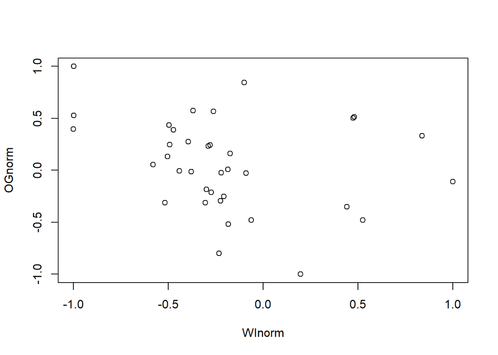

```
##
##  Pearson's product-moment correlation
##
## data:  WInorm and OGnorm
## t = -1.7066, df = 34, p-value = 0.09702
## alternative hypothesis: true correlation is not equal to 0
## 95 percent confidence interval:
##  -0.55794152  0.05248435
## sample estimates:
##        cor
## -0.2808949
```

```r
getR2WithinImprovementOfflineGainsAcc()
```

Although we observe a negative association between within session improvements and offline gains, this relationship is not statistically significant (r = -0.2808949, p = 0.09702).

## Movement Efficiency (Path Length)

Next, we repeat the same analyses steps as with the speed and accuracy measures, but now use Path length as the dependent variable.

### Retention (Path Length)

Session 1: first block, first set and last block, last set Session 2: first block, first set

#### Frequentist test

We perform a repeated measures one-way ANOVA to test for an effect across trial sets.

```r
retentionR2PLANOVA()
```

```
## Path Length during first and last set in session 1 and first set in session 2:
## $ANOVA
##   Effect DFn DFd        F           p p<.05       ges
## 2    set   2  70 29.90053 4.10859e-10     * 0.3280234
##
## $`Mauchly's Test for Sphericity`
##   Effect         W           p p<.05
## 2    set 0.7318092 0.004951811     *
##
## $`Sphericity Corrections`
##   Effect       GGe      p[GG] p[GG]<.05       HFe        p[HF] p[HF]<.05
## 2    set 0.7885249 1.9467e-08         * 0.8194039 1.107115e-08         *
```

```r
retentionR2PLComparisonMeans()
```

```
##  set      emmean      SE df lower.CL upper.CL
##  S1_first  49.96 0.18241 35    49.59    50.33
##  S1_last   48.83 0.08485 35    48.66    49.00
##  S2_1      48.85 0.09095 35    48.67    49.04
##  S2_2      48.67 0.08031 35    48.51    48.83
##
## Confidence level used: 0.95
```

```r
retentionR2PLComparisonsEffSize()
```

```
##  contrast                              estimate    SE df t.ratio p.value
##  Session 1 Set 1 vs Session 1 Set Last  -1.1299 0.199 35  -5.690  <.0001
##  Session 1 Set 1 vs Session 2 Set 1     -1.1051 0.172 35  -6.431  <.0001
##  Session 1 Set Last vs Session 2 Set 1   0.0248 0.121 35   0.205  1.0000
##
## P value adjustment: bonferroni method for 3 tests
##                                contrast  etasquared
## 1 Session 1 Set 1 vs Session 1 Set Last 0.480567117
## 2    Session 1 Set 1 vs Session 2 Set 1 0.541658638
## 3 Session 1 Set Last vs Session 2 Set 1 0.001198869
```

We observe a main effect of set. Follow-up comparisons show within session improvements in session 1, and a difference in path length between the first sets in each session.

#### Bayesian test

```r
retentionR2PLBayesANOVA()
```

```
## Path Length during first and last set in session 1 and first set in session 2:
## Bayes factor analysis
## --------------
## [1] set + participant : 346310109 ±1%
##
## Against denominator:
##   dv ~ participant
## ---
## Bayes factor type: BFlinearModel, JZS
##
## Inclusion Bayes Factors (Model Averaged)
##
##             P(prior) P(posterior) Inclusion BF
## participant     1.00         1.00
## set             0.50         1.00     3.46e+08
##
## * Compared among: all models
## *    Priors odds: uniform-equal
```

```r
retentionR2PLComparisonsBayesfollowup()
```

```
## Bayesian t-test - Session 1 Set 1 vs Session 1 Set Last:
## Bayes factor analysis
## --------------
## [1] Alt., r=0.707 : 9177.721 ±0%
##
## Against denominator:
##   Null, mu = 0
## ---
## Bayes factor type: BFoneSample, JZS
##
## Bayesian t-test - Session 1 Set 1 vs Session 2 Set 1:
## Bayes factor analysis
## --------------
## [1] Alt., r=0.707 : 74244.76 ±0%
##
## Against denominator:
##   Null, mu = 0
## ---
## Bayes factor type: BFoneSample, JZS
##
## Bayesian t-test - Session 1 Set Last vs Session 2 Set 1:
## Bayes factor analysis
## --------------
## [1] Alt., r=0.707 : 0.1825582 ±0.04%
##
## Against denominator:
##   Null, mu = 0
## ---
## Bayes factor type: BFoneSample, JZS
##
## Bayesian t-test - Session 1 Set Last vs Session 2 Set 2:
## Bayes factor analysis
## --------------
## [1] Alt., r=0.707 : 0.5035219 ±0.03%
##
## Against denominator:
##   Null, mu = 0
## ---
## Bayes factor type: BFoneSample, JZS
```

Bayesian tests show the same findings as in the frequentist test.

### Generalization (Path Length)

Next, we compare performance between the novel track conditions and the original trained track. We analyze the first and final sets from session 1, and the first set of the rotated track from session 2.

trained track, Session 1: block 1, first set and block last, last set rotated track, Session 2: block 2, first set

#### Frequentist test

```r
genR2PLANOVA()
```

```
## Path length during first and last set in session 1 and first set of rotated track in session 2:
## $ANOVA
##   Effect DFn DFd        F            p p<.05       ges
## 2    set   2  70 20.64719 8.950947e-08     * 0.2692429
##
## $`Mauchly's Test for Sphericity`
##   Effect         W          p p<.05
## 2    set 0.8245728 0.03766112     *
##
## $`Sphericity Corrections`
##   Effect       GGe        p[GG] p[GG]<.05       HFe        p[HF] p[HF]<.05
## 2    set 0.8507545 6.276866e-07         * 0.8897449 3.771129e-07         *
```

```r
genR2PLComparisonMeans()
```

```
##  set      emmean      SE df lower.CL upper.CL
##  S1_first  49.96 0.18241 35    49.59    50.33
##  S1_last   48.83 0.08485 35    48.66    49.00
##  S2_3      49.19 0.10571 35    48.97    49.40
##
## Confidence level used: 0.95
```

```r
genR2PLComparisonsEffSize()
```

```
##  contrast                           estimate    SE df t.ratio p.value
##  Session 1 Set 1 vs Session 2 Set 3   -0.769 0.196 35  -3.914  0.0008
##  Session 1 Set 2 vs Session 2 Set 3    0.361 0.137 35   2.636  0.0248
##
## P value adjustment: bonferroni method for 2 tests
##                             contrast etasquared
## 1 Session 1 Set 1 vs Session 2 Set 3  0.3044000
## 2 Session 1 Set 2 vs Session 2 Set 3  0.1656876
```

We observe a main effect of set. Follow-up comparisons show that this is driven by the difference between both the first and last sets of session 1 when each is compared with the first rotated track set.

#### Bayesian test

```r
genR2PLBayesANOVA()
```

```
## Path length during first and last set in session 1 and first set of rotated track in session 2:
## Bayes factor analysis
## --------------
## [1] set + participant : 1686998 ±0.76%
##
## Against denominator:
##   dv ~ participant
## ---
## Bayes factor type: BFlinearModel, JZS
##
## Inclusion Bayes Factors (Model Averaged)
##
##             P(prior) P(posterior) Inclusion BF
## participant     1.00         1.00
## set             0.50         1.00     1.69e+06
##
## * Compared among: all models
## *    Priors odds: uniform-equal
```

```r
genR2PLComparisonsBayesfollowup()
```

```
## Bayesian t-test - Session 1 Set 1 vs Session 2 Set 3:
## Bayes factor analysis
## --------------
## [1] Alt., r=0.707 : 71.26561 ±0%
##
## Against denominator:
##   Null, mu = 0
## ---
## Bayes factor type: BFoneSample, JZS
##
## Bayesian t-test - Session 1 Set 2 vs Session 2 Set 3:
## Bayes factor analysis
## --------------
## [1] Alt., r=0.707 : 3.523208 ±0%
##
## Against denominator:
##   Null, mu = 0
## ---
## Bayes factor type: BFoneSample, JZS
```

Bayesian tests show the same findings as the frequentist tests.

### Generalization (Path Length): with Top Up training as reference

Next, we compare how performance is affected when participants encounter the track rotated by 180 degrees:

trained track, Session 2: block 1, first set and block 1, last set rotated track, Session 2: block 2, first set and block 2, last set

#### Frequentist test

```r
genR2TopUpPLANOVA()
```

```
## Path length during first block in session 2 and second block in session 2:
## $ANOVA
##   Effect DFn DFd        F            p p<.05        ges
## 2    set   3 105 6.304408 0.0005652126     * 0.09994492
##
## $`Mauchly's Test for Sphericity`
##   Effect         W         p p<.05
## 2    set 0.8944233 0.5842189
##
## $`Sphericity Corrections`
##   Effect       GGe        p[GG] p[GG]<.05      HFe        p[HF] p[HF]<.05
## 2    set 0.9352262 0.0007819267         * 1.025071 0.0005652126         *
```

```r
genR2TopUpPLComparisonMeans()
```

```
##  set  emmean      SE df lower.CL upper.CL
##  S2_1  48.85 0.09095 35    48.67    49.04
##  S2_2  48.67 0.08031 35    48.51    48.83
##  S2_3  49.19 0.10571 35    48.97    49.40
##  S2_4  48.97 0.10210 35    48.76    49.18
##
## Confidence level used: 0.95
```

```r
genR2TopUpPLComparisonsEffSize()
```

```
##  contrast                           estimate    SE df t.ratio p.value
##  Session 1 Set 1 vs Session 2 Set 3   -0.769 0.196 35  -3.914  0.0008
##  Session 1 Set 2 vs Session 2 Set 3    0.361 0.137 35   2.636  0.0248
##
## P value adjustment: bonferroni method for 2 tests
##                             contrast etasquared
## 1 Session 1 Set 1 vs Session 2 Set 3  0.3044000
## 2 Session 1 Set 2 vs Session 2 Set 3  0.1656876
```

We observe a main effect of set. Follow-up comparisons show that path lengths are longer in the rotated track trials compared to trained track trials.

#### Bayesian test

```r
genR2TopUpPLBayesANOVA()
```

```
## Path length during first block in session 2 and second block in session 2:
## Bayes factor analysis
## --------------
## [1] set + participant : 68.28159 ±0.54%
##
## Against denominator:
##   dv ~ participant
## ---
## Bayes factor type: BFlinearModel, JZS
##
## Inclusion Bayes Factors (Model Averaged)
##
##             P(prior) P(posterior) Inclusion BF
## participant     1.00         1.00
## set             0.50         0.99        68.28
##
## * Compared among: all models
## *    Priors odds: uniform-equal
```

```r
genR2TopUpPLComparisonsBayesfollowup()
```

```
## Bayesian t-test - Session 2 Set 1 vs Set 3:
## Bayes factor analysis
## --------------
## [1] Alt., r=0.707 : 3.284402 ±0%
##
## Against denominator:
##   Null, mu = 0
## ---
## Bayes factor type: BFoneSample, JZS
##
## Bayesian t-test - Session 2 Set 2 vs Set 3:
## Bayes factor analysis
## --------------
## [1] Alt., r=0.707 : 189.4477 ±0%
##
## Against denominator:
##   Null, mu = 0
## ---
## Bayes factor type: BFoneSample, JZS
##
## Bayesian t-test - Session 2 Set 2 vs Set 4:
## Bayes factor analysis
## --------------
## [1] Alt., r=0.707 : 3.434647 ±0%
##
## Against denominator:
##   Null, mu = 0
## ---
## Bayes factor type: BFoneSample, JZS
```

Bayesian tests show the same findings as in the frequentist test.

### Reverse track (Path Length)

We analyze the first and final sets from session 1, and the first set of the reverse track from session 2.

trained track, Session 1: block 1, first set and block last, last set reverse track, Session 2: block 3, first set

#### Frequentist test

```r
revR2PLANOVA()
```

```
## Path length during first and last set in session 1 and first set of reverse track in session 2:
## $ANOVA
##   Effect DFn DFd        F            p p<.05       ges
## 2    set   2  70 21.76613 4.459182e-08     * 0.2750004
##
## $`Mauchly's Test for Sphericity`
##   Effect         W          p p<.05
## 2    set 0.7731509 0.01260353     *
##
## $`Sphericity Corrections`
##   Effect       GGe        p[GG] p[GG]<.05       HFe        p[HF] p[HF]<.05
## 2    set 0.8150961 5.639144e-07         * 0.8493744 3.520174e-07         *
```

```r
revR2PLComparisonMeans()
```

```
##  set      emmean      SE df lower.CL upper.CL
##  S1_first  49.96 0.18241 35    49.59    50.33
##  S1_last   48.83 0.08485 35    48.66    49.00
##  S2_5      49.16 0.10104 35    48.96    49.37
##
## Confidence level used: 0.95
```

```r
revR2PLComparisonsEffSize()
```

```
##  contrast                           estimate    SE df t.ratio p.value
##  Session 1 Set 1 vs Session 2 Set 5   -0.793 0.193 35  -4.117  0.0004
##  Session 1 Set 2 vs Session 2 Set 5    0.337 0.127 35   2.646  0.0243
##
## P value adjustment: bonferroni method for 2 tests
##                             contrast etasquared
## 1 Session 1 Set 1 vs Session 2 Set 5  0.3262804
## 2 Session 1 Set 2 vs Session 2 Set 5  0.1666441
```

We observe a main effect of set. Follow-up comparisons indicate that this effect is driven by a difference between both the first and last sets of Session 1, when each is compared with the first set of the reverse track.

#### Bayesian test

```r
revR2PLBayesANOVA()
```

```
## Path length during first and last set in session 1 and first set of reverse track in session 2:
## Bayes factor analysis
## --------------
## [1] set + participant : 3165697 ±3.99%
##
## Against denominator:
##   dv ~ participant
## ---
## Bayes factor type: BFlinearModel, JZS
##
## Inclusion Bayes Factors (Model Averaged)
##
##             P(prior) P(posterior) Inclusion BF
## participant     1.00         1.00
## set             0.50         1.00     3.17e+06
##
## * Compared among: all models
## *    Priors odds: uniform-equal
```

```r
revR2PLComparisonsBayesfollowup()
```

```
## Bayesian t-test - Session 1 Set 1 vs Session 2 Set 5:
## Bayes factor analysis
## --------------
## [1] Alt., r=0.707 : 121.0745 ±0%
##
## Against denominator:
##   Null, mu = 0
## ---
## Bayes factor type: BFoneSample, JZS
##
## Bayesian t-test - Session 1 Set 2 vs Session 2 Set 5:
## Bayes factor analysis
## --------------
## [1] Alt., r=0.707 : 3.590504 ±0%
##
## Against denominator:
##   Null, mu = 0
## ---
## Bayes factor type: BFoneSample, JZS
```

Bayesian tests show the same findings as in the frequentist test.

### Reverse track (Path Length): with Top Up training as reference

Next, we compare how performance is affected when participants move through the track in reverse:

#### Frequentist test

```r
revR2TopUpPLANOVA()
```

```
## Path length during first block in session 2 and third block in session 2:
## $ANOVA
##   Effect DFn DFd        F          p p<.05        ges
## 2    set   3 105 5.144282 0.00233442     * 0.09418558
##
## $`Mauchly's Test for Sphericity`
##   Effect         W          p p<.05
## 2    set 0.6610017 0.01590396     *
##
## $`Sphericity Corrections`
##   Effect       GGe       p[GG] p[GG]<.05       HFe       p[HF] p[HF]<.05
## 2    set 0.7733091 0.005486684         * 0.8314688 0.004402002         *
```

```r
revR2TopUpPLComparisonMeans()
```

```
##  set  emmean      SE df lower.CL upper.CL
##  S2_1  48.85 0.09095 35    48.67    49.04
##  S2_2  48.67 0.08031 35    48.51    48.83
##  S2_5  49.16 0.10104 35    48.96    49.37
##  S2_6  49.14 0.14560 35    48.84    49.43
##
## Confidence level used: 0.95
```

```r
revR2TopUpPLComparisonsEffSize()
```

```
##  contrast                           estimate    SE df t.ratio p.value
##  Session 1 Set 1 vs Session 2 Set 5   -0.793 0.193 35  -4.117  0.0004
##  Session 1 Set 2 vs Session 2 Set 5    0.337 0.127 35   2.646  0.0243
##
## P value adjustment: bonferroni method for 2 tests
##                             contrast etasquared
## 1 Session 1 Set 1 vs Session 2 Set 5  0.3262804
## 2 Session 1 Set 2 vs Session 2 Set 5  0.1666441
```

We observe a main effect of set. Follow-up comparisons indicate that path length in the reverse track is increased compared to the last set in the trained track.

#### Bayesian test

```r
revR2TopUpPLBayesANOVA()
```

```
## Path length during first block in session 2 and third block in session 2:
## Bayes factor analysis
## --------------
## [1] set + participant : 23.74551 ±0.51%
##
## Against denominator:
##   dv ~ participant
## ---
## Bayes factor type: BFlinearModel, JZS
##
## Inclusion Bayes Factors (Model Averaged)
##
##             P(prior) P(posterior) Inclusion BF
## participant     1.00         1.00
## set             0.50         0.96        23.75
##
## * Compared among: all models
## *    Priors odds: uniform-equal
```

```r
revR2TopUpPLComparisonsBayesfollowup()
```

```
## Bayesian t-test - Session 2 Set 1 vs Set 5:
## Bayes factor analysis
## --------------
## [1] Alt., r=0.707 : 2.394882 ±0%
##
## Against denominator:
##   Null, mu = 0
## ---
## Bayes factor type: BFoneSample, JZS
##
## Bayesian t-test - Session 2 Set 2 vs Set 5:
## Bayes factor analysis
## --------------
## [1] Alt., r=0.707 : 116.5902 ±0%
##
## Against denominator:
##   Null, mu = 0
## ---
## Bayes factor type: BFoneSample, JZS
##
## Bayesian t-test - Session 2 Set 2 vs Set 6:
## Bayes factor analysis
## --------------
## [1] Alt., r=0.707 : 3.20661 ±0%
##
## Against denominator:
##   Null, mu = 0
## ---
## Bayes factor type: BFoneSample, JZS
```

Bayesian tests show the same findings as in the frequentist test.

### Trained track (Path Length)

#### T-test

We may simply compare the first set in the last trained track block with the last set of the first trained track block in session 2.

```r
trainR2PLTtest()
```

```
## Session 2 Set 2 vs. Session 2 Set 7:
##
##  Paired t-test
##
## data:  subdat1$dv and subdat2$dv
## t = -4.4681, df = 35, p-value = 7.905e-05
## alternative hypothesis: true mean difference is not equal to 0
## 95 percent confidence interval:
##  -0.7301010 -0.2739167
## sample estimates:
## mean difference
##      -0.5020089
##
## Effect Size - Cohen d:
## [1] 0.9954486
```

We find a difference between the two trial sets.

Next, we compare performance between the first and last blocks in session 2, to assess whether the other track conditions has interfered with learning in the trained track.

trained track, Session 2: block 1, first set and block 1, last set trained track, Session 2: block 4, first set and block 4, last set

#### Frequentist test

```r
trainR2PLANOVA()
```

```
## Path Length during first block in session 2 and last block in session 2:
## $ANOVA
##   Effect DFn DFd       F            p p<.05      ges
## 2    set   3 105 7.50108 0.0001347086     * 0.122937
##
## $`Mauchly's Test for Sphericity`
##   Effect         W         p p<.05
## 2    set 0.8412452 0.3233308
##
## $`Sphericity Corrections`
##   Effect       GGe       p[GG] p[GG]<.05       HFe       p[HF] p[HF]<.05
## 2    set 0.9073958 0.000241706         * 0.9913802 0.000142229         *
```

```r
trainR2PLComparisonMeans()
```

```
##  set  emmean      SE df lower.CL upper.CL
##  S2_1  48.85 0.09095 35    48.67    49.04
##  S2_2  48.67 0.08031 35    48.51    48.83
##  S2_7  49.17 0.08763 35    49.00    49.35
##  S2_8  49.03 0.08000 35    48.86    49.19
##
## Confidence level used: 0.95
```

```r
trainR2PLComparisonsEffSize()
```

```
##  contrast                           estimate     SE df t.ratio p.value
##  Session 2 Set 1 vs Session 2 Set 7    0.321 0.1222 35   2.622  0.0386
##  Session 2 Set 2 vs Session 2 Set 7    0.502 0.1124 35   4.468  0.0002
##  Session 2 Set 2 vs Session 2 Set 8    0.355 0.0931 35   3.812  0.0016
##
## P value adjustment: bonferroni method for 3 tests
##                             contrast etasquared
## 1 Session 2 Set 1 vs Session 2 Set 7  0.1641840
## 2 Session 2 Set 2 vs Session 2 Set 7  0.3632157
## 3 Session 2 Set 2 vs Session 2 Set 8  0.2933601
```

We observe a main effect of set. Follow up comparisons show that path lengths are longer during the last block of trials compared to the first block.

#### Bayesian test

```r
trainR2PLBayesANOVA()
```

```
## Path Length during first block in session 2 and last block in session 2:
## Bayes factor analysis
## --------------
## [1] set + participant : 331.8841 ±1.13%
##
## Against denominator:
##   dv ~ participant
## ---
## Bayes factor type: BFlinearModel, JZS
##
## Inclusion Bayes Factors (Model Averaged)
##
##             P(prior) P(posterior) Inclusion BF
## participant     1.00         1.00
## set             0.50         1.00       331.88
##
## * Compared among: all models
## *    Priors odds: uniform-equal
```

```r
trainR2PLComparisonsBayesfollowup()
```

```
## Bayesian t-test - Session 2 Set 1 vs Set 7:
## Bayes factor analysis
## --------------
## [1] Alt., r=0.707 : 3.420109 ±0%
##
## Against denominator:
##   Null, mu = 0
## ---
## Bayes factor type: BFoneSample, JZS
##
## Bayesian t-test - Session 2 Set 2 vs Set 7:
## Bayes factor analysis
## --------------
## [1] Alt., r=0.707 : 308.7488 ±0%
##
## Against denominator:
##   Null, mu = 0
## ---
## Bayes factor type: BFoneSample, JZS
##
## Bayesian t-test - Session 2 Set 2 vs Set 8:
## Bayes factor analysis
## --------------
## [1] Alt., r=0.707 : 54.89178 ±0%
##
## Against denominator:
##   Null, mu = 0
## ---
## Bayes factor type: BFoneSample, JZS
```

Bayesian tests show the same findings as in the frequentist test.

## Movement Efficiency INSIDE track (Path Length inside)

Next, we repeat the same analyses steps as in the previous section, but now use Path length inside the track as the dependent variable.

### Retention (Path Length inside)

Session 1: first block, first set and last block, last set Session 2: first block, first set

#### Frequentist test

We perform a repeated measures one-way ANOVA to test for an effect across trial sets.

```r
retentionR2PLINANOVA()
```

```
## Path Length in during first and last set in session 1 and first set in session 2:
## $ANOVA
##   Effect DFn DFd         F        p p<.05         ges
## 2    set   2  70 0.2217314 0.801691       0.003550325
##
## $`Mauchly's Test for Sphericity`
##   Effect       W         p p<.05
## 2    set 0.81487 0.0307965     *
##
## $`Sphericity Corrections`
##   Effect       GGe     p[GG] p[GG]<.05       HFe     p[HF] p[HF]<.05
## 2    set 0.8437893 0.7642337           0.8818456 0.7741443
```

```r
retentionR2PLINComparisonMeans()
```

```
##  set      emmean    SE df lower.CL upper.CL
##  S1_first   47.8 0.379 35     47.0     48.6
##  S1_last    47.6 0.189 35     47.2     48.0
##  S2_1       47.7 0.143 35     47.4     48.0
##  S2_2       47.6 0.201 35     47.2     48.0
##
## Confidence level used: 0.95
```

We do not observe a main effect of set.

#### Bayesian test

```r
retentionR2PLINBayesANOVA()
```

```
## Path Length in during first and last set in session 1 and first set in session 2:
## Bayes factor analysis
## --------------
## [1] set + participant : 0.1104309 ±4.17%
##
## Against denominator:
##   dv ~ participant
## ---
## Bayes factor type: BFlinearModel, JZS
##
## Inclusion Bayes Factors (Model Averaged)
##
##             P(prior) P(posterior) Inclusion BF
## participant     1.00         1.00
## set             0.50         0.10        0.110
##
## * Compared among: all models
## *    Priors odds: uniform-equal
```

```r
retentionR2PLINComparisonsBayesfollowup()
```

```
## Bayesian t-test - Session 1 Set 1 vs Session 1 Set Last:
## Bayes factor analysis
## --------------
## [1] Alt., r=0.707 : 0.2168198 ±0.04%
##
## Against denominator:
##   Null, mu = 0
## ---
## Bayes factor type: BFoneSample, JZS
##
## Bayesian t-test - Session 1 Set 1 vs Session 2 Set 1:
## Bayes factor analysis
## --------------
## [1] Alt., r=0.707 : 0.1878643 ±0.04%
##
## Against denominator:
##   Null, mu = 0
## ---
## Bayes factor type: BFoneSample, JZS
##
## Bayesian t-test - Session 1 Set Last vs Session 2 Set 1:
## Bayes factor analysis
## --------------
## [1] Alt., r=0.707 : 0.1915413 ±0.04%
##
## Against denominator:
##   Null, mu = 0
## ---
## Bayes factor type: BFoneSample, JZS
##
## Bayesian t-test - Session 1 Set Last vs Session 2 Set 2:
## Bayes factor analysis
## --------------
## [1] Alt., r=0.707 : 0.1792012 ±0.04%
##
## Against denominator:
##   Null, mu = 0
## ---
## Bayes factor type: BFoneSample, JZS
```

Bayesian tests show the same findings as in the frequentist test.

### Generalization (Path Length inside)

Next, we compare performance between the novel track conditions and the original trained track. We analyze the first and final sets from session 1, and the first set of the rotated track from session 2.

trained track, Session 1: block 1, first set and block last, last set rotated track, Session 2: block 2, first set

#### Frequentist test

```r
genR2PLINANOVA()
```

```
## Path length IN during first and last set in session 1 and first set of rotated track in session 2:
## $ANOVA
##   Effect DFn DFd        F         p p<.05        ges
## 2    set   2  70 2.307363 0.1070464       0.03774757
##
## $`Mauchly's Test for Sphericity`
##   Effect         W           p p<.05
## 2    set 0.7188321 0.003653142     *
##
## $`Sphericity Corrections`
##   Effect       GGe     p[GG] p[GG]<.05       HFe     p[HF] p[HF]<.05
## 2    set 0.7805378 0.1205546           0.8104136 0.1186684
```

```r
genR2PLINComparisonMeans()
```

```
##  set      emmean    SE df lower.CL upper.CL
##  S1_first   47.8 0.379 35     47.0     48.6
##  S1_last    47.6 0.189 35     47.2     48.0
##  S2_3       47.0 0.305 35     46.4     47.6
##
## Confidence level used: 0.95
```

We do not observe a main effect of set.

#### Bayesian test

```r
genR2PLINBayesANOVA()
```

```
## Path length IN during first and last set in session 1 and first set of rotated track in session 2:
## Bayes factor analysis
## --------------
## [1] set + participant : 0.6550421 ±1.06%
##
## Against denominator:
##   dv ~ participant
## ---
## Bayes factor type: BFlinearModel, JZS
##
## Inclusion Bayes Factors (Model Averaged)
##
##             P(prior) P(posterior) Inclusion BF
## participant     1.00         1.00
## set             0.50         0.40        0.655
##
## * Compared among: all models
## *    Priors odds: uniform-equal
```

```r
genR2PLINComparisonsBayesfollowup()
```

```
## Bayesian t-test - Session 1 Set 1 vs Session 2 Set 3:
## Bayes factor analysis
## --------------
## [1] Alt., r=0.707 : 0.6367615 ±0.03%
##
## Against denominator:
##   Null, mu = 0
## ---
## Bayes factor type: BFoneSample, JZS
##
## Bayesian t-test - Session 1 Set 2 vs Session 2 Set 3:
## Bayes factor analysis
## --------------
## [1] Alt., r=0.707 : 0.7488929 ±0.03%
##
## Against denominator:
##   Null, mu = 0
## ---
## Bayes factor type: BFoneSample, JZS
```

Bayesian tests show the same findings as the frequentist tests.

### Generalization (Path Length inside): with Top Up training as reference

Next, we compare how performance is affected when participants encounter the track rotated by 180 degrees:

trained track, Session 2: block 1, first set and block 1, last set rotated track, Session 2: block 2, first set and block 2, last set

#### Frequentist test

```r
genR2TopUpPLINANOVA()
```

```
## Path length IN during first block in session 2 and second block in session 2:
## $ANOVA
##   Effect DFn DFd        F          p p<.05        ges
## 2    set   3 105 2.360027 0.07569134       0.04257853
##
## $`Mauchly's Test for Sphericity`
##   Effect         W         p p<.05
## 2    set 0.8517228 0.3678451
##
## $`Sphericity Corrections`
##   Effect       GGe      p[GG] p[GG]<.05       HFe      p[HF] p[HF]<.05
## 2    set 0.8956472 0.08309681           0.9772096 0.07724941
```

```r
genR2TopUpPLINComparisonMeans()
```

```
##  set  emmean    SE df lower.CL upper.CL
##  S2_1   47.7 0.143 35     47.4     48.0
##  S2_2   47.6 0.201 35     47.2     48.0
##  S2_3   47.0 0.305 35     46.4     47.6
##  S2_4   47.4 0.199 35     47.0     47.8
##
## Confidence level used: 0.95
```

We do not observe a main effect of set.

#### Bayesian test

```r
genR2TopUpPLINBayesANOVA()
```

```
## Path length IN during first block in session 2 and second block in session 2:
## Bayes factor analysis
## --------------
## [1] set + participant : 0.6644375 ±0.56%
##
## Against denominator:
##   dv ~ participant
## ---
## Bayes factor type: BFlinearModel, JZS
##
## Inclusion Bayes Factors (Model Averaged)
##
##             P(prior) P(posterior) Inclusion BF
## participant     1.00         1.00
## set             0.50         0.40        0.664
##
## * Compared among: all models
## *    Priors odds: uniform-equal
```

```r
genR2TopUpPLINComparisonsBayesfollowup()
```

```
## Bayesian t-test - Session 2 Set 1 vs Set 3:
## Bayes factor analysis
## --------------
## [1] Alt., r=0.707 : 1.299099 ±0.02%
##
## Against denominator:
##   Null, mu = 0
## ---
## Bayes factor type: BFoneSample, JZS
##
## Bayesian t-test - Session 2 Set 2 vs Set 3:
## Bayes factor analysis
## --------------
## [1] Alt., r=0.707 : 0.9152355 ±0.02%
##
## Against denominator:
##   Null, mu = 0
## ---
## Bayes factor type: BFoneSample, JZS
##
## Bayesian t-test - Session 2 Set 2 vs Set 4:
## Bayes factor analysis
## --------------
## [1] Alt., r=0.707 : 0.2290716 ±0.04%
##
## Against denominator:
##   Null, mu = 0
## ---
## Bayes factor type: BFoneSample, JZS
```

Bayesian tests show the same findings as in the frequentist test.

### Reverse track (Path Length inside)

We analyze the first and final sets from session 1, and the first set of the reverse track from session 2.

trained track, Session 1: block 1, first set and block last, last set reverse track, Session 2: block 3, first set

#### Frequentist test

```r
revR2PLINANOVA()
```

```
## Path length IN during first and last set in session 1 and first set of reverse track in session 2:
## $ANOVA
##   Effect DFn DFd        F         p p<.05        ges
## 2    set   2  70 3.832132 0.0263444     * 0.05570618
##
## $`Mauchly's Test for Sphericity`
##   Effect         W          p p<.05
## 2    set 0.8287082 0.04100416     *
##
## $`Sphericity Corrections`
##   Effect       GGe      p[GG] p[GG]<.05       HFe      p[HF] p[HF]<.05
## 2    set 0.8537582 0.03328036         * 0.8931534 0.03124829         *
```

```r
revR2PLINComparisonMeans()
```

```
##  set      emmean    SE df lower.CL upper.CL
##  S1_first   47.8 0.379 35     47.0     48.6
##  S1_last    47.6 0.189 35     47.2     48.0
##  S2_5       46.8 0.339 35     46.1     47.5
##
## Confidence level used: 0.95
```

```r
revR2PLINComparisonsEffSize()
```

```
##  contrast                           estimate    SE df t.ratio p.value
##  Session 1 Set 1 vs Session 2 Set 5   -1.047 0.473 35  -2.211  0.0673
##  Session 1 Set 2 vs Session 2 Set 5   -0.824 0.362 35  -2.273  0.0585
##
## P value adjustment: bonferroni method for 2 tests
##                             contrast etasquared
## 1 Session 1 Set 1 vs Session 2 Set 5  0.1225877
## 2 Session 1 Set 2 vs Session 2 Set 5  0.1286656
```

We observe a main effect of set. Follow-up comparisons however indicate no significant effects.

#### Bayesian test

```r
revR2PLINBayesANOVA()
```

```
## Path length IN during first and last set in session 1 and first set of reverse track in session 2:
## Bayes factor analysis
## --------------
## [1] set + participant : 2.157676 ±0.64%
##
## Against denominator:
##   dv ~ participant
## ---
## Bayes factor type: BFlinearModel, JZS
##
## Inclusion Bayes Factors (Model Averaged)
##
##             P(prior) P(posterior) Inclusion BF
## participant     1.00         1.00
## set             0.50         0.68         2.16
##
## * Compared among: all models
## *    Priors odds: uniform-equal
```

```r
revR2PLINComparisonsBayesfollowup()
```

```
## Bayesian t-test - Session 1 Set 1 vs Session 2 Set 5:
## Bayes factor analysis
## --------------
## [1] Alt., r=0.707 : 1.535993 ±0.02%
##
## Against denominator:
##   Null, mu = 0
## ---
## Bayes factor type: BFoneSample, JZS
##
## Bayesian t-test - Session 1 Set 2 vs Session 2 Set 5:
## Bayes factor analysis
## --------------
## [1] Alt., r=0.707 : 1.722323 ±0.02%
##
## Against denominator:
##   Null, mu = 0
## ---
## Bayes factor type: BFoneSample, JZS
```

Bayesian tests show the same findings as in the frequentist test.

### Reverse track (Path Length inside): with Top Up training as reference

Next, we compare how performance is affected when participants move through the track in reverse:

#### Frequentist test

```r
revR2TopUpPLINANOVA()
```

```
## Path length IN during first block in session 2 and third block in session 2:
## $ANOVA
##   Effect DFn DFd        F           p p<.05        ges
## 2    set   3 105 4.446613 0.005542561     * 0.06524377
##
## $`Mauchly's Test for Sphericity`
##   Effect         W          p p<.05
## 2    set 0.6515452 0.01304559     *
##
## $`Sphericity Corrections`
##   Effect       GGe      p[GG] p[GG]<.05       HFe       p[HF] p[HF]<.05
## 2    set 0.7731083 0.01099438         * 0.8312323 0.009217282         *
```

```r
revR2TopUpPLINComparisonMeans()
```

```
##  set  emmean    SE df lower.CL upper.CL
##  S2_1   47.7 0.143 35     47.4     48.0
##  S2_2   47.6 0.201 35     47.2     48.0
##  S2_5   46.8 0.339 35     46.1     47.5
##  S2_6   47.4 0.199 35     47.0     47.9
##
## Confidence level used: 0.95
```

```r
revR2TopUpPLINComparisonsEffSize()
```

```
##  contrast                           estimate    SE df t.ratio p.value
##  Session 1 Set 1 vs Session 2 Set 5   -1.047 0.473 35  -2.211  0.0673
##  Session 1 Set 2 vs Session 2 Set 5   -0.824 0.362 35  -2.273  0.0585
##
## P value adjustment: bonferroni method for 2 tests
##                             contrast etasquared
## 1 Session 1 Set 1 vs Session 2 Set 5  0.1225877
## 2 Session 1 Set 2 vs Session 2 Set 5  0.1286656
```

We observe a main effect of set. Follow-up comparisons show that path length within the track is shorter during the first set of reverse-track trials than during trained-track trials, suggesting more errors at the beginning of the reverse track.

#### Bayesian test

```r
revR2TopUpPLINBayesANOVA()
```

```
## Path length IN during first block in session 2 and third block in session 2:
## Bayes factor analysis
## --------------
## [1] set + participant : 6.818288 ±0.49%
##
## Against denominator:
##   dv ~ participant
## ---
## Bayes factor type: BFlinearModel, JZS
##
## Inclusion Bayes Factors (Model Averaged)
##
##             P(prior) P(posterior) Inclusion BF
## participant     1.00         1.00
## set             0.50         0.87         6.82
##
## * Compared among: all models
## *    Priors odds: uniform-equal
```

```r
revR2TopUpPLINComparisonsBayesfollowup()
```

```
## Bayesian t-test - Session 2 Set 1 vs Set 5:
## Bayes factor analysis
## --------------
## [1] Alt., r=0.707 : 3.252159 ±0%
##
## Against denominator:
##   Null, mu = 0
## ---
## Bayes factor type: BFoneSample, JZS
##
## Bayesian t-test - Session 2 Set 2 vs Set 5:
## Bayes factor analysis
## --------------
## [1] Alt., r=0.707 : 5.694301 ±0%
##
## Against denominator:
##   Null, mu = 0
## ---
## Bayes factor type: BFoneSample, JZS
##
## Bayesian t-test - Session 2 Set 2 vs Set 6:
## Bayes factor analysis
## --------------
## [1] Alt., r=0.707 : 0.2151237 ±0.04%
##
## Against denominator:
##   Null, mu = 0
## ---
## Bayes factor type: BFoneSample, JZS
```

Bayesian tests show the same findings as in the frequentist test.

### Trained track (Path Length inside)

#### T-test

We may simply compare the first set in the last trained track block with the last set of the first trained track block in session 2.

```r
trainR2PLINTtest()
```

```
## Session 2 Set 2 vs. Session 2 Set 7:
##
##  Paired t-test
##
## data:  subdat1$dv and subdat2$dv
## t = -1.7893, df = 35, p-value = 0.08223
## alternative hypothesis: true mean difference is not equal to 0
## 95 percent confidence interval:
##  -0.83353625  0.05256097
## sample estimates:
## mean difference
##      -0.3904876
##
## Effect Size - Cohen d:
## [1] 0.3616862
```

We do not find a difference between the two trial sets.

Next, we compare performance between the first and last blocks in session 2, to assess whether the other track conditions has interfered with learning in the trained track.

trained track, Session 2: block 1, first set and block 1, last set trained track, Session 2: block 4, first set and block 4, last set

#### Frequentist test

```r
trainR2PLINANOVA()
```

```
## Path Length in during first block in session 2 and last block in session 2:
## $ANOVA
##   Effect DFn DFd        F         p p<.05        ges
## 2    set   3 105 1.116141 0.3460128       0.01890185
##
## $`Mauchly's Test for Sphericity`
##   Effect         W         p p<.05
## 2    set 0.8563579 0.3887296
##
## $`Sphericity Corrections`
##   Effect       GGe     p[GG] p[GG]<.05       HFe     p[HF] p[HF]<.05
## 2    set 0.9007797 0.3433103           0.9833964 0.3456066
```

```r
trainR2PLINComparisonMeans()
```

```
##  set  emmean    SE df lower.CL upper.CL
##  S2_1   47.7 0.143 35     47.4     48.0
##  S2_2   47.6 0.201 35     47.2     48.0
##  S2_7   48.0 0.156 35     47.7     48.3
##  S2_8   47.8 0.199 35     47.3     48.2
##
## Confidence level used: 0.95
```

We do not observe a main effect of set.

#### Bayesian test

```r
trainR2PLINBayesANOVA()
```

```
## Path Length in during first block in session 2 and last block in session 2:
## Bayes factor analysis
## --------------
## [1] set + participant : 0.1387031 ±0.5%
##
## Against denominator:
##   dv ~ participant
## ---
## Bayes factor type: BFlinearModel, JZS
##
## Inclusion Bayes Factors (Model Averaged)
##
##             P(prior) P(posterior) Inclusion BF
## participant     1.00         1.00
## set             0.50         0.12        0.139
##
## * Compared among: all models
## *    Priors odds: uniform-equal
```

```r
trainR2PLINComparisonsBayesfollowup()
```

```
## Bayesian t-test - Session 2 Set 1 vs Set 7:
## Bayes factor analysis
## --------------
## [1] Alt., r=0.707 : 0.432073 ±0.03%
##
## Against denominator:
##   Null, mu = 0
## ---
## Bayes factor type: BFoneSample, JZS
##
## Bayesian t-test - Session 2 Set 2 vs Set 7:
## Bayes factor analysis
## --------------
## [1] Alt., r=0.707 : 0.7537402 ±0.03%
##
## Against denominator:
##   Null, mu = 0
## ---
## Bayes factor type: BFoneSample, JZS
##
## Bayesian t-test - Session 2 Set 2 vs Set 8:
## Bayes factor analysis
## --------------
## [1] Alt., r=0.707 : 0.2400238 ±0.04%
##
## Against denominator:
##   Null, mu = 0
## ---
## Bayes factor type: BFoneSample, JZS
```

Bayesian tests show the same findings as in the frequentist test.

# Comparing Studies 1 & 2

Overall, performance in the second study is poorer than in the first study. Because this difference is already evident during the initial training session, it suggests that the movement-direction effect (i.e., counterclockwise versus clockwise movement around the track) reflects inherent biases in hand movements rather than learning-related factors.

To formally assess this difference, we include study as a between-subjects factor in a mixed-design repeated-measures ANOVA, with set as a within-subjects factor. Separate ANOVAs are conducted for sessions 1 and 2. Our primary focus is on the main effect of study to confirm overall poorer performance in study 2. Any interaction effects are interpreted in light of the effects on set we report above within each study.

## Speed (Lap times)

### Session 1

Study 1: block 1, first set and last block, last set Study 2: block 1, first set and last block, last set

#### Frequentist test

```r
compareStudiesLapTimeANOVA()
```

```
## Lap times during first and last set in session 1 between studies:
## $ANOVA
##      Effect DFn DFd         F            p p<.05        ges
## 2     study   1  81  21.66413 1.252006e-05     * 0.13052904
## 3       set   1  81 288.84031 1.939306e-28     * 0.61004058
## 4 study:set   1  81  14.06947 3.296197e-04     * 0.07080535
##
## $aov
##
## Call:
## aov(formula = formula(aov_formula), data = data)
##
## Grand Mean: 4.827758
##
## Stratum 1: participant
##
## Terms:
##                     study Residuals
## Sum of Squares   62.36522 233.17731
## Deg. of Freedom         1        81
##
## Residual standard error: 1.696683
## 1 out of 2 effects not estimable
## Estimated effects are balanced
##
## Stratum 2: participant:set
##
## Terms:
##                      set study:set Residuals
## Sum of Squares  630.3908   31.6555  182.2455
## Deg. of Freedom        1         1        81
##
## Residual standard error: 1.499982
## Estimated effects may be unbalanced
##
## $<NA>
## NULL
```

```r
studiesLapTimeComparisonMeans()
```

```
## Contrasts set to contr.sum for the following variables: study
```

```
##  set      study emmean     SE df lower.CL upper.CL
##  S1_first 1       5.81 0.3280 81     5.16     6.46
##  S1_last  1       2.72 0.0801 81     2.56     2.88
##  S1_first 2       7.92 0.3569 81     7.21     8.63
##  S1_last  2       3.07 0.0872 81     2.90     3.24
##
## Confidence level used: 0.95
```

```r
studiesLapTimeComparisonsEffSize()
```

```
## Contrasts set to contr.sum for the following variables: study
```

```
##  contrast                       estimate    SE df t.ratio p.value
##  Study 1 Set 1 vs Study 2 Set 1    2.107 0.485 81   4.347  0.0001
##  Study 1 Set 2 vs Study 2 Set 2    0.354 0.118 81   2.988  0.0074
##
## P value adjustment: bonferroni method for 2 tests
##                         contrast etasquared
## 1 Study 1 Set 1 vs Study 2 Set 1 0.18913896
## 2 Study 1 Set 2 vs Study 2 Set 2 0.09925597
```

We find a main effect of study, and a studyxset interaction. Follow-up comparisons show that overall lap times are slower in study 2 compared to study 1.

#### Bayesian test

```r
studiesLapTimeBayesANOVA()
```

```
## Lap times during first and last set in session 1 between studies:
## Bayes factor analysis
## --------------
## [1] set + participant                     : 2.228039e+30 ±1.38%
## [2] study + participant                   : 7.437608     ±6.1%
## [3] set + study + participant             : 1.239628e+33 ±3.03%
## [4] set + study + set:study + participant : 1.798698e+35 ±6.28%
##
## Against denominator:
##   dv ~ participant
## ---
## Bayes factor type: BFlinearModel, JZS
##
## Inclusion Bayes Factors (Model Averaged)
##
##             P(prior) P(posterior) Inclusion BF
## participant     1.00         1.00
## set             0.60         1.00     1.43e+34
## study           0.60         1.00     5.42e+04
## set:study       0.20         0.99       579.36
##
## * Compared among: all models
## *    Priors odds: uniform-equal
```

```r
studiesLapTimeComparisonsBayesfollowup()
```

```
## Bayesian t-test - Study 1 Set 1 vs Study 2 Set 1:
## Bayes factor analysis
## --------------
## [1] Alt., r=0.707 : 500.5518 ±0%
##
## Against denominator:
##   Null, mu1-mu2 = 0
## ---
## Bayes factor type: BFindepSample, JZS
##
## Bayesian t-test - Study 1 Set 2 vs Study 2 Set 2:
## Bayes factor analysis
## --------------
## [1] Alt., r=0.707 : 10.00368 ±0%
##
## Against denominator:
##   Null, mu1-mu2 = 0
## ---
## Bayes factor type: BFindepSample, JZS
```

Bayesian tests show the same findings as in the frequentist test.

### Session 2

Study 1: first and last set of all 4 blocks Study 2: first and last set of all 4 blocks

#### Frequentist test

```r
compareStudiesS2LapTimeANOVA()
```

```
## Lap times in session 2 between studies:
## $ANOVA
##      Effect DFn DFd         F            p p<.05         ges
## 2     study   1  77 13.185104 5.061689e-04     * 0.094128779
## 3       set   7 539 69.366727 3.785396e-71     * 0.261555897
## 4 study:set   7 539  1.350012 2.244442e-01       0.006846205
##
## $`Mauchly's Test for Sphericity`
##      Effect         W            p p<.05
## 3       set 0.1591633 1.301171e-16     *
## 4 study:set 0.1591633 1.301171e-16     *
##
## $`Sphericity Corrections`
##      Effect       GGe        p[GG] p[GG]<.05       HFe        p[HF] p[HF]<.05
## 3       set 0.6862143 1.117517e-49         * 0.7374181 3.489596e-53         *
## 4 study:set 0.6862143 2.442821e-01           0.7374181 2.410374e-01
```

```r
studiesS2LapTimeComparisonMeans()
```

```
## Contrasts set to contr.sum for the following variables: study
```

```
##  set  study emmean     SE df lower.CL upper.CL
##  S2_1 1       3.52 0.1166 77     3.29     3.75
##  S2_2 1       2.75 0.0725 77     2.61     2.90
##  S2_3 1       3.43 0.1021 77     3.23     3.63
##  S2_4 1       2.87 0.0823 77     2.71     3.04
##  S2_5 1       3.71 0.1092 77     3.49     3.93
##  S2_6 1       3.22 0.0968 77     3.03     3.41
##  S2_7 1       2.83 0.0809 77     2.67     2.99
##  S2_8 1       2.58 0.0699 77     2.44     2.72
##  S2_1 2       3.98 0.1274 77     3.72     4.23
##  S2_2 2       3.20 0.0792 77     3.04     3.35
##  S2_3 2       3.87 0.1116 77     3.64     4.09
##  S2_4 2       3.29 0.0899 77     3.12     3.47
##  S2_5 2       3.92 0.1193 77     3.68     4.15
##  S2_6 2       3.45 0.1058 77     3.24     3.66
##  S2_7 2       3.25 0.0884 77     3.07     3.42
##  S2_8 2       3.07 0.0764 77     2.92     3.23
##
## Confidence level used: 0.95
```

```r
studiesS2LapTimeComparisonsEffSize()
```

```
## Contrasts set to contr.sum for the following variables: study
```

```
##  contrast                       estimate    SE df t.ratio p.value
##  Study 1 Set 1 vs Study 2 Set 1    0.457 0.173 77   2.648  0.0785
##  Study 1 Set 2 vs Study 2 Set 2    0.443 0.107 77   4.126  0.0007
##  Study 1 Set 3 vs Study 2 Set 3    0.435 0.151 77   2.875  0.0418
##  Study 1 Set 4 vs Study 2 Set 4    0.421 0.122 77   3.452  0.0073
##  Study 1 Set 5 vs Study 2 Set 5    0.207 0.162 77   1.277  1.0000
##  Study 1 Set 6 vs Study 2 Set 6    0.232 0.143 77   1.621  0.8725
##  Study 1 Set 7 vs Study 2 Set 7    0.421 0.120 77   3.514  0.0059
##  Study 1 Set 8 vs Study 2 Set 8    0.492 0.104 77   4.749  0.0001
##
## P value adjustment: bonferroni method for 8 tests
##                         contrast etasquared
## 1 Study 1 Set 1 vs Study 2 Set 1 0.08346685
## 2 Study 1 Set 2 vs Study 2 Set 2 0.18106799
## 3 Study 1 Set 3 vs Study 2 Set 3 0.09693116
## 4 Study 1 Set 4 vs Study 2 Set 4 0.13398861
## 5 Study 1 Set 5 vs Study 2 Set 5 0.02074244
## 6 Study 1 Set 6 vs Study 2 Set 6 0.03300693
## 7 Study 1 Set 7 vs Study 2 Set 7 0.13820526
## 8 Study 1 Set 8 vs Study 2 Set 8 0.22651836
```

We find a main effect of study. Follow-up comparisons show that lap times are slower for these trial sets:

last set, of trained track (first block) first and last set of rotated track first and last set of trained track (last block)

#### Bayesian test

```r
studiesS2LapTimeBayesANOVA()
```

```
## Lap times in session 2 between studies:
## Bayes factor analysis
## --------------
## [1] set + participant                     : 4.058701e+68 ±0.35%
## [2] study + participant                   : 53.02618     ±1.69%
## [3] set + study + participant             : 2.210348e+70 ±1.3%
## [4] set + study + set:study + participant : 1.337894e+69 ±1.6%
##
## Against denominator:
##   dv ~ participant
## ---
## Bayes factor type: BFlinearModel, JZS
##
## Inclusion Bayes Factors (Model Averaged)
##
##             P(prior) P(posterior) Inclusion BF
## participant     1.00         1.00
## set             0.60         1.00     2.94e+68
## study           0.60         0.98        38.50
## set:study       0.20         0.06        0.238
##
## * Compared among: all models
## *    Priors odds: uniform-equal
```

```r
studiesS2LapTimeComparisonsBayesfollowup()
```

```
## Bayesian t-test - Study 1 Set 1 vs Study 2 Set 1:
## Bayes factor analysis
## --------------
## [1] Alt., r=0.707 : 4.561563 ±0.01%
##
## Against denominator:
##   Null, mu1-mu2 = 0
## ---
## Bayes factor type: BFindepSample, JZS
##
## Bayesian t-test - Study 1 Set 2 vs Study 2 Set 2:
## Bayes factor analysis
## --------------
## [1] Alt., r=0.707 : 237.8502 ±0%
##
## Against denominator:
##   Null, mu1-mu2 = 0
## ---
## Bayes factor type: BFindepSample, JZS
##
## Bayesian t-test - Study 1 Set 3 vs Study 2 Set 3:
## Bayes factor analysis
## --------------
## [1] Alt., r=0.707 : 7.619505 ±0%
##
## Against denominator:
##   Null, mu1-mu2 = 0
## ---
## Bayes factor type: BFindepSample, JZS
##
## Bayesian t-test - Study 1 Set 4 vs Study 2 Set 4:
## Bayes factor analysis
## --------------
## [1] Alt., r=0.707 : 32.94977 ±0%
##
## Against denominator:
##   Null, mu1-mu2 = 0
## ---
## Bayes factor type: BFindepSample, JZS
##
```

[output cut: 24 more lines]

```
##
## Against denominator:
##   Null, mu1-mu2 = 0
## ---
## Bayes factor type: BFindepSample, JZS
##
## Bayesian t-test - Study 1 Set 8 vs Study 2 Set 8:
## Bayes factor analysis
## --------------
## [1] Alt., r=0.707 : 1832.075 ±0%
##
## Against denominator:
##   Null, mu1-mu2 = 0
## ---
## Bayes factor type: BFindepSample, JZS
```

Bayesian tests show the same findings as in the frequentist test, but also show a difference between the first set in each study.

## Accuracy (Percent on Track)

### Session 1

Study 1: block 1, first set and last block, last set Study 2: block 1, first set and last block, last set

#### Frequentist test

```r
compareStudiesAccuracyANOVA()
```

```
## Accuracy during first and last set in session 1 between studies:
## $ANOVA
##      Effect DFn DFd         F           p p<.05          ges
## 2     study   1  81 8.7319924 0.004093107     * 0.0532910650
## 3       set   1  81 5.2908956 0.024010169     * 0.0302671974
## 4 study:set   1  81 0.1150611 0.735331946       0.0006783048
##
## $aov
##
## Call:
## aov(formula = formula(aov_formula), data = data)
##
## Grand Mean: 95.71796
##
## Stratum 1: participant
##
## Terms:
##                     study Residuals
## Sum of Squares   124.0685 1150.8887
## Deg. of Freedom         1        81
##
## Residual standard error: 3.769417
## 1 out of 2 effects not estimable
## Estimated effects are balanced
##
## Stratum 2: participant:set
##
## Terms:
##                      set study:set Residuals
## Sum of Squares    67.573     1.496  1053.173
## Deg. of Freedom        1         1        81
##
## Residual standard error: 3.605847
## Estimated effects may be unbalanced
##
## $<NA>
## NULL
```

```r
studiesAccuracyComparisonMeans()
```

```
## Contrasts set to contr.sum for the following variables: study
```

```
##  set      study emmean    SE df lower.CL upper.CL
##  S1_first 1       94.4 0.649 81     93.1     95.7
##  S1_last  1       95.5 0.428 81     94.6     96.3
##  S1_first 2       95.9 0.706 81     94.5     97.3
##  S1_last  2       97.4 0.466 81     96.5     98.3
##
## Confidence level used: 0.95
```

```r
studiesAccuracyComparisonsEffSize()
```

```
## Contrasts set to contr.sum for the following variables: study
```

```
##  contrast                       estimate    SE df t.ratio p.value
##  Study 1 Set 1 vs Study 2 Set 1     1.54 0.959 81   1.610  0.2225
##  Study 1 Set 2 vs Study 2 Set 2     1.93 0.633 81   3.043  0.0063
##
## P value adjustment: bonferroni method for 2 tests
##                         contrast etasquared
## 1 Study 1 Set 1 vs Study 2 Set 1 0.03101408
## 2 Study 1 Set 2 vs Study 2 Set 2 0.10261475
```

We find a main effect of study. Follow-up comparisons show that accuracy during the last set of trials in session 1 is higher in study 2 compared to study 1.

#### Bayesian test

```r
studiesAccuracyBayesANOVA()
```

```
## Accuracy during first and last set in session 1 between studies:
## Bayes factor analysis
## --------------
## [1] set + participant                     : 2.389859 ±1.33%
## [2] study + participant                   : 4.953151 ±0.66%
## [3] set + study + participant             : 12.62096 ±1.49%
## [4] set + study + set:study + participant : 3.125788 ±3.17%
##
## Against denominator:
##   dv ~ participant
## ---
## Bayes factor type: BFlinearModel, JZS
##
## Inclusion Bayes Factors (Model Averaged)
##
##             P(prior) P(posterior) Inclusion BF
## participant     1.00         1.00
## set             0.60         0.75         2.03
## study           0.60         0.86         4.07
## set:study       0.20         0.13        0.596
##
## * Compared among: all models
## *    Priors odds: uniform-equal
```

```r
studiesAccuracyComparisonsBayesfollowup()
```

```
## Bayesian t-test - Study 1 Set 1 vs Study 2 Set 1:
## Bayes factor analysis
## --------------
## [1] Alt., r=0.707 : 0.704838 ±0.01%
##
## Against denominator:
##   Null, mu1-mu2 = 0
## ---
## Bayes factor type: BFindepSample, JZS
##
## Bayesian t-test - Study 1 Set 2 vs Study 2 Set 2:
## Bayes factor analysis
## --------------
## [1] Alt., r=0.707 : 11.47648 ±0%
##
## Against denominator:
##   Null, mu1-mu2 = 0
## ---
## Bayes factor type: BFindepSample, JZS
```

Bayesian tests show the same findings as in the frequentist test.

### Session 2

Study 1: first and last set of all 4 blocks Study 2: first and last set of all 4 blocks

#### Frequentist test

```r
compareStudiesS2AccuracyANOVA()
```

```
## Accuracy in session 2 between studies:
## $ANOVA
##      Effect DFn DFd         F            p p<.05        ges
## 2     study   1  77 11.447094 1.128518e-03     * 0.05332325
## 3       set   7 539 19.934523 8.194434e-24     * 0.13852495
## 4 study:set   7 539  1.853802 7.503257e-02       0.01473318
##
## $`Mauchly's Test for Sphericity`
##      Effect        W          p p<.05
## 3       set 0.484597 0.00156634     *
## 4 study:set 0.484597 0.00156634     *
##
## $`Sphericity Corrections`
##      Effect       GGe        p[GG] p[GG]<.05       HFe        p[HF] p[HF]<.05
## 3       set 0.8212991 5.550307e-20         * 0.8950849 1.451172e-21         *
## 4 study:set 0.8212991 9.057521e-02           0.8950849 8.376737e-02
```

```r
studiesS2AccuracyComparisonMeans()
```

```
## Contrasts set to contr.sum for the following variables: study
```

```
##  set  study emmean    SE df lower.CL upper.CL
##  S2_1 1       96.9 0.409 77     96.1     97.7
##  S2_2 1       97.0 0.362 77     96.3     97.7
##  S2_3 1       93.8 0.614 77     92.6     95.0
##  S2_4 1       95.3 0.462 77     94.4     96.3
##  S2_5 1       92.2 0.629 77     90.9     93.4
##  S2_6 1       95.2 0.422 77     94.4     96.0
##  S2_7 1       96.5 0.412 77     95.7     97.3
##  S2_8 1       96.4 0.356 77     95.7     97.1
##  S2_1 2       97.6 0.447 77     96.7     98.5
##  S2_2 2       97.7 0.395 77     97.0     98.5
##  S2_3 2       95.6 0.671 77     94.3     97.0
##  S2_4 2       96.9 0.505 77     95.9     97.9
##  S2_5 2       95.3 0.687 77     93.9     96.7
##  S2_6 2       96.8 0.461 77     95.9     97.7
##  S2_7 2       97.5 0.450 77     96.6     98.4
##  S2_8 2       97.5 0.389 77     96.7     98.2
##
## Confidence level used: 0.95
```

```r
studiesS2AccuracyComparisonsEffSize()
```

```
## Contrasts set to contr.sum for the following variables: study
```

```
##  contrast                       estimate    SE df t.ratio p.value
##  Study 1 Set 1 vs Study 2 Set 1    0.640 0.606 77   1.057  1.0000
##  Study 1 Set 2 vs Study 2 Set 2    0.767 0.536 77   1.432  1.0000
##  Study 1 Set 3 vs Study 2 Set 3    1.849 0.909 77   2.034  0.3628
##  Study 1 Set 4 vs Study 2 Set 4    1.523 0.684 77   2.226  0.2317
##  Study 1 Set 5 vs Study 2 Set 5    3.123 0.931 77   3.354  0.0099
##  Study 1 Set 6 vs Study 2 Set 6    1.581 0.625 77   2.529  0.1077
##  Study 1 Set 7 vs Study 2 Set 7    0.996 0.610 77   1.633  0.8516
##  Study 1 Set 8 vs Study 2 Set 8    1.088 0.528 77   2.061  0.3416
##
## P value adjustment: bonferroni method for 8 tests
##                         contrast etasquared
## 1 Study 1 Set 1 vs Study 2 Set 1 0.01430448
## 2 Study 1 Set 2 vs Study 2 Set 2 0.02594155
## 3 Study 1 Set 3 vs Study 2 Set 3 0.05100975
## 4 Study 1 Set 4 vs Study 2 Set 4 0.06044579
## 5 Study 1 Set 5 vs Study 2 Set 5 0.12746316
## 6 Study 1 Set 6 vs Study 2 Set 6 0.07671674
## 7 Study 1 Set 7 vs Study 2 Set 7 0.03349173
## 8 Study 1 Set 8 vs Study 2 Set 8 0.05227148
```

We find a main effect of study. Follow-up comparisons show that accuracy during the first set of the reverse track is higher in study 2 compared to study 1.

#### Bayesian test

```r
studiesS2AccuracyBayesANOVA()
```

```
## Accuracy in session 2 between studies:
## Bayes factor analysis
## --------------
## [1] set + participant                     : 9.116296e+21 ±0.35%
## [2] study + participant                   : 21.88649     ±1.41%
## [3] set + study + participant             : 2.197374e+23 ±1.62%
## [4] set + study + set:study + participant : 5.267561e+22 ±1.17%
##
## Against denominator:
##   dv ~ participant
## ---
## Bayes factor type: BFlinearModel, JZS
##
## Inclusion Bayes Factors (Model Averaged)
##
##             P(prior) P(posterior) Inclusion BF
## participant     1.00         1.00
## set             0.60         1.00     8.20e+21
## study           0.60         0.97        19.92
## set:study       0.20         0.19        0.921
##
## * Compared among: all models
## *    Priors odds: uniform-equal
```

```r
studiesS2AccuracyComparisonsBayesfollowup()
```

```
## Bayesian t-test - Study 1 Set 1 vs Study 2 Set 1:
## Bayes factor analysis
## --------------
## [1] Alt., r=0.707 : 0.3801967 ±0.01%
##
## Against denominator:
##   Null, mu1-mu2 = 0
## ---
## Bayes factor type: BFindepSample, JZS
##
## Bayesian t-test - Study 1 Set 2 vs Study 2 Set 2:
## Bayes factor analysis
## --------------
## [1] Alt., r=0.707 : 0.5677438 ±0.01%
##
## Against denominator:
##   Null, mu1-mu2 = 0
## ---
## Bayes factor type: BFindepSample, JZS
##
## Bayesian t-test - Study 1 Set 3 vs Study 2 Set 3:
## Bayes factor analysis
## --------------
## [1] Alt., r=0.707 : 1.378306 ±0.01%
##
## Against denominator:
##   Null, mu1-mu2 = 0
## ---
## Bayes factor type: BFindepSample, JZS
##
## Bayesian t-test - Study 1 Set 4 vs Study 2 Set 4:
## Bayes factor analysis
## --------------
## [1] Alt., r=0.707 : 1.940747 ±0.01%
##
## Against denominator:
##   Null, mu1-mu2 = 0
## ---
## Bayes factor type: BFindepSample, JZS
##
```

[output cut: 24 more lines]

```
##
## Against denominator:
##   Null, mu1-mu2 = 0
## ---
## Bayes factor type: BFindepSample, JZS
##
## Bayesian t-test - Study 1 Set 8 vs Study 2 Set 8:
## Bayes factor analysis
## --------------
## [1] Alt., r=0.707 : 1.442455 ±0.01%
##
## Against denominator:
##   Null, mu1-mu2 = 0
## ---
## Bayes factor type: BFindepSample, JZS
```

Bayesian tests show the same findings as in the frequentist test.

## Movement Efficiency (Path Length)

### Session 1

Study 1: block 1, first set and last block, last set Study 2: block 1, first set and last block, last set

#### Frequentist test

```r
compareStudiesPLANOVA()
```

```
## Path Length during first and last set in session 1 between studies:
## $ANOVA
##      Effect DFn DFd           F            p p<.05          ges
## 2     study   1  81 76.64398617 2.428269e-13     * 3.132366e-01
## 3       set   1  81 19.30030589 3.352588e-05     * 1.098609e-01
## 4 study:set   1  81  0.01366661 9.072253e-01       8.738644e-05
##
## $aov
##
## Call:
## aov(formula = formula(aov_formula), data = data)
##
## Grand Mean: 48.20029
##
## Stratum 1: participant
##
## Terms:
##                    study Residuals
## Sum of Squares  202.8816  214.4122
## Deg. of Freedom        1        81
##
## Residual standard error: 1.62698
## 1 out of 2 effects not estimable
## Estimated effects are balanced
##
## Stratum 2: participant:set
##
## Terms:
##                       set study:set Residuals
## Sum of Squares   55.04416   0.03887 230.40054
## Deg. of Freedom         1         1        81
##
## Residual standard error: 1.68655
## Estimated effects may be unbalanced
##
## $<NA>
## NULL
```

```r
studiesPLComparisonMeans()
```

```
## Contrasts set to contr.sum for the following variables: study
```

```
##  set      study emmean      SE df lower.CL upper.CL
##  S1_first 1      47.75 0.33643 81    47.08    48.42
##  S1_last  1      46.62 0.09408 81    46.44    46.81
##  S1_first 2      50.00 0.36610 81    49.27    50.72
##  S1_last  2      48.81 0.10238 81    48.61    49.01
##
## Confidence level used: 0.95
```

```r
studiesPLComparisonsEffSize()
```

```
## Contrasts set to contr.sum for the following variables: study
```

```
##  contrast                       estimate    SE df t.ratio p.value
##  Study 1 Set 1 vs Study 2 Set 1     2.25 0.497 81   4.525  <.0001
##  Study 1 Set 2 vs Study 2 Set 2     2.19 0.139 81  15.738  <.0001
##
## P value adjustment: bonferroni method for 2 tests
##                         contrast etasquared
## 1 Study 1 Set 1 vs Study 2 Set 1  0.2017500
## 2 Study 1 Set 2 vs Study 2 Set 2  0.7535703
```

We find a main effect of study. Follow-up comparisons show that path lengths are overall longer in study 2 than in study 1.

#### Bayesian test

```r
studiesPLBayesANOVA()
```

```
## Path Length during first and last set in session 1 between studies:
## Bayes factor analysis
## --------------
## [1] set + participant                     : 907.7426     ±1.53%
## [2] study + participant                   : 439474007    ±1.52%
## [3] set + study + participant             : 1.94464e+12  ±5.01%
## [4] set + study + set:study + participant : 414032253542 ±1.5%
##
## Against denominator:
##   dv ~ participant
## ---
## Bayes factor type: BFlinearModel, JZS
##
## Inclusion Bayes Factors (Model Averaged)
##
##             P(prior) P(posterior) Inclusion BF
## participant     1.00         1.00
## set             0.60         1.00     3.58e+03
## study           0.60         1.00     1.73e+09
## set:study       0.20         0.18        0.851
##
## * Compared among: all models
## *    Priors odds: uniform-equal
```

```r
studiesPLComparisonsBayesfollowup()
```

```
## Bayesian t-test - Study 1 Set 1 vs Study 2 Set 1:
## Bayes factor analysis
## --------------
## [1] Alt., r=0.707 : 903.614 ±0%
##
## Against denominator:
##   Null, mu1-mu2 = 0
## ---
## Bayes factor type: BFindepSample, JZS
##
## Bayesian t-test - Study 1 Set 2 vs Study 2 Set 2:
```

```
## t is large; approximation invoked.
```

```
## Bayes factor analysis
## --------------
## [1] Alt., r=0.707 : 8.853122e+22 ±0%
##
## Against denominator:
##   Null, mu1-mu2 = 0
## ---
## Bayes factor type: BFindepSample, JZS
```

Bayesian tests show the same findings as in the frequentist test.

### Session 2

Study 1: first and last set of all 4 blocks Study 2: first and last set of all 4 blocks

#### Frequentist test

```r
compareStudiesS2PLANOVA()
```

```
## Path Length in session 2 between studies:
## $ANOVA
##      Effect DFn DFd         F             p p<.05       ges
## 2     study   1  77 288.74086  9.013153e-28     * 0.5057100
## 3       set   7 539 113.26709 1.324838e-101     * 0.5168285
## 4 study:set   7 539  91.00783  3.824358e-87     * 0.4622063
##
## $`Mauchly's Test for Sphericity`
##      Effect        W            p p<.05
## 3       set 0.418917 6.131078e-05     *
## 4 study:set 0.418917 6.131078e-05     *
##
## $`Sphericity Corrections`
##      Effect       GGe        p[GG] p[GG]<.05       HFe        p[HF] p[HF]<.05
## 3       set 0.8045189 2.681551e-82         * 0.8752724 2.751201e-89         *
## 4 study:set 0.8045189 1.175235e-70         * 0.8752724 1.263176e-76         *
```

```r
studiesS2PLComparisonMeans()
```

```
## Contrasts set to contr.sum for the following variables: study
```

```
##  set  study emmean      SE df lower.CL upper.CL
##  S2_1 1      46.73 0.14112 77    46.45    47.01
##  S2_2 1      46.37 0.09221 77    46.19    46.55
##  S2_3 1      46.63 0.11601 77    46.40    46.86
##  S2_4 1      46.38 0.11425 77    46.15    46.60
##  S2_5 1      50.08 0.15961 77    49.76    50.39
##  S2_6 1      50.04 0.12624 77    49.79    50.29
##  S2_7 1      46.93 0.09916 77    46.73    47.13
##  S2_8 1      46.49 0.08663 77    46.32    46.66
##  S2_1 2      48.85 0.15423 77    48.55    49.16
##  S2_2 2      48.67 0.10077 77    48.47    48.87
##  S2_3 2      49.19 0.12679 77    48.94    49.44
##  S2_4 2      48.97 0.12486 77    48.72    49.22
##  S2_5 2      49.16 0.17444 77    48.82    49.51
##  S2_6 2      49.14 0.13797 77    48.86    49.41
##  S2_7 2      49.17 0.10837 77    48.96    49.39
##  S2_8 2      49.03 0.09468 77    48.84    49.21
##
## Confidence level used: 0.95
```

```r
studiesS2PLComparisonsEffSize()
```

```
## Contrasts set to contr.sum for the following variables: study
```

```
##  contrast                       estimate    SE df t.ratio p.value
##  Study 1 Set 1 vs Study 2 Set 1    2.125 0.209 77  10.164  <.0001
##  Study 1 Set 2 vs Study 2 Set 2    2.300 0.137 77  16.839  <.0001
##  Study 1 Set 3 vs Study 2 Set 3    2.559 0.172 77  14.889  <.0001
##  Study 1 Set 4 vs Study 2 Set 4    2.592 0.169 77  15.317  <.0001
##  Study 1 Set 5 vs Study 2 Set 5   -0.912 0.236 77  -3.856  0.0019
##  Study 1 Set 6 vs Study 2 Set 6   -0.901 0.187 77  -4.818  0.0001
##  Study 1 Set 7 vs Study 2 Set 7    2.242 0.147 77  15.262  <.0001
##  Study 1 Set 8 vs Study 2 Set 8    2.534 0.128 77  19.743  <.0001
##
## P value adjustment: bonferroni method for 8 tests
##                         contrast etasquared
## 1 Study 1 Set 1 vs Study 2 Set 1  0.5729690
## 2 Study 1 Set 2 vs Study 2 Set 2  0.7864439
## 3 Study 1 Set 3 vs Study 2 Set 3  0.7421978
## 4 Study 1 Set 4 vs Study 2 Set 4  0.7528960
## 5 Study 1 Set 5 vs Study 2 Set 5  0.1618744
## 6 Study 1 Set 6 vs Study 2 Set 6  0.2316219
## 7 Study 1 Set 7 vs Study 2 Set 7  0.7515456
## 8 Study 1 Set 8 vs Study 2 Set 8  0.8350417
```

#### Bayesian test

```r
studiesS2PLBayesANOVA()
```

```
## Path Length in session 2 between studies:
## Bayes factor analysis
## --------------
## [1] set + participant                     : 4.693605e+61  ±0.39%
## [2] study + participant                   : 5.576766e+18  ±2.51%
## [3] set + study + participant             : 1.06145e+84   ±2.69%
## [4] set + study + set:study + participant : 2.077393e+169 ±1.12%
##
## Against denominator:
##   dv ~ participant
## ---
## Bayes factor type: BFlinearModel, JZS
##
## Inclusion Bayes Factors (Model Averaged)
##
##             P(prior) P(posterior) Inclusion BF
## participant     1.00            1
## set             0.60            1    2.48e+150
## study           0.60            1    2.95e+107
## set:study       0.20            1     7.83e+85
##
## * Compared among: all models
## *    Priors odds: uniform-equal
```

```r
studiesS2PLComparisonsBayesfollowup()
```

```
## Bayesian t-test - Study 1 Set 1 vs Study 2 Set 1:
## Bayes factor analysis
## --------------
## [1] Alt., r=0.707 : 5.902108e+12 ±0%
##
## Against denominator:
##   Null, mu1-mu2 = 0
## ---
## Bayes factor type: BFindepSample, JZS
##
## Bayesian t-test - Study 1 Set 2 vs Study 2 Set 2:
```

```
## t is large; approximation invoked.
```

```
## Bayes factor analysis
## --------------
## [1] Alt., r=0.707 : 1.226508e+24 ±0%
##
## Against denominator:
##   Null, mu1-mu2 = 0
## ---
## Bayes factor type: BFindepSample, JZS
##
## Bayesian t-test - Study 1 Set 3 vs Study 2 Set 3:
## Bayes factor analysis
## --------------
## [1] Alt., r=0.707 : 1.00769e+21 ±0%
##
## Against denominator:
##   Null, mu1-mu2 = 0
## ---
## Bayes factor type: BFindepSample, JZS
##
## Bayesian t-test - Study 1 Set 4 vs Study 2 Set 4:
```

```
## t is large; approximation invoked.
```

```
## Bayes factor analysis
## --------------
## [1] Alt., r=0.707 : 4.981315e+21 ±0%
##
## Against denominator:
##   Null, mu1-mu2 = 0
## ---
## Bayes factor type: BFindepSample, JZS
##
## Bayesian t-test - Study 1 Set 5 vs Study 2 Set 5:
## Bayes factor analysis
## --------------
## [1] Alt., r=0.707 : 104.5314 ±0%
##
## Against denominator:
##   Null, mu1-mu2 = 0
## ---
## Bayes factor type: BFindepSample, JZS
##
## Bayesian t-test - Study 1 Set 6 vs Study 2 Set 6:
## Bayes factor analysis
## --------------
## [1] Alt., r=0.707 : 2324.25 ±0%
##
## Against denominator:
##   Null, mu1-mu2 = 0
## ---
## Bayes factor type: BFindepSample, JZS
##
## Bayesian t-test - Study 1 Set 7 vs Study 2 Set 7:
```

```
## t is large; approximation invoked.
```

```
## Bayes factor analysis
## --------------
## [1] Alt., r=0.707 : 4.055907e+21 ±0%
##
## Against denominator:
##   Null, mu1-mu2 = 0
## ---
## Bayes factor type: BFindepSample, JZS
##
## Bayesian t-test - Study 1 Set 8 vs Study 2 Set 8:
```

```
## t is large; approximation invoked.
```

```
## Bayes factor analysis
## --------------
## [1] Alt., r=0.707 : 2.122502e+28 ±0%
##
## Against denominator:
##   Null, mu1-mu2 = 0
## ---
## Bayes factor type: BFindepSample, JZS
```

Bayesian tests show the same findings as in the frequentist test.

## Movement Efficiency INSIDE track (Path Length inside)

### Session 1

Study 1: block 1, first set and last block, last set Study 2: block 1, first set and last block, last set

#### Frequentist test

```r
compareStudiesPLINANOVA()
```

```
## Path Length inside during first and last set in session 1 between studies:
## $ANOVA
##      Effect DFn DFd            F            p p<.05          ges
## 2     study   1  81 73.193154373 6.019324e-13     * 0.3326556497
## 3       set   1  81  1.461369845 2.302293e-01       0.0080241402
## 4 study:set   1  81  0.002894315 9.572279e-01       0.0000160205
##
## $aov
##
## Call:
## aov(formula = formula(aov_formula), data = data)
##
## Grand Mean: 46.10405
##
## Stratum 1: participant
##
## Terms:
##                    study Residuals
## Sum of Squares  367.5790  406.7853
## Deg. of Freedom        1        81
##
## Residual standard error: 2.240991
## 1 out of 2 effects not estimable
## Estimated effects are balanced
##
## Stratum 2: participant:set
##
## Terms:
##                      set study:set Residuals
## Sum of Squares    5.9626    0.0118  330.6192
## Deg. of Freedom        1         1        81
##
## Residual standard error: 2.020326
## Estimated effects may be unbalanced
##
## $<NA>
## NULL
```

```r
studiesPLINComparisonMeans()
```

```
## Contrasts set to contr.sum for the following variables: study
```

```
##  set      study emmean    SE df lower.CL upper.CL
##  S1_first 1       44.9 0.383 81     44.2     45.7
##  S1_last  1       44.6 0.236 81     44.1     45.0
##  S1_first 2       47.9 0.417 81     47.1     48.8
##  S1_last  2       47.5 0.257 81     47.0     48.0
##
## Confidence level used: 0.95
```

```r
studiesPLINComparisonsEffSize()
```

```
## Contrasts set to contr.sum for the following variables: study
```

```
##  contrast                       estimate    SE df t.ratio p.value
##  Study 1 Set 1 vs Study 2 Set 1     3.00 0.566 81   5.309  <.0001
##  Study 1 Set 2 vs Study 2 Set 2     2.97 0.349 81   8.509  <.0001
##
## P value adjustment: bonferroni method for 2 tests
##                         contrast etasquared
## 1 Study 1 Set 1 vs Study 2 Set 1  0.2581736
## 2 Study 1 Set 2 vs Study 2 Set 2  0.4719567
```

We find a main effect of study. Follow-up comparisons show that path lengths inside the track are overall longer in study 2 than in study 1.

#### Bayesian test

```r
studiesPLINBayesANOVA()
```

```
## Path Length inside during first and last set in session 1 between studies:
## Bayes factor analysis
## --------------
## [1] set + participant                     : 0.32396    ±1.53%
## [2] study + participant                   : 3856085188 ±0.9%
## [3] set + study + participant             : 1360038018 ±2.5%
## [4] set + study + set:study + participant : 295583419  ±1.53%
##
## Against denominator:
##   dv ~ participant
## ---
## Bayes factor type: BFlinearModel, JZS
##
## Inclusion Bayes Factors (Model Averaged)
##
##             P(prior) P(posterior) Inclusion BF
## participant     1.00         1.00
## set             0.60         0.30        0.286
## study           0.60         1.00     2.78e+09
## set:study       0.20         0.05        0.227
##
## * Compared among: all models
## *    Priors odds: uniform-equal
```

```r
studiesPLINComparisonsBayesfollowup()
```

```
## Bayesian t-test - Study 1 Set 1 vs Study 2 Set 1:
## Bayes factor analysis
## --------------
## [1] Alt., r=0.707 : 14590.46 ±0%
##
## Against denominator:
##   Null, mu1-mu2 = 0
## ---
## Bayes factor type: BFindepSample, JZS
##
## Bayesian t-test - Study 1 Set 2 vs Study 2 Set 2:
## Bayes factor analysis
## --------------
## [1] Alt., r=0.707 : 7562282166 ±0%
##
## Against denominator:
##   Null, mu1-mu2 = 0
## ---
## Bayes factor type: BFindepSample, JZS
```

Bayesian tests show the same findings as in the frequentist test.

### Session 2

Study 1: first and last set of all 4 blocks Study 2: first and last set of all 4 blocks

#### Frequentist test

```r
compareStudiesS2PLINANOVA()
```

```
## Path Length inside for session 2 between studies:
## $ANOVA
##      Effect DFn DFd        F            p p<.05       ges
## 2     study   1  77 77.59861 2.799886e-13     * 0.2924238
## 3       set   7 539 15.93878 4.437373e-19     * 0.1088220
## 4 study:set   7 539 16.00672 3.675727e-19     * 0.1092352
##
## $`Mauchly's Test for Sphericity`
##      Effect         W          p p<.05
## 3       set 0.5719267 0.03623954     *
## 4 study:set 0.5719267 0.03623954     *
##
## $`Sphericity Corrections`
##      Effect       GGe        p[GG] p[GG]<.05       HFe        p[HF] p[HF]<.05
## 3       set 0.8422654 1.968645e-16         * 0.9199322 9.775529e-18         *
## 4 study:set 0.8422654 1.678948e-16         * 0.9199322 8.218262e-18         *
```

```r
studiesS2PLINComparisonMeans()
```

```
## Contrasts set to contr.sum for the following variables: study
```

```
##  set  study emmean    SE df lower.CL upper.CL
##  S2_1 1       45.2 0.231 77     44.7     45.7
##  S2_2 1       45.0 0.207 77     44.6     45.4
##  S2_3 1       43.7 0.354 77     43.0     44.4
##  S2_4 1       44.2 0.261 77     43.7     44.7
##  S2_5 1       46.1 0.341 77     45.4     46.8
##  S2_6 1       47.7 0.248 77     47.2     48.2
##  S2_7 1       45.3 0.212 77     44.8     45.7
##  S2_8 1       44.8 0.201 77     44.4     45.2
##  S2_1 2       47.7 0.252 77     47.2     48.2
##  S2_2 2       47.6 0.226 77     47.2     48.1
##  S2_3 2       47.0 0.387 77     46.2     47.7
##  S2_4 2       47.4 0.285 77     46.8     48.0
##  S2_5 2       46.8 0.373 77     46.0     47.5
##  S2_6 2       47.4 0.271 77     46.9     48.0
##  S2_7 2       48.0 0.231 77     47.5     48.5
##  S2_8 2       47.8 0.220 77     47.3     48.2
##
## Confidence level used: 0.95
```

```r
studiesS2PLINComparisonsEffSize()
```

```
## Contrasts set to contr.sum for the following variables: study
```

```
##  contrast                       estimate    SE df t.ratio p.value
##  Study 1 Set 1 vs Study 2 Set 1    2.480 0.342 77   7.260  <.0001
##  Study 1 Set 2 vs Study 2 Set 2    2.583 0.307 77   8.427  <.0001
##  Study 1 Set 3 vs Study 2 Set 3    3.241 0.525 77   6.178  <.0001
##  Study 1 Set 4 vs Study 2 Set 4    3.194 0.386 77   8.276  <.0001
##  Study 1 Set 5 vs Study 2 Set 5    0.638 0.505 77   1.264  1.0000
##  Study 1 Set 6 vs Study 2 Set 6   -0.228 0.368 77  -0.620  1.0000
##  Study 1 Set 7 vs Study 2 Set 7    2.726 0.313 77   8.701  <.0001
##  Study 1 Set 8 vs Study 2 Set 8    2.934 0.298 77   9.836  <.0001
##
## P value adjustment: bonferroni method for 8 tests
##                         contrast etasquared
## 1 Study 1 Set 1 vs Study 2 Set 1 0.40632667
## 2 Study 1 Set 2 vs Study 2 Set 2 0.47977089
## 3 Study 1 Set 3 vs Study 2 Set 3 0.33137815
## 4 Study 1 Set 4 vs Study 2 Set 4 0.47074857
## 5 Study 1 Set 5 vs Study 2 Set 5 0.02032080
## 6 Study 1 Set 6 vs Study 2 Set 6 0.00497306
## 7 Study 1 Set 7 vs Study 2 Set 7 0.49576736
## 8 Study 1 Set 8 vs Study 2 Set 8 0.55680702
```

We find a main effect of study, and a studyxset interaction. Follow-up comparisons show that path lengths inside the track are overall longer during study 2 than in study 1, except during reverse track trials.

#### Bayesian test

```r
studiesS2PLINBayesANOVA()
```

```
## Path Length inside for session 2 between studies:
## Bayes factor analysis
## --------------
## [1] set + participant                     : 3.625847e+15 ±0.48%
## [2] study + participant                   : 17726520826  ±1.56%
## [3] set + study + participant             : 7.081284e+25 ±1.05%
## [4] set + study + set:study + participant : 1.668696e+42 ±1.41%
##
## Against denominator:
##   dv ~ participant
## ---
## Bayes factor type: BFlinearModel, JZS
##
## Inclusion Bayes Factors (Model Averaged)
##
##             P(prior) P(posterior) Inclusion BF
## participant     1.00            1
## set             0.60            1     6.28e+31
## study           0.60            1     3.07e+26
## set:study       0.20            1     9.43e+16
##
## * Compared among: all models
## *    Priors odds: uniform-equal
```

```r
studiesS2PLINComparisonsBayesfollowup()
```

```
## Bayesian t-test - Study 1 Set 1 vs Study 2 Set 1:
## Bayes factor analysis
## --------------
## [1] Alt., r=0.707 : 28421768 ±0%
##
## Against denominator:
##   Null, mu1-mu2 = 0
## ---
## Bayes factor type: BFindepSample, JZS
##
## Bayesian t-test - Study 1 Set 2 vs Study 2 Set 2:
## Bayes factor analysis
## --------------
## [1] Alt., r=0.707 : 3769817224 ±0%
##
## Against denominator:
##   Null, mu1-mu2 = 0
## ---
## Bayes factor type: BFindepSample, JZS
##
## Bayesian t-test - Study 1 Set 3 vs Study 2 Set 3:
## Bayes factor analysis
## --------------
## [1] Alt., r=0.707 : 360946.3 ±0%
##
## Against denominator:
##   Null, mu1-mu2 = 0
## ---
## Bayes factor type: BFindepSample, JZS
##
## Bayesian t-test - Study 1 Set 4 vs Study 2 Set 4:
## Bayes factor analysis
## --------------
## [1] Alt., r=0.707 : 1991452725 ±0%
##
## Against denominator:
##   Null, mu1-mu2 = 0
## ---
## Bayes factor type: BFindepSample, JZS
##
```

[output cut: 24 more lines]

```
##
## Against denominator:
##   Null, mu1-mu2 = 0
## ---
## Bayes factor type: BFindepSample, JZS
##
## Bayesian t-test - Study 1 Set 8 vs Study 2 Set 8:
## Bayes factor analysis
## --------------
## [1] Alt., r=0.707 : 1.473319e+12 ±0%
##
## Against denominator:
##   Null, mu1-mu2 = 0
## ---
## Bayes factor type: BFindepSample, JZS
```

Bayesian tests show the same findings as in the frequentist test.

# Manuscript plots (samples)

Below are plots that may be used for summarizing results in the manuscript.

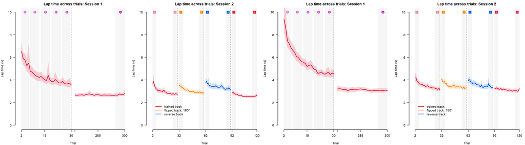

```r
plotSessionsLapTimes()
```

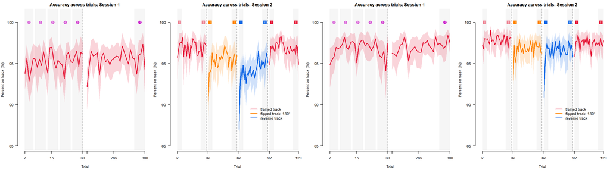

```r
plotSessionsAccuracy()
```

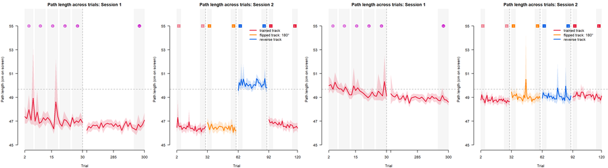

```r
plotSessionsPL()
```

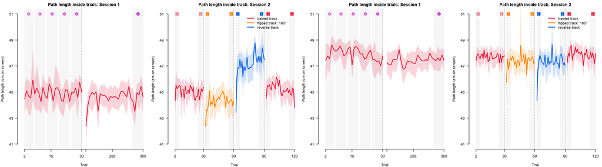

```r
plotSessionsPLInside()
```